# Spatial and Spatio-temporal Patterns of MODIS Fire Detections in Ketapang

- Show All Code
- Hide All Code
- View Source

January-August 2026

Author

JUNCHEN LI

Published

September 23, 2026

Modified

September 27, 2026

# 1 Summary

| Question | Main evidence | Interpretation |
| --- | --- | --- |
| When are records concentrated? | August contains 90.25% of main-subset detections | Full-period summaries largely reflect August; eight months cannot establish a seasonal cycle |
| Is proximity greater than the conditional benchmark? | Association persists at 0/1/3/6-hour lower lags and under two three-day block alignments; final Holm p = 0.0192 across 192 comparisons | The tested observation-preserving models do not explain all proximity; independent-fire interaction remains unresolved |
| Where should records be checked? | Both examples qualify in 7/8 nominal settings, but no centre passes all 32 directional/grid combinations | Exact geographic screening is sensitive to grid support and boundary assignment; candidates need explicit sensitivity flags |

**Reading guide:** Read the first-order maps alongside the conditional pair test, then use the geographic screening to locate candidates. The integrated findings connect this evidence to follow-up actions. Detailed model specifications and complete comparisons are retained in the technical appendix.

The practical contribution is to distinguish locations with many detection records from locations recorded on many separate dates. The two maxima occur in different cells. Their mapped locations and sensitivity checks provide a transparent starting point for imagery review. Pair-based inference supplies complementary evidence of conditional association, while independent-fire identities and observation coverage remain unresolved.

# 2 Introduction and research questions

This analysis examines recorded MODIS active-fire and thermal-anomaly detections in Ketapang Regency, West Kalimantan, during the available January-August 2026 observation period. The analytical unit is a **satellite detection record**, rather than a confirmed independent forest-fire incident. The distinction matters because a fire can persist across overpasses, a pixel can contain more than one fire, and some thermal anomalies can have other explanations.

The analysis addresses the following questions:

1. How do the location and timing of recorded detections vary within the study window?
2. How sensitive are descriptive spatial summaries to confidence filtering, bandwidth and time window?
3. Does evidence of short-range time-location association persist when the null preserves complete daily detection patterns, rather than exchanging individual timestamps?
4. Do areas with many records also have detections on many separate dates, and how could this distinction guide verification?

The third question is a conditional test of **time-location association**. It is different from testing whether independent fires follow a spatially inhomogeneous Poisson process. No result below establishes a causal fire-spread mechanism.

Executive summary · [Project repository](https://github.com/JUNCHENLI2026/ISSS626_GAA)

# 3 Data and study design

## 3.1 R packages and workflow

The preparation below uses the `sf` and `spatstat` workflow introduced in [Chapter 1](https://r4gdsa.netlify.app/chap01.html) and [Chapter 4](https://r4gdsa.netlify.app/chap04.html). Short code chunks expose the import, projection and point-pattern steps. The complete raw-data extraction and computational scripts remain in the appendix.

```r
library(sf)
library(dplyr)
library(ggplot2)
library(spatstat.geom)
library(spatstat.explore)
library(knitr)
```

Packages are installed before rendering rather than during the analysis. The separate `spatstat` modules provide the geometry and exploratory functions used here.

## 3.2 Sources and provenance

| Input | Role and coverage | Important qualification |
| --- | --- | --- |
| NASA FIRMS MODIS Collection 6.1 archive file | Standard-processing observations, January-April 2026 | Source file contains a `type` field |
| NASA FIRMS MODIS Collection 6.1 NRT file | Near-real-time observations, May-August 2026 | The supplied file lacks `type`; missing values remain missing |
| Supplied Indonesian village boundaries | Geographic selection and full Ketapang study window | The download page’s 2024 title does not verify a 2024 boundary reference date |

The supplied NASA FIRMS request and completion emails confirm request **803220**, submitted and made ready for download on **10 September 2026**. The request specifies MODIS C6.1, Indonesia, CSV format and 1 January-31 August 2026. The request identifier matches both retained archive and NRT filenames. The email body records request time `2026-09-10 13:49:56` without a stated timezone, so no timezone conversion is inferred. This documents the acquisition request and availability date; the emails do not independently establish the later local file-transfer time. Personal email details are excluded from this report.

Original files are retained without modification. The administrative XML creation date is 28 May 2023, and the supplied metadata include a 2022 identifier. These dates are recorded rather than relabelled as a confirmed 2024 boundary vintage.

The main input sources are [NASA FIRMS archive downloads](https://firms.modaps.eosdis.nasa.gov/download/) and the [Indonesia Geospatial boundary page](https://www.indonesia-geospasial.com/2023/05/download-shapefile-batas-administrasi.html). NASA’s [MODIS attribute definitions](https://firms.modaps.eosdis.nasa.gov/descriptions/FIRMS_MODIS_Firehotspots.html) identify coordinates as pixel centres and acquisition times as UTC. The reported `scan` and `track` dimensions vary, so a fixed centre-to-centre distance does not establish overlapping pixel footprints.

## 3.3 Spatial and temporal windows

**Provenance status:** NASA request and download-availability dates are supported by the supplied confirmation emails. The boundary’s effective administrative date remains unverified. A webpage title or file modification date cannot resolve that boundary metadata gap.

The geographic window is the union of 262 village polygons whose supplied attributes identify Ketapang in West Kalimantan. Holes and disconnected components are retained. Geometry validity and union consistency are checked, but they do not independently verify administrative completeness. The derived projected area is approximately 29,997 km² and is not presented as an official area statistic.

Coordinates are transformed from WGS 84 to UTM zone 49S (EPSG:32749) and rescaled to kilometres for distance-based analysis. The temporal window is **1 January through 31 August 2026, inclusive, in UTC**. The geographic extraction begins on 14 January; the earliest detection in either confidence-filtered analytical subset is on 16 January. A date with no record does not demonstrate either absence of fire or an available cloud-free observation.

## 3.4 Point-event definition and filtering

One row is one retained MODIS detection. Selection uses the supplied geographic window without inferring physical-fire identities. The main subset uses confidence ≥30, with confidence ≥80 as a nested sensitivity subset. These thresholds assess sensitivity to the confidence filter; they do not convert confidence into a calibrated probability of an independent fire.

The thresholds follow the nominal/high class boundaries in NASA’s [MODIS Collection 6 and 6.1 Fire User Guide](https://www.earthdata.nasa.gov/s3fs-public/2023-09/MODIS_C6_C6.1_Fire_User_Guide_1.0.pdf): low is below 30, nominal is 30 to below 80, and high is 80 or above. The main subset includes nominal and high records; the stricter subset retains high records only. This is a product-confidence sensitivity comparison, not independent event verification.

**Show R code**

```r
inventory <- data.frame(
  Dataset = c("All confidence levels", "Confidence >=30", "Confidence >=80"),
  Records = c(4738L, temporal$overview$records),
  Purpose = c("Geographic extraction and audit", "Main recorded-detection analysis", "Nested confidence sensitivity")
)
knitr::kable(inventory, format.args = list(big.mark = ","))
```

| Dataset | Records | Purpose |
| --- | --- | --- |
| All confidence levels | 4,738 | Geographic extraction and audit |
| Confidence >=30 | 4,472 | Main recorded-detection analysis |
| Confidence >=80 | 1,726 | Nested confidence sensitivity |

The source-row identifiers are unique. Neither retained confidence subset contains repeated numeric coordinates or duplicated latitude/longitude/acquisition-date/acquisition-minute/satellite keys. Exact-key uniqueness does **not** rule out repeated observation of the same physical fire. Records outside the study boundary are excluded from the analytical subset but remain in the original downloads. No temporal thinning, event merging, coordinate jitter, intensity flooring or weight capping is applied.

Original field text, including leading zeros in acquisition times, is preserved. `source_file`, `source_row` and `data_status` retain provenance. Blank NRT `type` values are not replaced by the standard-file category zero. The data therefore do not establish that every NRT record represents vegetation or forest fire.

All 46,449 source rows passed checks for finite numeric coordinates within valid longitude/latitude ranges, parseable dates and dates inside the requested observation period. No coordinate or date imputation was required. Acquisition dates and four-digit HHMM times in the analytical subsets were subsequently parsed and round-trip checked in UTC. Geographic extraction retained 4,738 records and excluded 41,711 from this study’s output; original downloads remain intact. All 262 selected village geometries were valid before and after defensive `st_make_valid()` processing.

## 3.5 Importing the prepared study window and detections

The following steps start from the retained Ketapang boundary and main confidence subset. They reproduce the analytical geometry used in the saved calculations; they do not repeat the national extraction or redefine the events. The CSV import preserves acquisition times as text so that leading zeros remain intact.

```r
ketapang_sf <- st_read(
  file.path(root, "ketapang_boundary.gpkg"),
  layer = "study_window",
  quiet = TRUE
) |>
  st_transform(crs = 32749)

fire_records <- read.csv(
  file.path(root, "ketapang_modis_2026_conf30.csv"),
  colClasses = c(acq_time = "character")
)

fire_sf <- fire_records |>
  st_as_sf(coords = c("longitude", "latitude"), crs = 4326) |>
  st_transform(crs = 32749)
```

### 3.5.1 Converting to `owin` and `ppp`

The observation window retains the supplied polygon’s holes and components. Both the window and coordinates are expressed in kilometres, matching the distance thresholds and bandwidths used below. This adapts the course’s point-pattern preparation to Ketapang’s UTM zone 49S rather than carrying over Singapore’s CRS.

```r
ketapang_owin <- as.owin(ketapang_sf) |>
  rescale(s = 1000, unitname = "km")

fire_xy <- st_coordinates(fire_sf) / 1000
fire_ppp <- ppp(
  x = fire_xy[, "X"],
  y = fire_xy[, "Y"],
  window = ketapang_owin,
  checkdup = TRUE
)

stopifnot(
  npoints(fire_ppp) == 4472L,
  all(inside.owin(fire_xy[, "X"], fire_xy[, "Y"], ketapang_owin)),
  isTRUE(all.equal(
    unname(fire_xy),
    unname(temporal$subsets[["Confidence >=30"]]$xy_km)
  ))
)

data.frame(
  Object = c("Projected boundary", "Observation window", "Point pattern"),
  Class = c(class(ketapang_sf)[1], class(ketapang_owin)[1], class(fire_ppp)[1]),
  Unit = c("metres", "kilometres", "kilometres")
) |>
  kable()
```

| Object | Class | Unit |
| --- | --- | --- |
| Projected boundary | sf | metres |
| Observation window | owin | kilometres |
| Point pattern | ppp | kilometres |

The coordinate equality check confirms that this readable preparation produces the same locations as the saved analysis. No records are jittered, merged or removed to match a tutorial example.

# 4 First-order patterns

First-order analysis describes how recorded intensity varies across location and time. It establishes the context for pair-based analysis: a dense area or a high-count month can generate many close pairs without demonstrating an additional interaction mechanism.

## 4.1 Geographic distribution

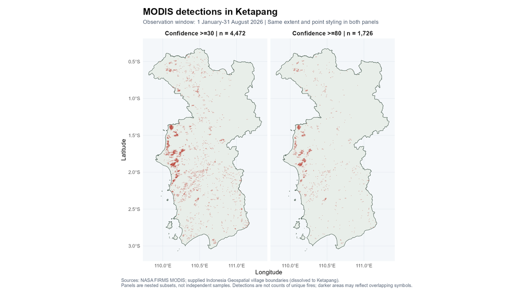

Figure 1: Retained detection locations in the supplied study window.

The location maps describe an uneven distribution of retained records, with visible concentration toward parts of western Ketapang. The high-confidence subset contains fewer points and is nested within the main subset, so the two panels are not independent replications. Concentrated detections can reflect fire activity, persistent observations, land conditions or detection opportunity. This map alone does not identify their relative contributions or establish statistically significant interaction.

## 4.2 Temporal concentration

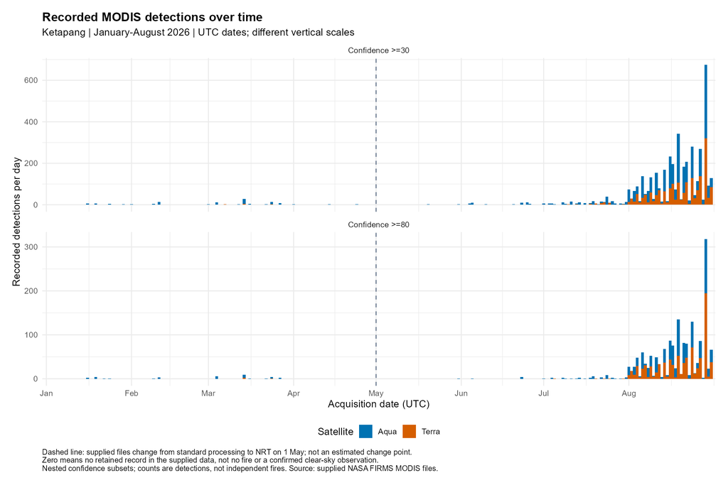

Figure 2: Daily retained records by satellite and UTC date.

August accounts for 90.25% of main-subset records and 95.19% of high-confidence records. Both subsets reach their highest daily recorded count on 29 August. This concentration means that full-period summaries largely describe late-period detections. The dashed line marks the supplied standard/NRT transition, not a fitted change point. Without information on cloud cover, overpass opportunity and data completeness, recorded counts cannot be interpreted as exposure-adjusted fire incidence.

## 4.3 Spatial intensity and bandwidth

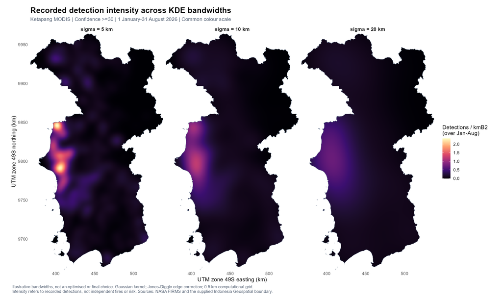

Figure 3: Gaussian kernel intensity at illustrative bandwidths.

The same records appear more locally concentrated at 5 km and more broadly smoothed at 20 km. The shared colour scale shows intensity in recorded detections per square kilometre over the full period. These are descriptive estimates, not probabilities, daily risks or counts of independent fires. Bandwidth changes the spatial detail that the estimate retains and therefore requires a scientific justification beyond the appearance of the map.

### 4.3.1 Estimation choices

All kernel calculations use the complete study window and Jones-Diggle edge correction. A 0.5 km computational grid controls raster approximation; it is not satellite resolution. Raw raster intensities are retained, and negligible negative FFT round-off is handled only for nonnegative plotting or unit-integral normalization. The [spatstat intensity documentation](https://search.r-project.org/CRAN/refmans/spatstat.explore/html/density.ppp.html) distinguishes intensity per unit area from probability density.

Earlier bandwidth checks compared likelihood cross-validation and the Cronie-van Lieshout criterion. Their implementations use different point-intensity and boundary conventions. Small likelihood-CV candidates produced severe reciprocal-weight concentration under the later leave-one-out estimator. The resulting numerical candidates are documented but are not automatically adopted as a final interaction model.

## 4.4 Time-window sensitivity

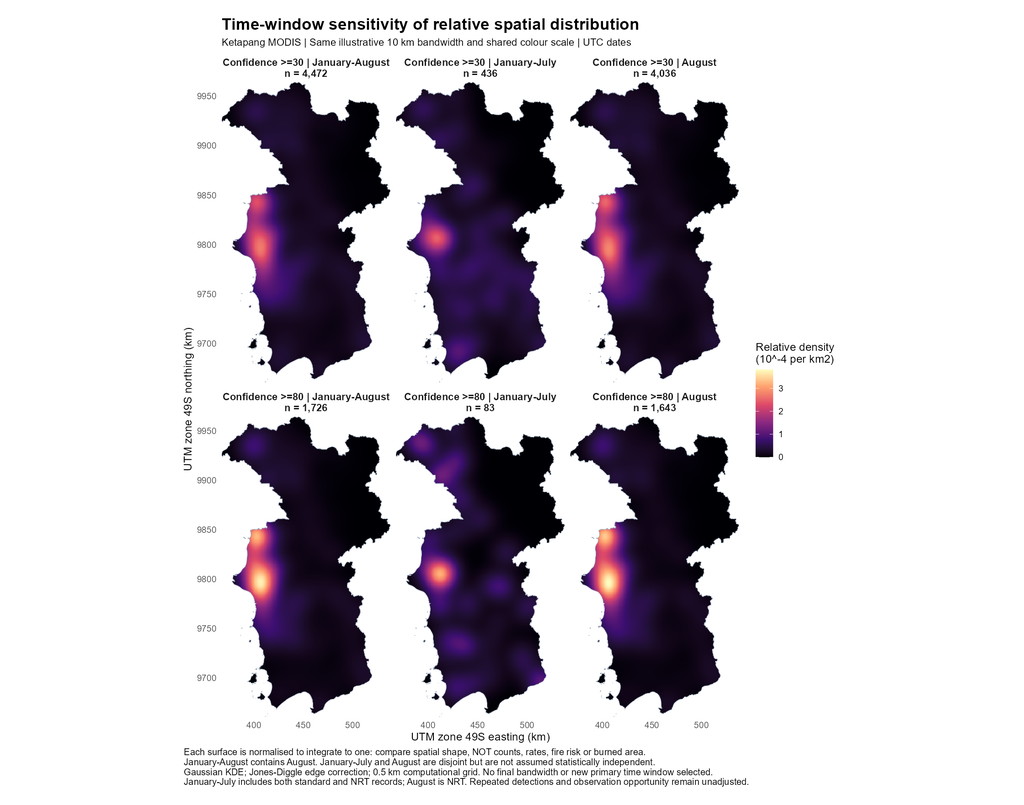

Figure 4: Relative spatial distributions with the same 10 km bandwidth.

Each panel integrates to one, permitting a comparison of spatial shape while removing total-count differences. Full-period and August maps have high overlap, partly because August dominates the full dataset. January-July and August are more distinct at this smoothing scale. The earlier window has only 436 main-subset and 83 high-confidence records, so its apparent detail has unequal evidential support. Normalized map overlap is descriptive and is not a test of temporal stability.

# 5 Second-order spatial diagnostics

Ordinary and intensity-reweighted L summaries are evaluated on a common provisional 0–10 km distance grid with border correction. The reweighted estimator uses period-specific Gaussian leave-one-out intensity at the observation points, with illustrative bandwidths of 10 and 20 km, `renormalise = TRUE` and `normpower = 2`. Full-period estimates are reused after provenance checks.

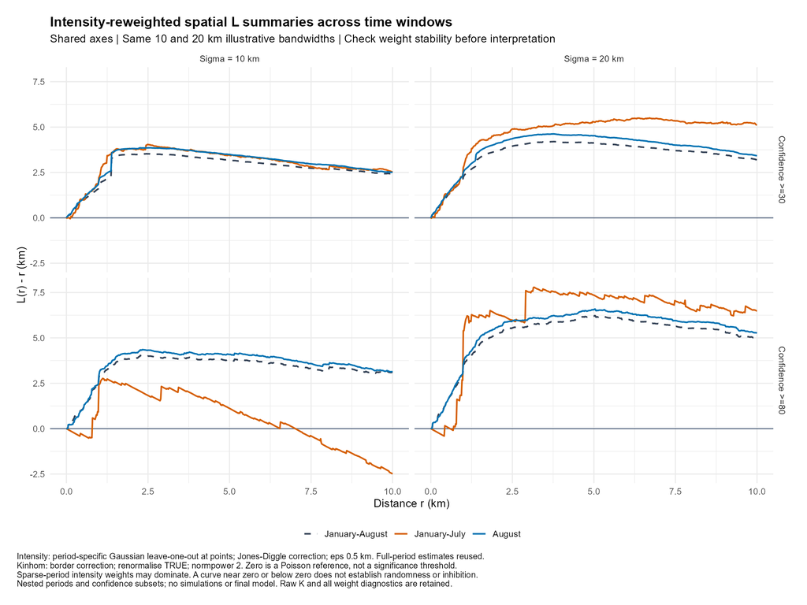

Figure 5: Sensitivity of intensity-reweighted L summaries to period and bandwidth.

The January-July high-confidence curve changes substantially between the two bandwidths. That subset contains only 83 records, and its maximum reciprocal-intensity share is 17.58% at 10 km versus 3.85% at 20 km. Only 55 centres remain eligible for border correction at a distance of 10 km. These diagnostics caution against interpreting a negative segment as evidence of inhibition. No simulation envelope has been fitted to these L curves.

The [inhomogeneous K documentation](https://search.r-project.org/CRAN/refmans/spatstat.explore/html/Kinhom.html) gives the Poisson theoretical reference. A reference line is not a significance threshold. Fitting intensity and then calculating a summary from the same observations makes estimation choices consequential. These curves motivate further investigation but do not themselves provide a formal spatial clustering conclusion.

# 6 Conditional test of space-time association

## 6.1 Research question and inferential scope

Do recorded detections occur close together in space and time more often than expected after preserving the observed spatial pattern and specified temporal structure? This is the report’s formal **second-order spatio-temporal analysis**. It counts pairs of records, whereas the preceding intensity maps describe the distribution of individual records. The spatial L curves remain supporting diagnostics.

The primary statistic counts unordered record pairs at most **1 km apart and 1–24 hours apart**. The 1 km distance describes pixel-centre proximity. It cannot identify independent fires, particularly because the supplied scan dimensions reach 4.82 km. The lower lag removes near-simultaneous pairs without proving independence.

**Null:** Time labels, complete days or complete three-day patterns are exchangeable within their declared temporal strata. **Alternative:** The observed number of close pairs exceeds the conditional benchmark. Observed locations and the study window remain fixed, so the test concerns the retained in-window records; it cannot recover pairs involving unobserved events outside the boundary.

## 6.2 Why compare conditional models?

| Model | What remains intact | Remaining assumption |
| --- | --- | --- |
| Individual timestamps | Locations and stratum-specific time distributions, with satellite, day/night and processing status retained in the grouping | Exchanging individual records can disrupt shared overpasses and continuing fires |
| Complete UTC days | Every location, clock time and satellite label within each date | Days are exchangeable within the declared month or week blocks; midnight can split sequences |
| Complete three-day blocks | Internal order and observations within consecutive three-day patterns | Blocks are exchangeable within months; longer sequences and block joins remain unresolved |

The complete-day design addresses dependence that individual permutations break. Three-day blocks then check whether the conclusion persists when short sequences remain intact. Neither extension establishes equal cloud cover or valid-observation opportunity. Both alignments of three-day blocks are reported, with incomplete fragments fixed.

Each case uses **9,999 permutations**, a fixed seed and a one-sided plus-one p-value, including ties. Holm correction covers the full **192-comparison exploratory family**. Sensitivity checks vary confidence, period, distance, upper lag, lower lag and block alignment. Nested subsets and overlapping periods are sensitivity checks, not independent replications. Exact settings, implementations, Monte Carlo intervals and historical adjustments appear in the technical appendix.

## 6.3 Results: association persists under stricter conditioning

**Show R code**

```r
current_models <- audit$summary |>
  filter(
    subset == "Confidence >=30",
    period == "January-August",
    lower_hours == 1
  )

comparison <- current_models |>
  select(
    `Conditional model` = scheme,
    `All pairs` = observed,
    `Fixed pairs` = guaranteed_fixed,
    `Variable observed` = variable_observed,
    `Variable null mean` = variable_null_mean,
    `Holm p` = p_holm_192
  )
knitr::kable(comparison, digits = c(0, 0, 0, 0, 2, 4), row.names = FALSE)
```

| Conditional model | All pairs | Fixed pairs | Variable observed | Variable null mean | Holm p |
| --- | --- | --- | --- | --- | --- |
| Daily within week | 3597 | 1946 | 1651 | 993.48 | 0.0192 |
| Three-day blocks offset 0 | 3597 | 3037 | 560 | 124.73 | 0.0192 |
| Three-day blocks offset 1 | 3597 | 3129 | 468 | 138.20 | 0.0192 |

**Show R code**

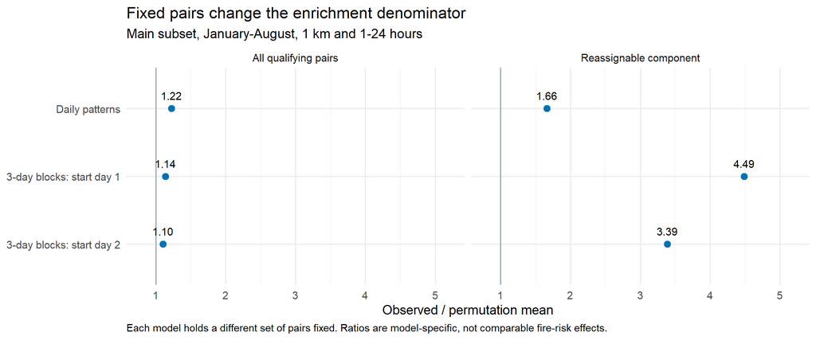

Figure 6: Pair enrichment depends on the temporal structure preserved by the null.

```r
plot_pair_denominators(audit)
```

**Interpretation.** All three models retain the same 3,597 observed pairs, but the daily model fixes 1,946 pairs and the three-day models fix 3,037 or 3,129. The daily model’s remaining 1,651 pairs exceed its simulated mean of 993.48, giving a variable-component ratio of 1.66. All displayed tests have final Holm p = 0.0192. This supports conditional time-location association under the tested models. Because each model leaves a different component free to vary, its ratio answers a different question; the ratios cannot be compared as a common fire-risk effect.

## 6.4 What survives the sensitivity checks?

All 48 final-audit comparisons remain significant after adjustment across the complete 192-test family. Changing the lower lag from zero to one hour removes 1,022 pairs in the main dataset, all from the fixed component. The three-day designs leave only 560 or 468 observed pairs free to vary. Their significance therefore concerns the remaining conditional arrangement, rather than every pair.

The strongest supported conclusion is that **the recorded arrangement is inconsistent with the tested exchangeability models**. Persistent fire observations, changing coverage and dependencies across block boundaries remain possible explanations. These results do not establish causal spread, independent-fire interaction or local hotspot significance. The next section localises descriptive candidates for verification rather than assigning the global p-value to individual places.

# 7 Spatial recurrence and geographic interpretation

## 7.1 Value-added question: volume or recurrence?

High pixel-record volume and repeated recording across many dates can imply different verification priorities. This extension asks whether the same areas rank highly on both measures. It adds an explicit space-by-date summary to the pair analysis without assuming that neighbouring observations constitute independent fires.

Each record is assigned to a square grid in UTM zone 49S. The main grid uses 5 km cells with origin (0, 0); the analysis repeats at 10 km and with a half-cell shift in both axes. Within each occupied cell, it counts records, distinct UTC dates, distinct months and the fraction of records on the busiest date. These are descriptive counts. Neither calendar days nor cell area supplies a valid-observation denominator. Partial border cells and changes of grid origin affect comparability.

## 7.2 Volume and recurrence

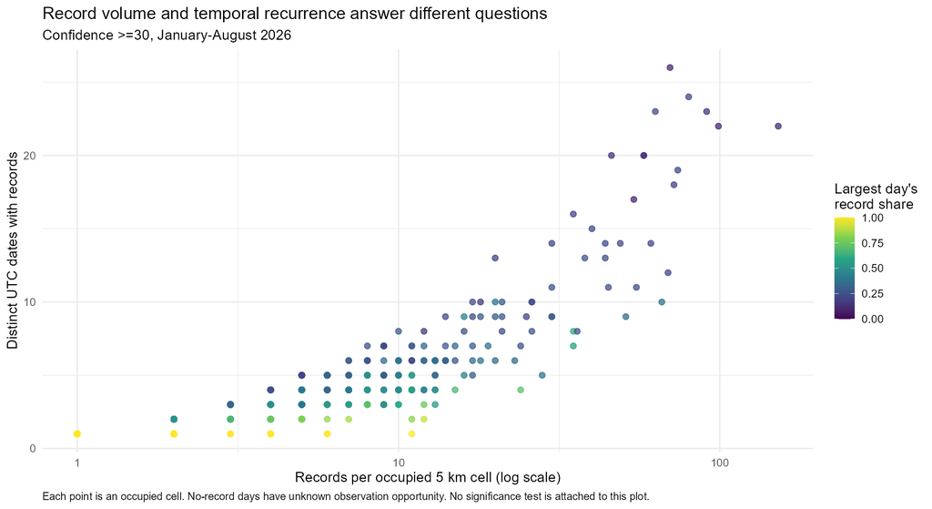

Figure 7: Record volume compared with the number of separate recorded dates.

The main 5 km grid has 621 occupied cells, including 225 with records on only one date. Record volume and recorded-date count are strongly associated descriptively (Spearman correlation 0.916), yet their maxima differ. The busiest cell contains 152 records on 22 dates; the cell with the most recorded dates contains 70 records on 26 dates. Thus ranking solely by record totals can miss areas that repeatedly appear across dates. The correlation is descriptive and has no attached independence-based p-value.

**Show R code**

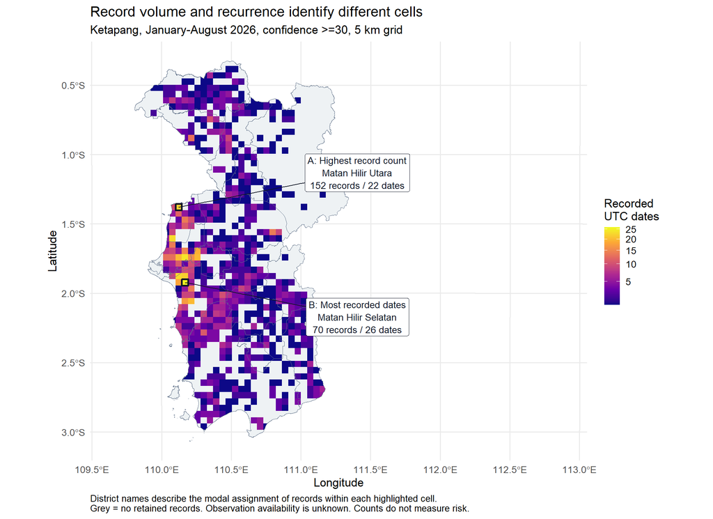

Figure 8: Geographic context of the highest-volume and highest-recurrence cells.

```r
source("recurrence_map.R")
recurrence_location_map(recurrence)
```

Cell A is E400_N9845 and cell B is E405_N9785. The map outlines the full grid cells, while the subdistrict names describe their modal record assignments rather than exclusive administrative ownership.

Repeated recording is concentrated in parts of western Ketapang. The leading cell by recorded dates is associated with Matan Hilir Selatan through its modal point-level subdistrict assignment. Its 26 recorded dates fall to 13 under the stricter confidence filter. This reduction shows that the recurrence count depends on filtering. Grey areas have no retained records, but may lack valid observations. Cells indicate where to inspect sequences; they do not define significant hotspots or identify ignition sites.

**Show R code**

```r
top <- recurrence$top[1:5, c("cell_label", "district", "records", "recorded_dates", "high_confidence_dates")]
names(top) <- c("5 km cell", "Modal subdistrict of records", "Records >=30", "Dates >=30", "Dates >=80")
knitr::kable(top, row.names = FALSE)
```

| 5 km cell | Modal subdistrict of records | Records >=30 | Dates >=30 | Dates >=80 |
| --- | --- | --- | --- | --- |
| E405_N9785 | Matan Hilir Selatan | 70 | 26 | 13 |
| E405_N9805 | Muara Pawan | 80 | 24 | 15 |
| E400_N9790 | Matan Hilir Selatan | 91 | 23 | 14 |
| E395_N9820 | Matan Hilir Utara | 63 | 23 | 10 |
| E400_N9845 | Matan Hilir Utara | 152 | 22 | 17 |

Cell identifiers encode the lower-left easting/northing in projected kilometres, for example E405_N9785. Subdistrict labels describe the most frequent point assignment within each cell, not the exclusive administrative ownership of the entire square. All records map to exactly one of the 20 subdistrict unions derived from the supplied village attributes. The geometry and names inherit the source’s uncertain effective vintage.

## 7.3 Administrative context: counts and recurrence tell different stories

**Show R code**

```r
context <- recurrence$administration
context <- context[context$subset == "Confidence >=30" & context$WADMKC %in% c("Matan Hilir Selatan", "Matan Hilir Utara", "Kendawangan"), ]
context <- context[match(c("Matan Hilir Selatan", "Matan Hilir Utara", "Kendawangan"), context$WADMKC), ]
context <- context[, c("WADMKC", "area_km2", "records", "recorded_dates")]
names(context) <- c("Subdistrict", "Derived area km²", "Detection records", "Recorded dates")
knitr::kable(context, digits = c(0, 1, 0, 0), row.names = FALSE)
```

| Subdistrict | Derived area km² | Detection records | Recorded dates |
| --- | --- | --- | --- |
| Matan Hilir Selatan | 1503.3 | 957 | 45 |
| Matan Hilir Utara | 714.8 | 578 | 40 |
| Kendawangan | 5657.8 | 684 | 58 |

Matan Hilir Selatan has the largest record total among these examples, while Kendawangan has more recorded dates despite fewer records. Their substantially different areas prevent a simple count-based risk ranking. This administrative comparison complements the cell-level A/B contrast: concentrated record volume and repeated appearance over time answer different monitoring questions. The table uses the supplied boundary attributes, whose effective administrative vintage remains uncertain. Neither area nor calendar dates measure valid satellite observation opportunity.

## 7.4 Scale sensitivity and administrative context

**Show R code**

```r
grid_table <- recurrence$summary[, c("subset", "cell_km", "shift_fraction", "occupied_cells", "cells_one_date", "max_recorded_dates", "spearman_records_dates")]
names(grid_table) <- c("Subset", "Cell width km", "Origin shift / width", "Occupied cells", "One-date cells", "Maximum dates", "Spearman correlation")
knitr::kable(grid_table, digits = c(0, 0, 1, 0, 0, 0, 3), row.names = FALSE)
```

| Subset | Cell width km | Origin shift / width | Occupied cells | One-date cells | Maximum dates | Spearman correlation |
| --- | --- | --- | --- | --- | --- | --- |
| Confidence >=30 | 5 | 0.0 | 621 | 225 | 26 | 0.916 |
| Confidence >=30 | 10 | 0.0 | 246 | 40 | 32 | 0.956 |
| Confidence >=30 | 5 | 0.5 | 625 | 230 | 29 | 0.905 |
| Confidence >=30 | 10 | 0.5 | 250 | 33 | 37 | 0.947 |
| Confidence >=80 | 5 | 0.0 | 344 | 197 | 17 | 0.848 |
| Confidence >=80 | 10 | 0.0 | 181 | 65 | 24 | 0.927 |
| Confidence >=80 | 5 | 0.5 | 338 | 183 | 16 | 0.848 |
| Confidence >=80 | 10 | 0.5 | 184 | 73 | 22 | 0.910 |

The main-subset maximum changes from 26 dates in the primary 5 km grid to 29 after a half-cell shift, and to 32 or 37 in the 10 km grids. Coarser cells pool more locations, so these increases are partly consequences of spatial support. The extension therefore reports sensitivity rather than claiming grid-independent hotspots. The purpose is to distinguish recorded volume from recurrence and provide auditable candidate locations for verification.

## 7.5 Geographic stability on a common reference support

Raw maxima cannot establish stability because changing grid size changes the unit being ranked. The new audit therefore holds **621 primary occupied-cell centres** fixed and identifies the containing cell in each of the eight confidence/grid settings. Within each setting, cells are ranked by recorded-date count. A centre qualifies when its containing cell is in the highest 10%, using the maximum rank for ties so equally ranked cells are not arbitrarily split. A centre without a retained containing cell does not qualify. The 10% threshold was fixed before examining this audit, and is a descriptive screening rule rather than an estimated optimum.

Cell assignment uses half-open intervals: include the lower easting/northing edge and exclude the upper edge. Primary centres fall on vertices of the half-shifted 5 km grid, so this convention assigns them to the north-east cell. A supplementary assignment audit evaluates all four combinations of +/-1 metre easting and northing around each centre under all eight settings. This tests boundary conventions, not MODIS geolocation accuracy. Independent rectangle-inequality checks reproduce the floor-based assignment counts.

**Show R code**

```r
anchor_table <- audit$anchors[, c("reference_cell", "setting", "dates", "upper_rank_percent", "top_decile")]
anchor_table$reference_cell <- ifelse(anchor_table$reference_cell == "80_1969", "A: E400_N9845", "B: E405_N9785")
names(anchor_table) <- c("Reference location", "Setting", "Recorded dates", "Upper rank %", "Top 10%")
knitr::kable(anchor_table, digits = 2, row.names = FALSE)
```

| Reference location | Setting | Recorded dates | Upper rank % | Top 10% |
| --- | --- | --- | --- | --- |
| A: E400_N9845 | Confidence >=30 \| 5 \| 0 | 22 | 0.97 | TRUE |
| B: E405_N9785 | Confidence >=30 \| 5 \| 0 | 26 | 0.16 | TRUE |
| A: E400_N9845 | Confidence >=30 \| 10 \| 0 | 25 | 2.85 | TRUE |
| B: E405_N9785 | Confidence >=30 \| 10 \| 0 | 26 | 2.03 | TRUE |
| A: E400_N9845 | Confidence >=30 \| 5 \| 0.5 | 8 | 8.48 | TRUE |
| B: E405_N9785 | Confidence >=30 \| 5 \| 0.5 | 14 | 3.04 | TRUE |
| A: E400_N9845 | Confidence >=30 \| 10 \| 0.5 | 22 | 3.20 | TRUE |
| B: E405_N9785 | Confidence >=30 \| 10 \| 0.5 | 30 | 1.20 | TRUE |
| A: E400_N9845 | Confidence >=80 \| 5 \| 0 | 17 | 0.29 | TRUE |
| B: E405_N9785 | Confidence >=80 \| 5 \| 0 | 13 | 2.03 | TRUE |
| A: E400_N9845 | Confidence >=80 \| 10 \| 0 | 21 | 1.66 | TRUE |
| B: E405_N9785 | Confidence >=80 \| 10 \| 0 | 18 | 2.76 | TRUE |
| A: E400_N9845 | Confidence >=80 \| 5 \| 0.5 | 3 | 24.26 | FALSE |
| B: E405_N9785 | Confidence >=80 \| 5 \| 0.5 | 4 | 13.31 | FALSE |
| A: E400_N9845 | Confidence >=80 \| 10 \| 0.5 | 17 | 2.17 | TRUE |
| B: E405_N9785 | Confidence >=80 \| 10 \| 0.5 | 21 | 1.09 | TRUE |

Both A and B qualify in **7 of 8** settings. Both fail under the shifted 5 km high-confidence setting: A falls to an upper rank of 24.26% and B to 13.31%. Their geographic neighbourhoods remain useful candidates, but the exact primary-cell ranking is not invariant. Across all reference centres, 11 qualify in every setting and 479 qualify in none. These counts refer to the selected reference support, not the proportion of Ketapang’s land area or independent fire incidents.

The directional audit materially qualifies that result: **no reference centre qualifies in all 32 direction-by-setting combinations**. A and B each qualify in seven or eight settings depending on direction. Thus the 11 nominal all-setting centres must not be called assignment-invariant hotspots. Their list remains useful for transparent checking, but every candidate requires a spatial-support sensitivity flag. An areal-overlap analysis would answer a different question about zones and has not been performed.

The following list identifies the 11 nominal all-setting candidates. Coordinates are primary-cell centres in UTM zone 49S, in kilometres. The district is the modal assignment of the primary cell’s records, not verified ownership of the centre. The list is for imagery review, not field navigation or dispatch, and is sensitive to the directional check above.

**Show R code**

```r
stable_locations <- subset(audit$support, settings_in_top_decile == 8)
stable_locations$district_context <- grid_main$district[match(stable_locations$cell, grid_main$cell)]
stable_locations <- stable_locations[, c("cell", "x_km", "y_km", "district_context", "settings_in_top_decile")]
names(stable_locations) <- c("Reference cell ID", "Easting km", "Northing km", "District context", "Qualifying settings")
knitr::kable(stable_locations, digits = 1, row.names = FALSE)
```

| Reference cell ID | Easting km | Northing km | District context | Qualifying settings |
| --- | --- | --- | --- | --- |
| 80_1957 | 402.5 | 9787.5 | Matan Hilir Selatan | 8 |
| 80_1958 | 402.5 | 9792.5 | Matan Hilir Selatan | 8 |
| 80_1960 | 402.5 | 9802.5 | Muara Pawan | 8 |
| 80_1961 | 402.5 | 9807.5 | Muara Pawan | 8 |
| 81_1954 | 407.5 | 9772.5 | Matan Hilir Selatan | 8 |
| 81_1955 | 407.5 | 9777.5 | Matan Hilir Selatan | 8 |
| 81_1958 | 407.5 | 9792.5 | Matan Hilir Selatan | 8 |
| 81_1959 | 407.5 | 9797.5 | Matan Hilir Selatan | 8 |
| 81_1961 | 407.5 | 9807.5 | Muara Pawan | 8 |
| 82_1961 | 412.5 | 9807.5 | Sungai Melayu Rayak | 8 |
| 83_1961 | 417.5 | 9807.5 | Sungai Melayu Rayak | 8 |

**Show R code**

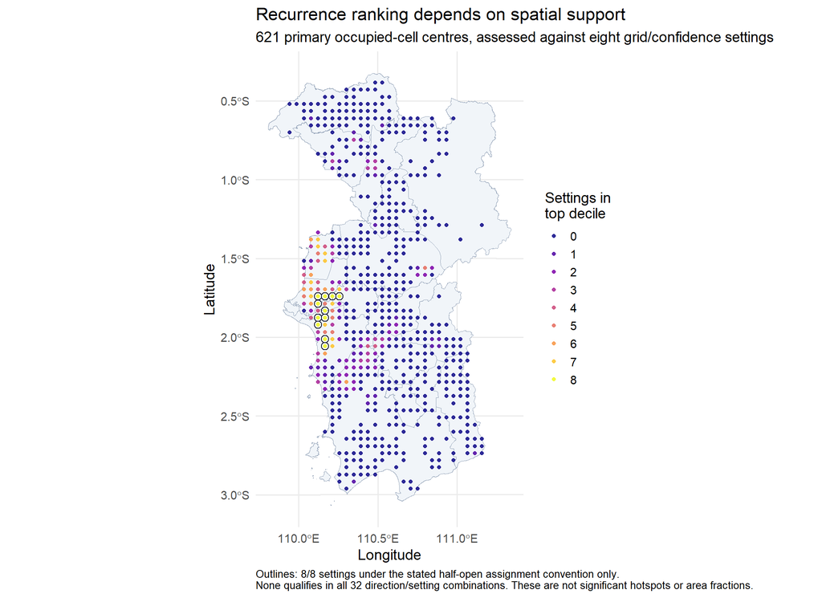

Figure 9: Consistency of recurrence screening across eight confidence/grid settings.

```r
plot_grid_stability(audit, recurrence)
```

The outlined centres meet the nominal screen under both confidence filters, cell sizes and origins. None passes all directional checks, so the outline indicates conditional screening agreement rather than a stable zone. Settings share records and provide no independent confirmation. Centres of clipped border cells may lie outside the boundary. Agreement depends on the 10% rule and assignment convention, with no local significance or risk interpretation.

# 8 Integrated findings, uncertainty and implications

## 8.1 Findings supported by these calculations

| Evidence | What it adds | Appropriate follow-up |
| --- | --- | --- |
| Daily counts and KDE | Timing and geographic concentration of recorded detections | Inspect August imagery and western recording concentrations |
| Conditional pair tests | Excess short-lag proximity relative to specified reassignment models | Compare candidate sequences with overpass and incident records |
| Grid recurrence | Separates many records from repeated appearance on different dates | Compare highlighted cells A and B before assigning operational priority |

First-order concentration supplies the context for the pair tests, rather than independent confirmation of their significance. The recurrence analysis localises descriptive candidates, but the global conditional p-value does not assign significance to either highlighted cell.

The observed detections are temporally concentrated in August and are spatially uneven. Spatial-shape and L summaries depend on the time window and smoothing choice. The conditional permutation analysis finds more short-distance, short-time detection pairs than expected under the individual-record and whole-day designs, after adjustment across the full threshold family.

The final significance conclusion is narrow: **the recorded time-location arrangement is inconsistent with the specified individual-record, whole-day and three-day-block exchangeability models**, with Holm-adjusted p = 0.0192 across the final 192-test family. Lower-lag and block-alignment checks do not change this decision. The fixed and variable pair components differ between models, so their ratios cannot be compared as a common ecological effect. The analysis does not isolate ecological interaction from persistent detections or observation-process structure, and does not validate the L curves as formal tests.

The recurrence extension supplies a complementary geographic interpretation. High-volume and frequently recorded areas overlap broadly, but their maxima differ and their summaries depend on confidence and spatial support. Together, the analyses support targeted verification of observed sequences rather than ranking future fire probabilities. This directly answers the four research questions: the distribution is uneven, August dominates, conditional time-location association persists under the added models, and record volume alone does not fully describe geographic recurrence.

## 8.2 Important limits

- A row represents a detected thermal-anomaly pixel, not a verified independent forest-fire incident. NRT records lack the supplied standard-file `type` classification.
- Individual timestamp permutations can disrupt dependence among records belonging to the same overpass or continuing fire. Whole-day permutations preserve within-date dependence but still assume date exchangeability and can split sequences at UTC midnight. A one-hour cutoff does not identify independent incidents.
- No cloud-free observation, coverage or exposure denominator is available. The standard/NRT transition and confidence filtering affect comparability.
- The supplied administrative boundary has uncertain effective vintage and has not been independently checked against an authoritative current regency boundary.
- Thresholds, windows and the successive block designs follow exploratory inspection. Holm correction covers the final 192 tests but cannot reverse data-driven choices or repair a misspecified null. Three-day blocks preserve local order only within their boundaries. Grid agreement is descriptive and depends on the 10% screen and reference support.
- P-values address the stated models. They do not quantify fire severity, burned area, causality or operational benefit.

## 8.3 Public-safety planning and management

The results support a verification workflow rather than immediate resource allocation. A regional monitoring team could first examine the large late-August recording episodes, including 29 August, against source imagery and confirmed incident reports. Each candidate review should record acquisition date, satellite, location, image availability and whether independent incident evidence corroborates the detection sequence. An unavailable or cloudy image should remain inconclusive rather than count as evidence of no fire.

The recurrence screen provides a second entry point. Review the 11 reference centres meeting the nominal top-decile criterion in all eight settings, alongside illustrative cells A and B. Every candidate should carry a spatial-support flag: none passes all directional checks, and A and B vary between seven and eight qualifying settings. Compare corroboration and inconclusive-image rates between these descriptive groups before using them operationally. No such external validation has yet been performed, so the candidates are not verified incidents, significant local hotspots or deployment priorities.

Before converting either pattern into planning recommendations, agencies would need observation-coverage information, suitable-date land cover, incident identities, assets at risk and operational capacity. The present analysis supplies none of those denominators or causal links. No recommendation to build a station, relocate crews or attribute fires to a particular land use follows directly from the results.

The practical contribution is an auditable way to separate a large number of detected pixels from repeated appearance over time. This can help organize follow-up checks while keeping uncertainty visible. The eight-month retrospective sample cannot establish future fire probability or the effectiveness of any intervention.

# 9 Reproducibility

The project preserves the source downloads, geographic subset, provenance columns, intermediate diagnostics, scripts and calculation objects. Large national boundary files remain local rather than being embedded in Git history. The derived Ketapang boundary and input detection subsets are sufficient to rerun the analyses after extraction; independently reproducing the extraction also requires the original national boundary and NASA files described in `data/Ketapang/README.md`.

The principal computational stages and their purposes are:

| Stage | Functions or operations | Purpose |
| --- | --- | --- |
| Geographic extraction | `sf::st_read`, `st_zm`, `st_transform`, `st_make_valid`, `st_union`, `st_intersects` | Build the unsimplified study window and retain in-window detections |
| Confidence subsets | Numeric `confidence >= 30` and `confidence >= 80` filters | Compare a main subset with a nested stricter subset while preserving provenance |
| Point-pattern objects | `spatstat.geom::as.owin`, `ppp` | Use a polygon observation window and projected kilometre coordinates |
| First-order intensity | `spatstat.explore::density.ppp` | Describe spatially varying recorded-detection intensity at stated bandwidths |
| Spatial second-order diagnostics | `Kest`, `Kinhom`; transform to `sqrt(K/pi) - r` | Examine descriptive pair structure and sensitivity to estimated intensity |
| Conditional time-label test | Projected pair distances, `sample`, custom lag counts, `stats::p.adjust` | Compare close-pair counts with restricted time permutations and adjust the declared test family |

The data README lists the scripts, dependencies, output files and checks for each stage. The report’s inference uses the last stage; the spatial K/L diagnostics are not substituted for a fitted simulation test.

The report reads verified calculation objects. Rendering alone does not rerun the 279,972 original, whole-day and final-audit permutations. For a complete rebuild from the supplied raw downloads, use the exercise-root `reproduce.R` entry point with an **unused output directory**:

```powershell
Rscript reproduce.R "E:/JUNCHENLI/ISSS626_GAA/Take-Home_Ex/Take-Home_Ex01" "C:/path/to/new-build" "E:/quarto/bin/quarto.exe"
```

Replace paths with the local exercise directory, a new writable destination and the installed Quarto executable. The raw NASA files and national boundary must be present in their documented locations. Required R packages include sf, dplyr, ggplot2, spatstat.geom, spatstat.explore, knitr and rmarkdown. The runner checks dependencies and refuses to reuse an existing destination. It rebuilds the extraction, reconciles confidence-subset rows with the retained inputs, runs all diagnostic and inferential stages, executes independent verification, and renders the report and summary. Step logs and session information are written under the new build’s `logs/` directory. It does not delete data.

For a faster render from existing results, render the two QMD documents without running the rebuild script. The distinction between regenerating analysis and rendering saved analysis is explicit. Detailed dependencies and source-data restrictions remain documented in the data README.

The labelled recurrence map is generated during rendering by `recurrence_map.R`, using the saved grid and district geometries. Assertions verify the two displayed record/date counts before plotting. It changes presentation without altering the statistical results. The complete rebuild copies this helper alongside both documents. NASA acquisition-request metadata are supported by the supplied emails; boundary vintage remains an outstanding provenance check. Successful rendering does not resolve it.

Source and previous-result hashes were checked before and after computation. An independent verification enumerated all spatial pairs from projected coordinates, reconciled observed counts, checked three stored permutations per case, recomputed all p-values and independently reconstructed the Holm step-down adjustment. Figures were inspected after rendering.

# 10 Technical appendix

The appendix retains complete specifications and earlier comparison families for reproducibility. The main findings use the final 192-test adjustment throughout.

## 10.1 Detailed conditional-test specifications and sensitivity results

Two complementary randomization designs are reported. The original design exchanges individual timestamps within strata. The added design moves each complete observed UTC-day pattern to another eligible date while preserving every location, satellite label and time of day within that pattern. Both are explicit conditional models with different assumptions; neither is asserted to be a verified model of independent fire incidents.

### 10.1.1 Rationale and hypotheses

The spatial diagnostics show why a homogeneous random-location benchmark would ignore important variation in the observed pattern. The following test instead holds all observed locations fixed and randomizes time labels within declared strata. This conditions on the observed spatial pattern rather than estimating a new spatial intensity surface for inference.

**Null hypothesis:** Within each declared stratum, acquisition timestamps are exchangeable among the observed record locations. Conditional on those margins, the assignment of times to locations contains no additional association.

**Alternative:** There are more nearby, temporally close detection pairs than expected under this conditional reassignment model.

This is a restricted-permutation adaptation of a [Knox-type close-pair test](https://search.r-project.org/CRAN/refmans/surveillance/html/knox.html). The custom statistic counts unordered pairs satisfying both `distance <= d` and `1 hour <= elapsed time <= h`. The lower bound excludes simultaneous and near-simultaneous records from the statistic, but does not prove separate physical events or independent satellite passes. It differs explicitly from an unmodified upper-threshold-only Knox statistic.

### 10.1.2 Parameters and assumptions

| Decision | Specification | Reason and limitation |
| --- | --- | --- |
| Spatial thresholds | 0.5, 1 and 2 km | Retains the previously inspected sensitivity range; centres are not fire footprints |
| Temporal thresholds | Upper bounds of 6, 24 and 72 hours; lower bound 1 hour | Assesses short-lag proximity without same-minute pairs |
| Main reassignment strata | Month × satellite × day/night × processing status | Preserves these spatial/time margins |
| More restrictive sensitivity | Adds within-month blocks of days 1–7, 8–14, 15–21, 22–28 and 29–end | Conditions on finer temporal changes; final blocks are shorter |
| Datasets | Confidence ≥30 and ≥80; January-August and August | Four nested/overlapping datasets, not independent replications |
| Randomizations | 9,999 per dataset/stratification combination | Fixed before inspecting randomization results |
| Tail and threshold | One-sided excess-pair test; alpha = 0.05 | Tests enrichment, not inhibition |
| Multiple comparisons | Original 72, whole-day 72 and final robustness 48 comparisons in a 192-test Holm family | Covers the declared family, not unrecorded prior exploration |

The central assumption is **record-level timestamp exchangeability within strata**. Shared overpasses, persistent fires, spatially varying cloud cover and changing observation opportunity can undermine a physical-fire interpretation. Restricting permutations controls selected margins but does not validate this assumption. Conditioning on fixed locations preserves the observed boundary geometry and spatial inhomogeneity. It does not produce an edge-unbiased space-time K estimate or an unconditional fire-risk model.

The January-August comparison is displayed at 1 km and 1–24 hours for continuity with the earlier data audit. The thresholds and August window were considered after inspecting the data, so the results remain exploratory rather than prospectively confirmatory.

### 10.1.3 Computation and reproducibility

Within each stratum, timestamps are sampled without replacement. The same randomized timestamps are used for all nine threshold combinations in that run. Singleton groups and groups with only one distinct timestamp remain unchanged. Seeds are fixed from 2026091701 through 2026091708, with the R random-number, normal and sampling algorithms recorded in the source script.

The Monte Carlo p-value is `(1 + exceedances) / (9999 + 1)`, where ties count as exceedances. The smallest possible reported value is 0.0001, never zero. This follows [Phipson and Smyth](https://arxiv.org/abs/1603.05766). The [Holm procedure](https://stat.ethz.ch/R-manual/R-devel/library/stats/html/p.adjust.html) now covers all 192 comparisons. Main-text tables use this final family. The appendix retains historical 72- and 144-test adjustments for traceability.

**Show R code**

```r
tab <- main[, c("scheme", "observed_pairs", "permutation_mean", "observed_to_null_mean", "p_mc", "p_current")]
names(tab) <- c("Time strata", "Observed pairs", "Null mean", "Observed / null mean", "Monte Carlo p", "Holm p (192)")
knitr::kable(tab, digits = c(0, 0, 2, 2, 4, 4), row.names = FALSE)
```

| Time strata | Observed pairs | Null mean | Observed / null mean | Monte Carlo p | Holm p (192) |
| --- | --- | --- | --- | --- | --- |
| Monthly strata | 3597 | 1091.81 | 3.29 | 1e-04 | 0.0192 |
| Within-month weekly strata | 3597 | 2343.99 | 1.53 | 1e-04 | 0.0192 |

The main dataset contains **3,597 qualifying pairs**. The monthly null mean is **1,091.81**, giving an observed/null-mean ratio of **3.29**. With the more restrictive time blocks, the mean increases to **2,343.99** and the ratio decreases to **1.53**. The ratios describe close-pair enrichment; they are not fire-risk ratios or numbers of excess independent events.

### 10.1.4 Reference distributions and significance

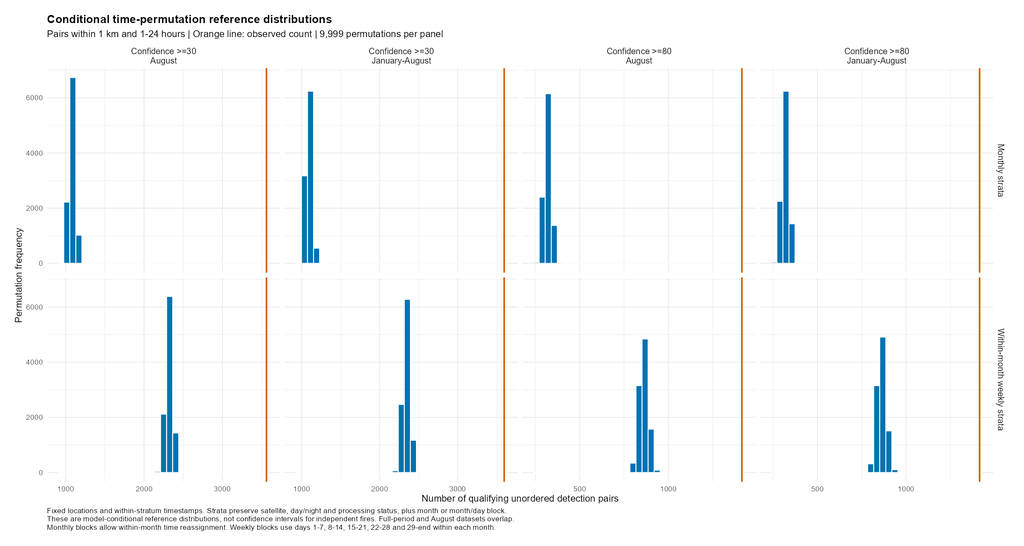

Figure 10: Observed pair counts against conditional permutation distributions.

Observed counts lie above every simulated count in each displayed 1 km/1–24-hour comparison. The more restrictive strata increase the reference means, showing that temporal grouping materially changes the benchmark, but observed counts remain higher. Each Monte Carlo p-value is 0.0001 at the chosen simulation resolution, and each final-family Holm-adjusted value is 0.0192. The distributions describe the conditional randomization model rather than uncertainty in a count of independent fires.

The main null hypotheses are rejected at the 5% level under both stratum definitions. The supported conclusion is **statistically significant time-location association of the recorded MODIS detections relative to the stated conditional models**. Rejection does not establish independent-fire clustering, causal spread, ignition mechanisms or deficiencies in an operational response.

### 10.1.5 Sensitivity results

**Show R code**

```r
sens <- primary[, c("subset", "period", "scheme", "observed_to_null_mean", "p_current")]
names(sens) <- c("Confidence subset", "Period", "Time strata", "Observed / null mean", "Holm p (192)")
knitr::kable(sens, digits = c(0, 0, 0, 2, 4), row.names = FALSE)
```

| Confidence subset | Period | Time strata | Observed / null mean | Holm p (192) |
| --- | --- | --- | --- | --- |
| Confidence >=30 | January-August | Monthly strata | 3.29 | 0.0192 |
| Confidence >=30 | January-August | Within-month weekly strata | 1.53 | 0.0192 |
| Confidence >=30 | August | Monthly strata | 3.30 | 0.0192 |
| Confidence >=30 | August | Within-month weekly strata | 1.53 | 0.0192 |
| Confidence >=80 | January-August | Monthly strata | 4.43 | 0.0192 |
| Confidence >=80 | January-August | Within-month weekly strata | 1.64 | 0.0192 |
| Confidence >=80 | August | Monthly strata | 4.44 | 0.0192 |
| Confidence >=80 | August | Within-month weekly strata | 1.64 | 0.0192 |

All 72 original comparisons have Monte Carlo p = 0.0001 and final-family Holm-adjusted p = 0.0192. Identical p-values reflect the finite simulation resolution, not identical effect sizes. The detailed simulated means, standard deviations, observed counts, upper-tail exceedances and Monte Carlo tail-probability intervals are retained in the calculation object. Full-period and August results overlap, and confidence ≥80 is nested within ≥30; these are sensitivity checks rather than eight independent confirmations.

The implementation records two-sided 95% binomial Monte Carlo intervals for the permutation tail probability. They describe numerical uncertainty in that tail probability, not a confidence interval for an ecological effect. More permutations would improve tail resolution but would not resolve exchangeability, event-definition or observation-opportunity limitations.

The historical adjustments were 0.0072 for 72 tests and 0.0144 for 144 tests. The final integrated conclusion uses the 192-test family, with adjusted p = 0.0192. Increasing the family changes the adjustment even when the underlying historical calculations remain unchanged.

### 10.1.6 Observation-preserving sensitivity design

#### 10.1.6.1 Why preserve complete days?

At the primary 1 km/1-24-hour setting, 1,946 of 3,597 pairs (54.1%) have both endpoints on the same UTC date. Individual time-label permutations can break this structure. The new design deliberately fixes every within-day spatial and temporal arrangement, so its random variation concerns the ordering of complete daily patterns and their cross-date proximity.

This does not require identifying true satellite orbits from timestamps. A UTC day is an explicitly chosen calendar block, not an orbit, a local-calendar day, or an independent fire. Groups spanning UTC midnight remain a limitation. The method conditions on observed daily patterns and does not infer cloud-free observation opportunities.

#### 10.1.6.2 Null hypothesis and implementation

The null states that complete observed daily patterns are exchangeable among the calendar dates within each time stratum. A permutation applies the **same date mapping to every record on a given UTC date**, across both satellites and day/night categories. Acquisition clock times and coordinates remain unchanged. All 243 calendar dates, including dates with no retained record, participate in the full-period permutation. Empty days represent empty recorded patterns, not verified fire-free or fully observed days.

The two schemes exchange complete days within a month or within that month’s blocks of days 1-7, 8-14, 15-21, 22-28 and 29-end. Month membership preserves the supplied processing-status transition. The stricter scheme retains shorter-term changes in the observed daily pattern distribution. Neither scheme preserves the full original temporal sequence; that is precisely the structure being tested. Changing clouds, observation geometry or other short-term factors can still violate daily exchangeability.

The distance/time grid, confidence subsets, periods and 9,999 permutations per case remain unchanged. Seeds are 2026091901-2026091908. These 72 comparisons joined the original 72 in the intermediate 144-test family. All now also enter the final 192-test family below. The extensions are exploratory, not retroactively pre-registered analyses.

#### 10.1.6.3 Parameter decisions

The scales address different questions. The 0.5-2 km pair distances bracket kilometre-scale pixel-centre proximity, whereas 5-20 km KDE bandwidths describe broader geographic concentration. Neither defines a physical fire footprint. The 6-72 hour upper lags compare short and multi-day associations without estimating fire duration. Agreement across these exploratory choices supports only the tested range.

The final robustness audit below varies the earlier one-hour lower lag and preserves three consecutive days in each movable block. Month restrictions still do not establish equal cloud cover or observation opportunity. Independent coverage information remains unavailable, so the extensions evaluate specified alternatives rather than validating exchangeability.

| Decision | Analytical purpose | Boundary on interpretation |
| --- | --- | --- |
| 1 km display, with 0.5 and 2 km sensitivities | Examine proximity around MODIS’s nominal kilometre-scale product | Supplied scan dimensions reach 4.82 km; centres and footprints differ. These thresholds cannot classify unique incidents |
| 1-hour lower lag | Remove simultaneous and near-simultaneous pairs from the statistic | It does not establish independence between overpasses or fires |
| 6, 24 and 72-hour upper lags | Compare subdaily, approximately daily and multi-day proximity | Exploratory temporal scales, not estimated fire durations or calibrated spread windows |
| Whole UTC-day blocks | Preserve every within-date observed arrangement | UTC boundaries can split a real observation sequence; the daily date mapping remains an assumption |
| 5/10/20 km descriptive KDE | Show how smoothing affects the apparent pattern | These are illustrative scales. No optimal ecological interaction bandwidth is claimed |
| 5/10 km recurrence grids and half-cell shifts | Compare repeated geographic recording at coarser support than the close-pair thresholds | Grid units are aggregation choices rather than event boundaries or satellite footprint reconstructions |

#### 10.1.6.4 Revised results

**Show R code**

```r
day_tab <- day_main[, c("scheme", "observed_pairs", "fixed_within_day_pairs", "null_mean", "observed_to_mean", "p_mc", "p_current")]
names(day_tab) <- c("Whole-day reassignment", "Observed", "Fixed within-day pairs", "Null mean", "Observed / mean", "Monte Carlo p", "Holm p (192)")
knitr::kable(day_tab, digits = c(0, 0, 0, 2, 2, 4, 4), row.names = FALSE)
```

| Whole-day reassignment | Observed | Fixed within-day pairs | Null mean | Observed / mean | Monte Carlo p | Holm p (192) |
| --- | --- | --- | --- | --- | --- | --- |
| Whole days within month | 3597 | 1946 | 2382.97 | 1.51 | 1e-04 | 0.0192 |
| Whole days within month blocks | 3597 | 1946 | 2937.63 | 1.22 | 1e-04 | 0.0192 |

**Show R code**

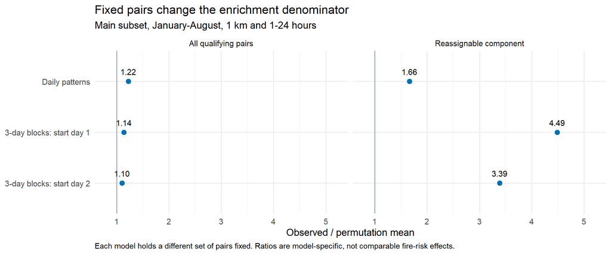

Figure 11: Total-pair and reassignable-component ratios under three conditional models.

```r
plot_pair_denominators(audit)
```

The panels separate all qualifying pairs from the component that can change under reassignment. Fixing longer sequences increases the fixed baseline, so a total ratio near one can coexist with a larger variable-component ratio. The models test different conditional questions. The figure does not estimate a common ecological effect or rank the models by correctness. Each displayed test has final-family Holm p = 0.0192.

#### 10.1.6.5 Expanded test family and the ratio denominator

All 72 whole-day comparisons have final-family Holm-adjusted p = 0.0192. Their unadjusted values are not all identical: 69 equal 0.0001, one equals 0.0003 and two equal 0.0004. Equal adjusted values do not imply identical evidence or effect sizes.

Under the stricter whole-day model, the variable cross-date component is 1,651 observed pairs against a simulated mean of 991.63, a ratio of 1.66. The total-pair ratio of 1.22 includes the 1,946 pairs fixed in every permutation. Both descriptions refer to the same test, but the ratios have different denominators. Comparing total-pair ratios between null designs therefore illustrates conditioning sensitivity, not a single invariant ecological effect size.

#### 10.1.6.6 Influence of high-record dates

The primary full-period count contains 685 pairs touching 29 August, the largest daily contribution. Omitting all records on that date would leave 2,912 qualifying pairs, a 19.04% decrease. This is an arithmetic influence diagnostic, not a new significance test: removing a date changes the null reference as well as the observed statistic. No records are removed from the reported analyses, and no date is selected for deletion to improve a p-value. Pair contributions across dates must not be added because cross-date pairs appear in two date-specific contributions.

### 10.1.7 Final audit: lower lags and continuous three-day patterns

The audit addresses two specific weaknesses: the earlier fixed one-hour exclusion and the loss of dependence across neighbouring dates. It holds distance at 1 km and upper lag at 24 hours, comparing lower lags of 0, 1, 3 and 6 hours. It evaluates both confidence subsets and both periods. These settings were fixed before inspecting this extension’s outputs, but follow the earlier exploratory analysis and are not an independent confirmatory study.

Alongside daily reassignment within the original week blocks, two new schemes permute complete three-day blocks **within each month**. The first starts on day 1, the second on day 2. Incomplete leading/trailing fragments remain at their original dates. Every full block retains its internal order, clock times, locations and empty recorded dates. Month boundaries and joins between blocks can still interrupt real sequences. Exchangeability of complete blocks remains an assumption; preserving three days does not account for longer persistence or measured cloud coverage.

There are 12 dataset/model cases, each with 9,999 permutations and four lower-lag statistics: 48 comparisons. Four daily one-hour settings repeat earlier primary questions and remain in the correction as conservative duplicates. The final family contains **192 comparisons**, rather than selectively dropping repeated or unfavourable results. Seeds are 2026092301-2026092312. The plus-one calculation includes ties. Saved binomial intervals quantify Monte Carlo tail-probability uncertainty, not uncertainty about fire risk.

**Show R code**

```r
final_main <- subset(audit$summary, subset == "Confidence >=30" & period == "January-August" & lower_hours == 1)
block_table <- final_main[, c("scheme", "observed", "guaranteed_fixed", "variable_observed", "variable_null_mean", "p_holm_192")]
names(block_table) <- c("Model", "All pairs", "Fixed pairs", "Variable observed", "Variable null mean", "Holm p (192)")
knitr::kable(block_table, digits = 4, row.names = FALSE)
```

| Model | All pairs | Fixed pairs | Variable observed | Variable null mean | Holm p (192) |
| --- | --- | --- | --- | --- | --- |
| Daily within week | 3597 | 1946 | 1651 | 993.4771 | 0.0192 |
| Three-day blocks offset 0 | 3597 | 3037 | 560 | 124.7311 | 0.0192 |
| Three-day blocks offset 1 | 3597 | 3129 | 468 | 138.1981 | 0.0192 |

All 48 added comparisons remain significant after the full correction, with adjusted p = 0.0192. This supports robustness to the tested lower lags and preservation of three-day sequences. It does not establish general robustness to all dependence structures. At the main one-hour setting, the three-day models fix 3,037 or 3,129 of 3,597 pairs, leaving only 560 or 468 in the reassignable observed component. Their significance concerns this residual conditional arrangement, not every observed pair.

**Show R code**

```r
lag_table <- subset(audit$summary, subset == "Confidence >=30" & period == "January-August")
lag_table <- lag_table[, c("scheme", "lower_hours", "observed", "guaranteed_fixed", "variable_ratio", "p_holm_192")]
names(lag_table) <- c("Model", "Lower lag h", "All pairs", "Fixed pairs", "Variable ratio", "Holm p (192)")
knitr::kable(lag_table, digits = 4, row.names = FALSE)
```

| Model | Lower lag h | All pairs | Fixed pairs | Variable ratio | Holm p (192) |
| --- | --- | --- | --- | --- | --- |
| Daily within week | 0 | 4619 | 2968 | 1.6618 | 0.0192 |
| Daily within week | 1 | 3597 | 1946 | 1.6618 | 0.0192 |
| Daily within week | 3 | 3597 | 1946 | 1.6618 | 0.0192 |
| Daily within week | 6 | 2579 | 1193 | 1.5249 | 0.0192 |
| Three-day blocks offset 0 | 0 | 4619 | 4059 | 4.4897 | 0.0192 |
| Three-day blocks offset 0 | 1 | 3597 | 3037 | 4.4897 | 0.0192 |
| Three-day blocks offset 0 | 3 | 3597 | 3037 | 4.4897 | 0.0192 |
| Three-day blocks offset 0 | 6 | 2579 | 2115 | 4.0997 | 0.0192 |
| Three-day blocks offset 1 | 0 | 4619 | 4151 | 3.3864 | 0.0192 |
| Three-day blocks offset 1 | 1 | 3597 | 3129 | 3.3864 | 0.0192 |
| Three-day blocks offset 1 | 3 | 3597 | 3129 | 3.3864 | 0.0192 |
| Three-day blocks offset 1 | 6 | 2579 | 2172 | 3.1698 | 0.0192 |

Changing the lower lag from zero to one hour removes 1,022 observed pairs in the main dataset, all from the fixed component in these models. The observed counts at one and three hours coincide; six hours removes further pairs. Thus unchanged significance does not mean the event definition is irrelevant. The audit separates what the cutoff changes in the data from what the chosen randomization can test. Independent all-pairs calculations verify observed counts and three saved permutations per case; a separate implementation reconstructs the 192-test Holm adjustment.

## 10.2 Connection to the course methods

[Chapter 5](https://r4gdsa.netlify.app/chap05.html) introduces spatial K/L summaries and simulation envelopes. Here, ordinary and intensity-reweighted summaries diagnose spatial structure, while the declared conditional permutation tests provide formal spatio-temporal inference. A default CSR envelope would change the reference model and would not be an interchangeable code simplification.

[Chapter 6](https://r4gdsa.netlify.app/chap06) provides the fire-detection space-time context. This report retains exact UTC acquisition times for its close-pair statistic. Replacing that test with a monthly marked point pattern or a space-time density estimate would answer a different question. The block-permutation and recurrence extensions are documented separately from the course examples.

## 10.3 Extraction and diagnostic implementations

The folded sources below expose the processing choices behind the figures, not only the presentation code. The rebuild entry point also shows how the confidence subsets are constructed. Scripts run as separate stages; rendering this page displays their source without rerunning them. Raw national data are not embedded in the page.

**filter_ketapang.R**

```r
# Geographic extraction helper. Review and understand before using in coursework.
# Raw sources are never edited. Existing outputs are not overwritten.
suppressPackageStartupMessages(library(sf))
suppressPackageStartupMessages(library(dplyr))
args <- commandArgs(trailingOnly = TRUE)
root <- if (length(args)) args[1] else "E:/JUNCHENLI/ISSS626_GAA/Take-Home_Ex/Take-Home_Ex01/data"
out <- if (length(args) >= 2L) args[2] else file.path(root, "Ketapang")
if (dir.exists(out)) stop("Output folder already exists; inspect it before rerunning.")
shp <- list.files(file.path(root, "Indonesia-geospasial"), pattern="[.]shp$", recursive=TRUE, full.names=TRUE)
stopifnot(length(shp) == 1)
layer <- tools::file_path_sans_ext(basename(shp))
sql <- sprintf("SELECT * FROM \"%s\" WHERE WADMPR = 'Kalimantan Barat' AND WADMKK = 'Ketapang'", layer)
cat("Reading Ketapang village polygons...\n")
villages_raw <- st_read(shp, query=sql, quiet=TRUE)
stopifnot(nrow(villages_raw) > 0, all(villages_raw$KDPKAB == "61.04", na.rm=TRUE))
# Use XY only. UTM 49S is a working CRS for topology operations, not a final
# selection of the projection/parameters for the student's statistical analysis.
villages <- st_transform(st_zm(villages_raw), 32749)
valid_before <- st_is_valid(villages)
cat("Village records:", nrow(villages), "; invalid before repair:", sum(!valid_before), "\n")
villages <- st_make_valid(villages)
stopifnot(all(st_is_valid(villages)), !any(st_is_empty(villages)))
window <- st_sf(province="Kalimantan Barat", regency="Ketapang", regency_code="61.04",
                geometry=st_union(st_geometry(villages)))
stopifnot(all(st_is_valid(window)), !any(st_is_empty(window)))

files <- list.files(file.path(root,"NASA FIRMS"), pattern="[.]csv$", full.names=TRUE)
stopifnot(length(files) == 2)
records <- lapply(files, function(f) {
  d <- read.csv(f, colClasses="character", check.names=FALSE, stringsAsFactors=FALSE)
  d$source_file <- basename(f)
  d$source_row <- seq_len(nrow(d))
  d$data_status <- if (grepl("fire_archive_",basename(f))) "standard" else "NRT"
  d
})
all <- bind_rows(records)
stopifnot(!anyNA(as.Date(all$acq_date)))
lon <- as.numeric(all$longitude); lat <- as.numeric(all$latitude)
stopifnot(all(is.finite(lon)), all(is.finite(lat)), all(abs(lon)<=180), all(abs(lat)<=90))
stopifnot(all(as.Date(all$acq_date)>=as.Date("2026-01-01")), all(as.Date(all$acq_date)<=as.Date("2026-08-31")))
points <- st_as_sf(all, coords=c("longitude","latitude"), crs=4326, remove=FALSE) |> st_transform(32749)
cat("Matching all fire detections to the derived Ketapang boundary...\n")
# Include points exactly on the supplied boundary; do not buffer or snap.
inside <- lengths(st_intersects(points, window)) > 0
selected <- all[inside,,drop=FALSE]
selected <- selected[order(selected$acq_date, selected$acq_time, selected$source_file, selected$source_row),]
strict <- lengths(st_within(points[inside,], window)) > 0
key <- c("latitude","longitude","acq_date","acq_time","satellite","instrument")
months <- data.frame(month=sprintf("2026-%02d",1:8))
monthly <- selected |> mutate(month=substr(acq_date,1,7)) |> count(month,data_status,name="detections")
monthly <- merge(expand.grid(month=months$month,data_status=c("standard","NRT")),monthly,all.x=TRUE)
monthly$detections[is.na(monthly$detections)] <- 0L

# Diagnose the unnamed West Kalimantan polygon without assigning it to Ketapang.
unknown_sql <- sprintf("SELECT * FROM \"%s\" WHERE WADMPR = 'Kalimantan Barat' AND (WADMKK IS NULL OR WADMKK = '')",layer)
unknown <- st_read(shp,query=unknown_sql,quiet=TRUE)
unknown_points <- 0L
unknown_overlap_km2 <- 0
if(nrow(unknown)) {
  unknown <- st_make_valid(st_transform(st_zm(unknown),32749))
  unknown_points <- sum(lengths(st_intersects(points,unknown))>0)
  overlap <- suppressWarnings(st_intersection(st_union(st_geometry(unknown)), st_geometry(window)))
  unknown_overlap_km2 <- sum(as.numeric(st_area(overlap)))/1e6
}
stopifnot(nrow(selected)>0)
dir.create(out,recursive=TRUE)
write.csv(selected,file.path(out,"ketapang_modis_2026_jan_aug.csv"),row.names=FALSE,na="",fileEncoding="UTF-8")
write.csv(monthly,file.path(out,"monthly_record_counts.csv"),row.names=FALSE)
st_write(st_transform(window,4326),file.path(out,"ketapang_boundary.gpkg"),layer="study_window",quiet=TRUE)
st_write(st_transform(villages,4326),file.path(out,"ketapang_boundary.gpkg"),layer="villages",quiet=TRUE)
checks <- data.frame(metric=c("input_records","selected_records","excluded_records","village_records","invalid_villages_before_repair","invalid_villages_after_repair","boundary_only_records","duplicate_detection_keys","unnamed_west_kalimantan_polygons","records_in_unnamed_polygons","unnamed_polygon_overlap_km2"),
 value=c(nrow(all),nrow(selected),sum(!inside),nrow(villages),sum(!valid_before),sum(!st_is_valid(villages)),sum(!strict),sum(duplicated(selected[,key])),nrow(unknown),unknown_points,unknown_overlap_km2))
write.csv(checks,file.path(out,"filter_checks.csv"),row.names=FALSE)
inputs <- c(list.files(dirname(shp),full.names=TRUE),files)
hashes <- tools::md5sum(inputs)
write.csv(data.frame(file=basename(inputs),md5=unname(hashes)),file.path(out,"source_checksums.csv"),row.names=FALSE)
capture.output(sessionInfo(),file=file.path(out,"session-info.txt"))
# Round-trip checks, with text preserved so HHMM retains leading zeros.
saved <- read.csv(file.path(out,"ketapang_modis_2026_jan_aug.csv"),colClasses="character")
stopifnot(nrow(saved)==sum(inside),identical(saved$acq_time,selected$acq_time))
saved_window <- st_read(file.path(out,"ketapang_boundary.gpkg"),layer="study_window",quiet=TRUE) |> st_transform(32749)
stopifnot(all(lengths(st_intersects(points[inside,],saved_window))>0))
cat("\nCHECKS\n");print(checks,row.names=FALSE)
cat("\nMONTHLY\n");print(xtabs(detections~month+data_status,monthly))
cat("\nDATE RANGE\n");print(range(selected$acq_date))
cat("\nTYPE\n");print(table(selected$type,useNA="ifany"))
cat("\nOutput:",out,"\n")
```

**plot_data_checks.R**

```r
# Descriptive data checks only; no spatial significance tests or event merging.
# Run: Rscript plot_data_checks.R "path/to/data/Ketapang"
suppressPackageStartupMessages(library(sf))
suppressPackageStartupMessages(library(ggplot2))
args <- commandArgs(trailingOnly = TRUE)
root <- if (length(args)) args[1] else "."
out <- file.path(root, "figures")
outputs <- file.path(out, c("ketapang_detection_locations.png", "ketapang_monthly_detections.png"))
if (any(file.exists(outputs))) stop("A plot already exists; review before replacing it.")
inputs <- file.path(root, c("ketapang_modis_2026_jan_aug.csv", "ketapang_modis_2026_conf30.csv",
                           "ketapang_modis_2026_conf80.csv", "monthly_confidence_comparison.csv", "ketapang_boundary.gpkg"))
before <- tools::md5sum(inputs)
read_detections <- function(f) read.csv(f, colClasses=c(acq_time="character"), stringsAsFactors=FALSE)
all_points <- read_detections(inputs[1])
main <- read_detections(inputs[2])
high <- read_detections(inputs[3])
counts <- read.csv(inputs[4], stringsAsFactors=FALSE)
boundary <- st_read(inputs[5], layer="study_window", quiet=TRUE)
stopifnot(nrow(all_points)==4738, nrow(main)==4472, nrow(high)==1726)
stopifnot(all(main$confidence>=30), all(high$confidence>=80))
for (i in seq_len(nrow(counts))) {
  month <- counts$month[i]
  stopifnot(sum(substr(all_points$acq_date,1,7)==month)==counts$all_detections[i],
            sum(substr(main$acq_date,1,7)==month)==counts$confidence_ge30[i],
            sum(substr(high$acq_date,1,7)==month)==counts$confidence_ge80[i])
}
main$subset <- "Confidence >=30 | n = 4,472"
high$subset <- "Confidence >=80 | n = 1,726"
map_data <- rbind(main, high)
map_data$subset <- factor(map_data$subset, levels=c(main$subset[1], high$subset[1]))
points_sf <- st_as_sf(map_data, coords=c("longitude","latitude"), crs=4326)
# Validate inclusion in the saved study window using the same working projection
# as extraction. Plot labels remain geographic coordinates for readability.
inside <- lengths(st_intersects(st_transform(points_sf,32749),st_transform(boundary,32749)))>0
stopifnot(all(inside))
theme_set(theme_minimal(base_size=12, base_family="sans"))
base_theme <- theme(
  plot.background=element_rect(fill="white",colour=NA),
  panel.background=element_rect(fill="#F4F7FA",colour=NA),
  plot.title=element_text(face="bold",size=18),
  plot.subtitle=element_text(colour="#475569",size=11),
  plot.caption=element_text(colour="#475569",size=9,hjust=0),
  plot.caption.position="plot",
  plot.margin=margin(16,20,16,16),
  strip.text=element_text(face="bold",size=12),
  panel.grid.major=element_line(colour="#DFE5EB",linewidth=0.25),
  panel.grid.minor=element_blank()
)
map <- ggplot() +
  geom_sf(data=boundary,fill="#E8EEE9",colour="#52665B",linewidth=0.35) +
  geom_sf(data=points_sf,colour="#B83E32",size=0.5,alpha=0.45,stroke=0) +
  facet_wrap(~subset,nrow=1) +
  coord_sf(crs=4326,datum=st_crs(4326),expand=TRUE) +
  labs(title="MODIS detections in Ketapang",
       subtitle="Observation window: 1 January-31 August 2026 | Same extent and point styling in both panels",
       x="Longitude",y="Latitude",
       caption=paste("Sources: NASA FIRMS MODIS; supplied Indonesia Geospatial village boundaries (dissolved to Ketapang).",
                     "Panels are nested subsets, not independent samples. Detections are not counts of unique fires; darker areas may reflect overlapping symbols.",sep="\n")) + base_theme
series <- c("All detections", "Confidence >=30", "Confidence >=80")
monthly <- do.call(rbind,lapply(seq_along(series),function(i) {
  data.frame(month=factor(month.abb[1:8],levels=month.abb[1:8]),
             subset=series[i], detections=counts[[c("all_detections","confidence_ge30","confidence_ge80")[i]]])
}))
monthly$subset <- factor(monthly$subset,levels=series)
dodge <- position_dodge(width=0.84)
bars <- ggplot(monthly,aes(month,detections,fill=subset)) +
  geom_col(position=dodge,width=0.78) +
  geom_text(aes(label=format(detections,big.mark=",",trim=TRUE)),position=dodge,vjust=-0.45,size=3.1) +
  scale_fill_manual(values=c("All detections"="#94A3B8","Confidence >=30"="#176B80","Confidence >=80"="#BE632B"),name=NULL) +
  scale_y_continuous(labels=function(x)format(x,big.mark=",",scientific=FALSE,trim=TRUE),
                     limits=c(0,NA),expand=expansion(mult=c(0,0.12))) +
  labs(title="Monthly MODIS detection counts",
       subtitle="Ketapang | January-August 2026 | Counts compared under the confirmed confidence thresholds",
       x=NULL,y="Number of detections",
       caption=paste("Source: NASA FIRMS MODIS, spatially filtered to the supplied Ketapang boundary. January-April: standard; May-August: NRT.",
                     "Series are nested and must not be added. A zero means no records retained under that filter, not proof of no fires.",sep="\n")) +
  base_theme + theme(legend.position="top",legend.justification="left",panel.grid.major.x=element_blank())
dir.create(out,recursive=TRUE,showWarnings=FALSE)
ggsave(outputs[1],map,width=14,height=8,dpi=160,bg="white")
ggsave(outputs[2],bars,width=14,height=7,dpi=160,bg="white")
stopifnot(identical(before,tools::md5sum(inputs)))
cat("All displayed points are inside the saved boundary. Monthly counts match all three CSV inputs.\n")
cat("Input hashes unchanged.\n")
cat(paste(outputs,collapse="\n"),"\n")
```

**learning/kde_learning.R**

```r
# Learning demonstration: fixed, illustrative bandwidths, not an optimal selection.
# Run with the Ketapang data directory as the first argument.
suppressPackageStartupMessages(library(sf))
suppressPackageStartupMessages(library(spatstat.geom))
suppressPackageStartupMessages(library(spatstat.explore))
suppressPackageStartupMessages(library(ggplot2))
args <- commandArgs(trailingOnly=TRUE)
root <- if(length(args)) args[1] else ".."
out <- file.path(root,"learning")
targets <- file.path(out,c("kde_bandwidth_demo.png","kde_confidence_demo.png","kde_checks.txt"))
if(any(file.exists(targets)) && !"--replace-generated" %in% args) stop("Learning outputs exist; review before overwriting.")
inputs <- file.path(root,c("ketapang_boundary.gpkg","ketapang_modis_2026_conf30.csv","ketapang_modis_2026_conf80.csv"))
hash_before <- tools::md5sum(inputs)
boundary <- st_transform(st_read(inputs[1],layer="study_window",quiet=TRUE),32749)
stopifnot(all(st_is_valid(boundary)),!any(st_is_empty(boundary)))
window_m <- as.owin(boundary)
stopifnot(abs(area.owin(window_m)-sum(as.numeric(st_area(boundary))))/area.owin(window_m)<1e-8)
window_km <- rescale(window_m,1000,"km")
make_pattern <- function(file) {
  d <- read.csv(file,colClasses=c(acq_time="character"))
  p <- st_transform(st_as_sf(d,coords=c("longitude","latitude"),crs=4326),32749)
  xy <- st_coordinates(p)/1000
  stopifnot(all(inside.owin(xy[,1],xy[,2],window_km)))
  x <- ppp(xy[,1],xy[,2],window=window_km,checkdup=TRUE)
  stopifnot(npoints(x)==nrow(d))
  x
}
main <- make_pattern(inputs[2]); high <- make_pattern(inputs[3])
stopifnot(npoints(main)==4472,npoints(high)==1726)
sigmas <- c(5,10,20)
# Distances and bandwidths are in km; each point contributes weight 1.
# 0.5 km pixels control numerical rendering, not the satellite's resolution.
kde <- function(x,sigma) density(x,sigma=sigma,kernel="gaussian",edge=TRUE,diggle=TRUE,eps=0.5)
surfaces <- lapply(sigmas,function(s) kde(main,s))
high_surface <- kde(high,10)
checks <- data.frame(subset=c(rep("confidence_ge30",3),"confidence_ge80"),
  sigma_km=c(sigmas,10),records=c(rep(npoints(main),3),npoints(high)),
  integral=vapply(c(surfaces,list(high_surface)),integral.im,numeric(1)))
checks$relative_mass_error <- abs(checks$integral-checks$records)/checks$records
stopifnot(all(checks$relative_mass_error<0.05))
for(z in c(surfaces,list(high_surface))) {
  stopifnot(all(is.finite(z$v[!is.na(z$v)])),min(z$v,na.rm=TRUE)>-1e-8)
}
to_grid <- function(z,label) {
  d <- as.data.frame(z)
  names(d)[1:3] <- c("x","y","intensity")
  d <- d[!is.na(d$intensity),]
  # FFT round-off can produce negligible negatives; truncate only for display.
  d$intensity <- pmax(d$intensity,0)
  d$pixel_width <- z$xstep
  d$pixel_height <- z$ystep
  d$panel <- label
  d
}
bw_labels <- paste0("sigma = ",sigmas," km")
bw_grid <- do.call(rbind,Map(to_grid,surfaces,bw_labels))
bw_grid$panel <- factor(bw_grid$panel,levels=bw_labels)
conf_labels <- c("Confidence >=30 | n = 4,472","Confidence >=80 | n = 1,726")
conf_grid <- rbind(to_grid(surfaces[[2]],conf_labels[1]),to_grid(high_surface,conf_labels[2]))
conf_grid$panel <- factor(conf_grid$panel,levels=conf_labels)
coords <- st_coordinates(boundary)
outline <- data.frame(x=coords[,"X"]/1000,y=coords[,"Y"]/1000,
  ring=apply(coords[,grep("^L",colnames(coords)),drop=FALSE],1,paste,collapse="_"))
draw <- function(d,title,subtitle,caption) {
  ggplot(d,aes(x,y,fill=intensity))+
    geom_tile(aes(width=pixel_width,height=pixel_height))+
    geom_path(data=outline,aes(x,y,group=ring),inherit.aes=FALSE,colour="#64748B",linewidth=0.25)+
    facet_wrap(~panel,nrow=1)+coord_equal(expand=FALSE)+
    scale_fill_viridis_c(option="magma",limits=c(0,max(d$intensity)),
      name="Detections / km²\n(over Jan-Aug)",na.value="white")+
    labs(title=title,subtitle=subtitle,x="UTM zone 49S easting (km)",y="UTM zone 49S northing (km)",caption=caption)+
    theme_minimal(base_size=12)+theme(
      plot.title=element_text(face="bold",size=17),
      plot.subtitle=element_text(size=11,colour="#475569"),
      strip.text=element_text(face="bold",size=11),
      panel.grid=element_blank(),panel.background=element_rect(fill="white",colour=NA),
      plot.background=element_rect(fill="white",colour=NA),
      plot.caption=element_text(hjust=0,size=9,colour="#475569"),
      plot.caption.position="plot",plot.margin=margin(16,16,16,16),legend.position="right")
}
p1 <- draw(bw_grid,"Recorded detection intensity across KDE bandwidths",
  "Ketapang MODIS | Confidence >=30 | 1 January-31 August 2026 | Common colour scale",
  paste("Illustrative bandwidths, not an optimised or final choice. Gaussian kernel; Jones-Diggle edge correction; 0.5 km computational grid.",
        "Intensity refers to recorded detections, not independent fires or risk. Sources: NASA FIRMS and the supplied Indonesia Geospatial boundary.",sep="\n"))
p2 <- draw(conf_grid,"Recorded detection intensity across confidence thresholds",
  "Ketapang MODIS | sigma = 10 km in both panels | 1 January-31 August 2026 | Common colour scale",
  paste("Absolute intensity is not normalised by record count; fewer retained records can reduce intensity. The >=80 subset is nested within >=30.",
        "These are descriptive maps, not tests of clustering. Sources: NASA FIRMS and the supplied Indonesia Geospatial boundary.",sep="\n"))
dir.create(out,recursive=TRUE,showWarnings=FALSE)
ggsave(targets[1],p1,width=15,height=9,dpi=160,bg="white")
ggsave(targets[2],p2,width=12,height=9,dpi=160,bg="white")
stopifnot(identical(hash_before,tools::md5sum(inputs)))
capture.output({
  cat("Working projection: EPSG:32749; computational distance unit: km\n")
  cat("Derived study-window area (km2):",area.owin(window_km),"\n")
  cat("All records inside polygon window; no dropped points.\n")
  print(checks,row.names=FALSE)
  cat("Original inputs unchanged; MD5:\n");print(hash_before)
  cat("\nRuntime versions:\n");print(sessionInfo())
},file=targets[3])
print(checks,row.names=FALSE)
cat("Study-window area (km2):",area.owin(window_km),"\n")
cat("Outputs:\n",paste(targets,collapse="\n"),"\n")
```

**second_order_diagnostics.R**

```r
# Exploratory second-order summaries, not a significance test.
# Usage: Rscript second_order_diagnostics.R <Ketapang data directory>
suppressPackageStartupMessages(library(sf))
suppressPackageStartupMessages(library(spatstat.geom))
suppressPackageStartupMessages(library(spatstat.explore))
suppressPackageStartupMessages(library(ggplot2))
args <- commandArgs(trailingOnly = TRUE)
if (length(args) != 1L) stop("Supply the Ketapang data directory.")
root <- normalizePath(args[1], mustWork = TRUE)
out <- file.path(root, "second_order")
if (dir.exists(out)) stop("Output directory already exists; review before rerunning.")
inputs <- file.path(root, c("ketapang_boundary.gpkg",
  "ketapang_modis_2026_conf30.csv", "ketapang_modis_2026_conf80.csv"))
before <- tools::md5sum(inputs)
boundary <- st_transform(st_read(inputs[1], layer = "study_window", quiet = TRUE), 32749)
stopifnot(all(st_is_valid(boundary)), !any(st_is_empty(boundary)))
window <- rescale(as.owin(boundary), 1000, "km")
stopifnot(abs(area.owin(window) - sum(as.numeric(st_area(boundary))) / 1e6) < 1e-4)
labels <- c("Confidence >=30 (n = 4,472)", "Confidence >=80 (n = 1,726)")
expected <- c(4472L, 1726L)
results <- vector("list", 2)
# A bounded initial diagnostic range, not a final inferential distance range.
rmax_km <- 10
for (i in seq_along(results)) {
  records <- read.csv(inputs[i + 1L], colClasses = "character")
  points <- st_transform(st_as_sf(records, coords = c("longitude", "latitude"), crs = 4326), 32749)
  xy <- st_coordinates(points) / 1000
  stopifnot(nrow(xy) == expected[i], all(inside.owin(xy[, 1], xy[, 2], window)))
  pattern <- ppp(xy[, 1], xy[, 2], window = window, checkdup = TRUE)
  stopifnot(npoints(pattern) == expected[i])
  cat("Computing border-corrected K summary:", labels[i], "\n")
  flush.console()
  # Border correction is explicit; it is computationally tractable for the
  # detailed polygon and large point pattern. Its loss of centres is audited.
  k <- Kest(pattern, rmax = rmax_km, correction = "border")
  kd <- as.data.frame(k)
  stopifnot(all(c("r", "border", "theo") %in% names(kd)),
    all(is.finite(kd$border)), all(kd$border >= 0),
    max(abs(kd$theo - pi * kd$r^2)) < 1e-8)
  distances <- bdist.points(pattern)
  support_r <- 0:10
  support_n <- vapply(support_r, function(r) sum(distances > r), integer(1))
  stopifnot(all(diff(support_n) <= 0), all(support_n > 0))
  results[[i]] <- list(label = labels[i], records = nrow(records),
    distinct_dates = length(unique(records$acq_date)),
    duplicate_coordinates = sum(duplicated(as.data.frame(xy))),
    K = k,
    curve = data.frame(r_km = kd$r, L_minus_r_km = sqrt(kd$border / pi) - kd$r,
      subset = labels[i]),
    support = data.frame(r_km = support_r, eligible_centres = support_n,
      fraction = support_n / nrow(records), subset = labels[i]))
}
curves <- do.call(rbind, lapply(results, `[[`, "curve"))
support <- do.call(rbind, lapply(results, `[[`, "support"))
palette <- setNames(c("#0072B2", "#D55E00"), labels)
base_theme <- theme_minimal(base_size = 12) + theme(
  plot.title = element_text(face = "bold"), legend.position = "bottom",
  legend.title = element_blank(), plot.caption = element_text(hjust = 0, size = 9),
  plot.caption.position = "plot", plot.margin = margin(15, 15, 15, 15))
p1 <- ggplot(curves, aes(r_km, L_minus_r_km, colour = subset)) +
  geom_hline(yintercept = 0, linetype = "dashed", colour = "grey40") +
  geom_line(linewidth = 0.85) + scale_colour_manual(values = palette) +
  scale_x_continuous(breaks = seq(0, 10, 2)) +
  labs(title = "Exploratory L(r) - r summaries",
    subtitle = "Ketapang MODIS | January-August 2026 | Border correction",
    x = "Distance r (km)", y = "L(r) - r (km)",
    caption = paste("Dashed zero line: homogeneous Poisson theoretical reference, NOT a significance threshold.",
      "No simulations or p-values. Spatial intensity variation and repeated detections are not adjusted for.",
      "The 0-10 km range is provisional. Nested confidence subsets are not independent samples.",
      "Sources: NASA FIRMS; supplied Indonesia Geospatial boundary.", sep = "\n")) + base_theme
p2 <- ggplot(support, aes(r_km, fraction * 100, colour = subset)) +
  geom_line(linewidth = 0.85) + geom_point(size = 2) +
  scale_colour_manual(values = palette) + scale_y_continuous(limits = c(0, 100)) +
  scale_x_continuous(breaks = seq(0, 10, 2)) +
  labs(title = "Border-correction support by distance",
    subtitle = "Percentage of observed points more than r km from the window boundary",
    x = "Distance r (km)", y = "Eligible centres (%)",
    caption = paste("Border correction uses interior points as centres; neighbouring points are not filtered in the same way.",
      "This is a support diagnostic, not an uncertainty interval or proof that a distance range is valid.",
      "The supplied polygon retains holes and disconnected components; no points were removed from input files.", sep = "\n")) + base_theme
stopifnot(identical(before, tools::md5sum(inputs)))
dir.create(out, recursive = TRUE)
ggsave(file.path(out, "observed_L_summary.png"), p1, width = 10, height = 7, dpi = 160, bg = "white")
ggsave(file.path(out, "border_support.png"), p2, width = 10, height = 7, dpi = 160, bg = "white")
saveRDS(list(results = results, projection = "EPSG:32749", units = "km",
  provisional_rmax_km = rmax_km, source_md5 = before), file.path(out, "observed_summaries.rds"))
capture.output({
  cat("EXPLORATORY DIAGNOSTICS: not a significance test or final model.\n")
  cat("Projection: EPSG:32749. Coordinate and distance units: km.\n")
  cat("Window area (km2):", area.owin(window), "\n")
  cat("Estimator: homogeneous Kest, border correction; L = sqrt(K/pi).\n")
  cat("Initial diagnostic range: 0-10 km, not a final justified test range.\n")
  cat("All input points retained inside the full polygon; area conversion verified.\n")
  for (z in results) {
    cat("\n", z$label, "\nDistinct dates:", z$distinct_dates,
      "\nExact duplicate coordinates:", z$duplicate_coordinates, "\n")
    print(z$support[, c("r_km", "eligible_centres", "fraction")], row.names = FALSE)
  }
  cat("\nNo temporal interaction model, intensity adjustment, simulations or p-values.\n")
  cat("A homogeneous reference is not established as appropriate for these data.\n")
  cat("Boundary support does not address spatially varying observation opportunity.\n")
  cat("Input files unchanged; MD5:\n"); print(before)
  cat("\nReferences:\nhttps://search.r-project.org/CRAN/refmans/spatstat.explore/html/Kest.html\n")
  cat("https://search.r-project.org/CRAN/refmans/spatstat.explore/html/Lest.html\n")
  print(sessionInfo())
}, file = file.path(out, "checks.txt"))
stopifnot(identical(before, tools::md5sum(inputs)))
cat("Completed. Input checksums unchanged. Outputs:", out, "\n")
```

**inhomogeneous_diagnostics.R**

```r
# Exploratory intensity-reweighted summaries; not a fitted final null model.
# Usage: Rscript inhomogeneous_diagnostics.R <Ketapang data directory>
suppressPackageStartupMessages(library(sf))
suppressPackageStartupMessages(library(spatstat.geom))
suppressPackageStartupMessages(library(spatstat.explore))
suppressPackageStartupMessages(library(ggplot2))
args <- commandArgs(trailingOnly = TRUE)
if (length(args) != 1L) stop("Supply the Ketapang data directory.")
root <- normalizePath(args[1], mustWork = TRUE)
out <- file.path(root, "inhomogeneous_checks")
if (dir.exists(out)) stop("Output directory exists; review before rerunning.")
inputs <- file.path(root, c("ketapang_boundary.gpkg",
  "ketapang_modis_2026_conf30.csv", "ketapang_modis_2026_conf80.csv"))
before <- tools::md5sum(inputs)
baseline_file <- file.path(root, "second_order", "observed_summaries.rds")
baseline_hash <- tools::md5sum(baseline_file)
baseline <- readRDS(baseline_file)
stopifnot(identical(unname(before), unname(baseline$source_md5)),
          baseline$projection == "EPSG:32749", baseline$units == "km")
boundary <- st_transform(st_read(inputs[1], layer = "study_window", quiet = TRUE), 32749)
stopifnot(all(st_is_valid(boundary)), !any(st_is_empty(boundary)))
window <- rescale(as.owin(boundary), 1000, "km")
area_km2 <- area.owin(window)
stopifnot(abs(area_km2 - sum(as.numeric(st_area(boundary))) / 1e6) < 1e-4)
sigmas <- c(5, 10, 20)
expected <- c(4472L, 1726L)
panel_labels <- c("Confidence >=30 | n = 4,472", "Confidence >=80 | n = 1,726")
all_results <- list()
curve_frames <- list()
audit_frames <- list()
for (i in 1:2) {
  records <- read.csv(inputs[i + 1L], colClasses = "character")
  point_sf <- st_transform(st_as_sf(records, coords = c("longitude", "latitude"),
                                  crs = 4326), 32749)
  xy <- st_coordinates(point_sf) / 1000
  stopifnot(nrow(xy) == expected[i], all(inside.owin(xy[, 1], xy[, 2], window)))
  x <- ppp(xy[, 1], xy[, 2], window = window, checkdup = TRUE)
  stopifnot(npoints(x) == expected[i])
  previous <- baseline$results[[i]]
  stopifnot(previous$records == npoints(x))
  r <- previous$curve$r_km
  stopifnot(min(r) == 0, max(r) <= 10 + 1e-8)
  baseline_curve <- previous$curve
  baseline_curve$panel <- panel_labels[i]
  baseline_curve$method <- "Ordinary L (unadjusted)"
  curve_frames[[length(curve_frames) + 1L]] <-
    baseline_curve[, c("r_km", "L_minus_r_km", "panel", "method")]
  for (sigma in sigmas) {
    cat("Computing", panel_labels[i], "with sigma =", sigma, "km\n")
    flush.console()
    # Evaluate intensity at the original points. Exclude each point's own
    # kernel contribution; do not look up the earlier full-data raster KDE.
    lambda <- density(x, sigma = sigma, at = "points", leaveoneout = TRUE,
      kernel = "gaussian", edge = TRUE, diggle = TRUE, eps = 0.5)
    stopifnot(length(lambda) == npoints(x), all(is.finite(lambda)), all(lambda > 0))
    # No arbitrary floor, clipping or deletion is applied to intensity weights.
    # The existing 0-10 km grid and border correction are held constant.
    ki <- Kinhom(x, lambda = as.numeric(lambda), r = r, correction = "border",
                 renormalise = TRUE, normpower = 2)
    kd <- as.data.frame(ki)
    cat("Raw K range:", range(kd$border), "\n")
    # Cumulative numerical sums can produce tiny negative round-off near zero.
    # Keep raw K in the saved object; bound only the square-root display input.
    roundoff_tolerance_km2 <- 1e-8
    stopifnot(identical(kd$r, r), all(is.finite(kd$border)),
              all(kd$border >= -roundoff_tolerance_km2),
              max(abs(kd$theo - pi * r^2)) < 1e-8)
    method_label <- paste0("Reweighted L: sigma = ", sigma, " km")
    curve_frames[[length(curve_frames) + 1L]] <- data.frame(
      r_km = r, L_minus_r_km = sqrt(pmax(kd$border, 0) / pi) - r,
      panel = panel_labels[i], method = method_label)
    reciprocal <- 1 / as.numeric(lambda)
    shares <- reciprocal / sum(reciprocal)
    normalization <- area_km2 / sum(reciprocal)
    audit_frames[[length(audit_frames) + 1L]] <- data.frame(
      subset = panel_labels[i], sigma_km = sigma, records = npoints(x),
      minimum_intensity = min(lambda), median_intensity = median(lambda),
      maximum_intensity = max(lambda),
      maximum_reciprocal_share = max(shares),
      reciprocal_effective_count = 1 / sum(shares^2),
      normalization_c = normalization,
      correction_multiplier_c_squared = normalization^2,
      minimum_raw_K = min(kd$border),
      negative_roundoff_values = sum(kd$border < 0))
    key <- paste0("conf", c(30, 80)[i], "_sigma", sigma)
    all_results[[key]] <- list(subset = panel_labels[i], sigma_km = sigma,
      source_row = records$source_row, source_file = records$source_file,
      lambda_at_points = lambda, Kinhom = ki)
  }
}
curves <- do.call(rbind, curve_frames)
audit <- do.call(rbind, audit_frames)
method_levels <- c("Ordinary L (unadjusted)", paste0("Reweighted L: sigma = ", sigmas, " km"))
curves$method <- factor(curves$method, levels = method_levels)
curves$panel <- factor(curves$panel, levels = panel_labels)
colours <- setNames(c("#6B7280", "#0072B2", "#D55E00", "#009E73"), method_levels)
line_types <- setNames(c("dashed", "solid", "solid", "solid"), method_levels)
plot_curves <- function(d, title, subtitle) {
  ggplot(d, aes(r_km, L_minus_r_km, colour = method, linetype = method)) +
    geom_hline(yintercept = 0, colour = "#334155", linewidth = 0.4) +
    geom_line(linewidth = 0.8) + facet_wrap(~panel, nrow = 1) +
    scale_colour_manual(values = colours, drop = TRUE) +
    scale_linetype_manual(values = line_types, drop = TRUE) +
    scale_x_continuous(breaks = seq(0, 10, 2)) +
    labs(title = title, subtitle = subtitle, x = "Distance r (km)",
      y = "L(r) - r (km)", colour = NULL, linetype = NULL,
      caption = paste(
        "Gaussian leave-one-out intensity at points; Jones-Diggle density correction; border-corrected Kinhom.",
        "Kinhom renormalise = TRUE, normpower = 2. Zero is a Poisson theoretical reference, not a significance threshold.",
        "Bandwidths and 0-10 km range are illustrative. Same data estimate intensity and the summary; no simulations or p-values.",
        "Nested confidence subsets; no adjustment for repeated detections or observation opportunity. Sources: NASA FIRMS; supplied boundary.",
        sep = "\n")) +
    theme_minimal(base_size = 12) + theme(
      plot.title = element_text(face = "bold", size = 16),
      plot.subtitle = element_text(size = 11),
      strip.text = element_text(face = "bold"),
      legend.position = "bottom", legend.text = element_text(size = 10),
      plot.caption = element_text(hjust = 0, size = 9),
      plot.caption.position = "plot", plot.margin = margin(16, 16, 16, 16)) +
    guides(colour = guide_legend(nrow = 2), linetype = guide_legend(nrow = 2))
}
p_compare <- plot_curves(curves, "Exploratory L summaries: intensity reweighting",
  "Ketapang MODIS | January-August 2026 | Shared axes across confidence subsets")
p_sensitivity <- plot_curves(subset(curves, method != method_levels[1]),
  "Bandwidth sensitivity of intensity-reweighted L summaries",
  "Same curves as the comparison plot, with a closer vertical scale | Exploratory only")
stopifnot(identical(before, tools::md5sum(inputs)),
          identical(baseline_hash, tools::md5sum(baseline_file)))
dir.create(out, recursive = TRUE)
ggsave(file.path(out, "ordinary_vs_reweighted_L.png"), p_compare,
       width = 13, height = 8, dpi = 160, bg = "white")
ggsave(file.path(out, "reweighted_bandwidth_sensitivity.png"), p_sensitivity,
       width = 13, height = 8, dpi = 160, bg = "white")
saveRDS(list(estimates = all_results, curves = curves, intensity_audit = audit,
  source_md5 = before, baseline_md5 = baseline_hash, projection = "EPSG:32749",
  coordinate_units = "km", window_area_km2 = area_km2,
  settings = list(leaveoneout = TRUE, density_edge = "Jones-Diggle",
    density_eps_km = 0.5, K_edge = "border", renormalise = TRUE, normpower = 2)),
  file.path(out, "intensity_reweighted_summaries.rds"))
capture.output({
  cat("EXPLORATORY SENSITIVITY CHECKS: no final null model or significance test.\n")
  cat("Window area (km2):", area_km2, "\nProjection: EPSG:32749. Coordinates: km.\n")
  cat("Intensity: Gaussian, sigma 5/10/20 km, unit-weight detections, at points, leave-one-out.\n")
  cat("Density edge correction: Jones-Diggle; computational edge grid eps = 0.5 km.\n")
  cat("Kinhom: supplied positive intensity vector; border; renormalise TRUE; normpower 2.\n")
  cat("Distance grid matches previous 0-10 km diagnostic. K transformed as sqrt(K/pi).\n")
  cat("All original points retained, finite positive intensity estimates; K nonnegative to 1e-8 km2 tolerance.\n")
  cat("Raw K preserved; only negative round-off within tolerance is set to zero for the square-root plot.\n")
  cat("No intensity flooring, clipping, thinning or event merging applied.\n\n")
  print(audit, row.names = FALSE, digits = 6)
  cat("\nReciprocal effective count = 1/sum(normalised inverse-intensity weights squared).\n")
  cat("This is a weight-concentration diagnostic, NOT the number of independent observations.\n")
  cat("Small estimated intensities can cause high leverage; finite values alone do not establish reliability.\n")
  cat("Leave-one-out removes only the focal contribution; it is not independent validation.\n")
  cat("Intensity and summaries use the same observations. Bandwidth can absorb or retain spatial structure.\n")
  cat("Interpretation additionally requires an appropriate intensity-reweighted second-order model.\n")
  cat("Fitted intensity does not separately identify ecological causes and observation effects.\n")
  cat("Nested subsets are not independent. Full-period spatial summaries do not model time.\n")
  cat("No envelopes, p-values, significant-cluster claims or final parameter choices.\n")
  cat("A future fitted-null simulation must account for intensity estimation, not hold it fixed without justification.\n")
  cat("\nInput MD5 unchanged:\n"); print(before)
  cat("\nPrevious summary MD5 unchanged:\n"); print(baseline_hash)
  cat("\nReferences:\nhttps://search.r-project.org/CRAN/refmans/spatstat.explore/html/Kinhom.html\n")
  cat("https://search.r-project.org/CRAN/refmans/spatstat.explore/html/density.ppp.html\n")
  print(sessionInfo())
}, file = file.path(out, "checks.txt"))
stopifnot(identical(before, tools::md5sum(inputs)),
          identical(baseline_hash, tools::md5sum(baseline_file)))
print(audit, row.names = FALSE, digits = 4)
cat("Completed. Source and baseline checksums unchanged. Outputs:", out, "\n")
```

**weight_leverage_audit.R**

```r
# Trace high reciprocal-intensity weights to source detections without deletion.
# Usage: Rscript weight_leverage_audit.R <Ketapang data directory>
suppressPackageStartupMessages(library(sf))
suppressPackageStartupMessages(library(spatstat.geom))
suppressPackageStartupMessages(library(ggplot2))
args <- commandArgs(trailingOnly = TRUE)
if (length(args) != 1L) stop("Supply the Ketapang data directory.")
root <- normalizePath(args[1], mustWork = TRUE)
out <- file.path(root, "weight_audit")
if (dir.exists(out)) stop("Audit output already exists; review before rerunning.")
estimate_file <- file.path(root, "inhomogeneous_checks", "intensity_reweighted_summaries.rds")
input_paths <- file.path(root, c("ketapang_boundary.gpkg",
  "ketapang_modis_2026_conf30.csv", "ketapang_modis_2026_conf80.csv",
  "ketapang_modis_2026_jan_aug.csv"))
raw_names <- c("fire_archive_M-C61_803220.csv", "fire_nrt_M-C61_803220.csv")
raw_paths <- file.path(dirname(root), "NASA FIRMS", raw_names)
all_paths <- c(input_paths, estimate_file, raw_paths)
hashes <- tools::md5sum(all_paths)
estimates <- readRDS(estimate_file)
stopifnot(identical(unname(hashes[1:3]), unname(estimates$source_md5)))
read_text <- function(path) read.csv(path, colClasses = "character", check.names = FALSE)
raw_tables <- setNames(lapply(raw_paths, read_text), raw_names)
sets <- lapply(input_paths[2:3], read_text)
all_conf <- read_text(input_paths[4])
boundary <- st_transform(st_read(input_paths[1], layer = "study_window", quiet = TRUE), 32749)
window <- rescale(as.owin(boundary), 1000, "km")
coordinates <- function(d) st_coordinates(st_transform(
  st_as_sf(d, coords = c("longitude", "latitude"), crs = 4326), 32749)) / 1000
key <- function(d) paste(d$source_file, d$source_row, sep = ":")
all_xy <- coordinates(all_conf)
all_keys <- key(all_conf)
stopifnot(!anyDuplicated(all_keys))
audit_rows <- list()
rank_curves <- list()
map_points <- list()
highlight_points <- list()
for (i in 1:2) {
  d <- sets[[i]]
  threshold <- c(30, 80)[i]
  label <- paste0("Confidence >=", threshold)
  xy <- coordinates(d)
  pattern <- ppp(xy[, 1], xy[, 2], window = window)
  stopifnot(npoints(pattern) == nrow(d), all(inside.owin(xy[, 1], xy[, 2], window)))
  border_distance <- bdist.points(pattern)
  # Verify every source column against its original source row, not just keys.
  for (filename in unique(d$source_file)) {
    positions <- which(d$source_file == filename)
    source <- raw_tables[[filename]]
    stopifnot(!is.null(source))
    rows <- as.integer(d$source_row[positions])
    stopifnot(all(rows >= 1 & rows <= nrow(source)))
    for (field in names(source)) {
      stopifnot(identical(d[[field]][positions], source[[field]][rows]))
    }
  }
  map_points[[i]] <- data.frame(x = xy[, 1], y = xy[, 2], subset = label)
  for (sigma in c(5, 10, 20)) {
    result <- estimates$estimates[[paste0("conf", threshold, "_sigma", sigma)]]
    stopifnot(identical(result$source_file, d$source_file),
              identical(result$source_row, d$source_row))
    lambda <- as.numeric(result$lambda_at_points)
    stopifnot(all(is.finite(lambda)), all(lambda > 0))
    shares <- (1 / lambda) / sum(1 / lambda)
    ranked <- order(shares, decreasing = TRUE)
    rank_curves[[length(rank_curves) + 1L]] <- data.frame(
      rank = 1:20, cumulative_percent = 100 * cumsum(shares[ranked])[1:20],
      subset = label, bandwidth = paste0(sigma, " km"))
    for (rank in 1:5) {
      j <- ranked[rank]
      distances <- sqrt((xy[, 1] - xy[j, 1])^2 + (xy[, 2] - xy[j, 2])^2)
      distances[j] <- Inf
      nearest <- which.min(distances)
      distances_all <- sqrt((all_xy[, 1] - xy[j, 1])^2 + (all_xy[, 2] - xy[j, 2])^2)
      distances_all[all_keys == key(d)[j]] <- Inf
      nearest_all <- which.min(distances_all)
      audit_rows[[length(audit_rows) + 1L]] <- data.frame(
        subset = label, sigma_km = sigma, rank = rank,
        source_file = d$source_file[j], source_row = as.integer(d$source_row[j]),
        latitude = as.numeric(d$latitude[j]), longitude = as.numeric(d$longitude[j]),
        acq_date = d$acq_date[j], acq_time = d$acq_time[j],
        confidence = as.numeric(d$confidence[j]), satellite = d$satellite[j],
        data_status = d$data_status[j], supplied_type = d$type[j],
        intensity = lambda[j], reciprocal_share_percent = 100 * shares[j],
        distance_to_boundary_km = border_distance[j],
        nearest_retained_km = distances[nearest],
        retained_neighbours_within_10km = sum(distances <= 10),
        nearest_retained_date = d$acq_date[nearest],
        nearest_retained_day_gap = abs(as.integer(as.Date(d$acq_date[j]) - as.Date(d$acq_date[nearest]))),
        nearest_all_confidence_km = distances_all[nearest_all],
        nearest_all_confidence_value = as.numeric(all_conf$confidence[nearest_all]),
        source_fields_match = TRUE, inside_supplied_window = TRUE)
    }
    if (sigma == 5) {
      highlights <- ranked[1:5]
      highlight_points[[i]] <- data.frame(x = xy[highlights, 1], y = xy[highlights, 2],
                                         subset = label, rank = 1:5)
    }
  }
}
audit <- do.call(rbind, audit_rows)
cumulative <- do.call(rbind, rank_curves)
cumulative$bandwidth <- factor(cumulative$bandwidth, levels = c("5 km", "10 km", "20 km"))
all_points <- do.call(rbind, map_points)
highlights <- do.call(rbind, highlight_points)
shape <- st_coordinates(boundary)
outline <- data.frame(x = shape[, "X"] / 1000, y = shape[, "Y"] / 1000,
  ring = apply(shape[, grep("^L", colnames(shape)), drop = FALSE], 1, paste, collapse = "_"))
plot_theme <- theme_minimal(base_size = 12) + theme(
  plot.title = element_text(face = "bold", size = 16),
  strip.text = element_text(face = "bold"), legend.position = "bottom",
  plot.caption = element_text(hjust = 0, size = 9), plot.caption.position = "plot",
  plot.margin = margin(16, 16, 16, 16))
p_weights <- ggplot(cumulative, aes(rank, cumulative_percent, colour = bandwidth)) +
  geom_line(linewidth = 0.85) + geom_point(size = 1.3) +
  facet_wrap(~subset, nrow = 1) +
  scale_colour_manual(values = c("#0072B2", "#D55E00", "#009E73")) +
  scale_x_continuous(breaks = c(1, 5, 10, 15, 20)) +
  scale_y_continuous(limits = c(0, 100)) +
  labs(title = "Concentration of reciprocal-intensity weights",
    subtitle = "Ketapang MODIS | Highest-weight records ranked separately for each bandwidth and subset",
    x = "Number of highest-weight records", y = "Cumulative reciprocal-weight share (%)",
    colour = "Gaussian bandwidth",
    caption = paste("Weights are proportional to 1 / leave-one-out intensity. These are NOT shares of all K-function pair contributions.",
      "The audit does not delete records, select a final bandwidth, or test clustering. Sources: NASA FIRMS; supplied boundary.", sep = "\n")) + plot_theme
p_map <- ggplot() +
  geom_path(data = outline, aes(x, y, group = ring), colour = "#64748B", linewidth = 0.3) +
  geom_point(data = all_points, aes(x, y), colour = "#94A3B8", size = 0.35, alpha = 0.45) +
  geom_point(data = highlights, aes(x, y), shape = 21, fill = "#D55E00", colour = "white", size = 2.6) +
  facet_wrap(~subset, nrow = 1) + coord_equal() +
  labs(title = "Locations flagged for reciprocal-weight review",
    subtitle = "Orange circles: five highest-weight records in each subset at sigma = 5 km",
    x = "UTM zone 49S easting (km)", y = "UTM zone 49S northing (km)",
    caption = paste("All retained detections remain in grey. Flags identify numerical leverage candidates, not confirmed data errors.",
      "Source-row details and distances are recorded in checks.txt. Sources: NASA FIRMS; supplied Indonesia Geospatial boundary.", sep = "\n")) + plot_theme
stopifnot(identical(hashes, tools::md5sum(all_paths)), nrow(audit) == 30,
          all(audit$source_fields_match), all(audit$inside_supplied_window))
dir.create(out, recursive = TRUE)
ggsave(file.path(out, "reciprocal_weight_concentration.png"), p_weights,
       width = 12, height = 7, dpi = 160, bg = "white")
ggsave(file.path(out, "flagged_record_locations.png"), p_map,
       width = 12, height = 9, dpi = 160, bg = "white")
saveRDS(list(record_audit = audit, cumulative_weights = cumulative,
             source_md5 = hashes), file.path(out, "record_audit.rds"))
capture.output({
  cat("RECIPROCAL-WEIGHT AUDIT | ", as.character(Sys.Date()), "\n", sep = "")
  cat("All source columns of both confidence subsets match their original NASA source rows.\n")
  cat("All retained points are inside the supplied study window. No records were removed or changed.\n")
  cat("Source rows are one-based data rows, excluding the CSV header. Times retain HHMM formatting.\n")
  cat("Distances use EPSG:32749 in kilometres; full-period spatial nearest neighbours, not time-constrained neighbours.\n")
  cat("All-confidence nearest neighbours are searched only within the existing Ketapang geographic subset.\n")
  cat("These checks cannot independently establish fire type, coordinate accuracy or boundary currency.\n\n")
  for (label in unique(audit$subset)) {
    for (sigma in c(5, 10, 20)) {
      cat("\n", label, " | sigma = ", sigma, " km\n", sep = "")
      a <- audit[audit$subset == label & audit$sigma_km == sigma, ]
      print(a[, c("rank", "source_file", "source_row", "acq_date", "acq_time",
                  "latitude", "longitude", "confidence", "satellite", "data_status", "supplied_type")],
            row.names = FALSE)
      print(a[, c("rank", "intensity", "reciprocal_share_percent", "distance_to_boundary_km",
                  "nearest_retained_km", "retained_neighbours_within_10km",
                  "nearest_retained_date", "nearest_retained_day_gap",
                  "nearest_all_confidence_km", "nearest_all_confidence_value")], row.names = FALSE, digits = 6)
    }
  }
  cat("\nA large reciprocal share alone is not the same as measured influence on the entire K curve.\n")
  cat("For border correction, centre eligibility also depends on distance to the boundary at each r.\n")
  cat("Records can affect intensity normalization even if they have no nearby pairs in the evaluated range.\n")
  cat("No evidence-based exclusion rule or final bandwidth was selected by this audit.\n")
  cat("\nUnchanged input MD5:\n"); print(hashes)
  print(sessionInfo())
}, file = file.path(out, "checks.txt"))
print(audit[audit$rank == 1, c("subset", "sigma_km", "source_row", "acq_date", "confidence",
      "reciprocal_share_percent", "distance_to_boundary_km", "nearest_retained_km",
      "retained_neighbours_within_10km", "nearest_all_confidence_km")], row.names = FALSE, digits = 5)
cat("Completed. Original files and prior results unchanged. Outputs:", out, "\n")
```

**bandwidth_selector_checks.R**

```r
# Exploratory bandwidth criteria and downstream weight stability, not inference.
# Usage: Rscript bandwidth_selector_checks.R <Ketapang data directory>
suppressPackageStartupMessages(library(sf))
suppressPackageStartupMessages(library(spatstat.geom))
suppressPackageStartupMessages(library(spatstat.explore))
suppressPackageStartupMessages(library(ggplot2))
args <- commandArgs(trailingOnly = TRUE)
if (length(args) != 1L) stop("Supply the Ketapang data directory.")
root <- normalizePath(args[1], mustWork = TRUE)
out <- file.path(root, "bandwidth_checks")
if (dir.exists(out)) stop("Output directory exists; review before rerunning.")
inputs <- file.path(root, c("ketapang_boundary.gpkg",
  "ketapang_modis_2026_conf30.csv", "ketapang_modis_2026_conf80.csv"))
before <- tools::md5sum(inputs)
prior_file <- file.path(root, "inhomogeneous_checks", "intensity_reweighted_summaries.rds")
prior_hash <- tools::md5sum(prior_file)
prior <- readRDS(prior_file)
stopifnot(identical(unname(before), unname(prior$source_md5)))
boundary <- st_transform(st_read(inputs[1], layer = "study_window", quiet = TRUE), 32749)
stopifnot(all(st_is_valid(boundary)), !any(st_is_empty(boundary)))
window <- rescale(as.owin(boundary), 1000, "km")
area_km2 <- area.owin(window)
stopifnot(abs(area_km2 - prior$window_area_km2) < 1e-6)
saved <- list()
objective_frames <- selection_frames <- audit_frames <- list()
labels <- c("Confidence >=30", "Confidence >=80")

search_selector <- function(x, method, label) {
  # Log-spaced computational search bounds, not a scientific admissibility rule.
  limits <- c(1, 40)
  history <- list()
  evaluate <- function(grid) {
    cat(label, method, "evaluating", length(grid), "bandwidths from",
        min(grid), "to", max(grid), "km\n")
    flush.console()
    if (method == "Likelihood CV") {
      # Include the integrated intensity term explicitly, without shortcut.
      bw.ppl(x, sigma = grid, shortcut = FALSE, warn = FALSE,
        kernel = "gaussian", edge = TRUE, diggle = TRUE, eps = 0.5)
    } else {
      # Installed bw.CvL ignores ...: inclusive point intensity, no edge correction.
      # Do not claim that its criterion uses the PPL/weight-audit settings.
      bw.CvL(x, sigma = grid, warn = FALSE)
    }
  }
  for (attempt in 1:3) {
    grid <- exp(seq(log(limits[1]), log(limits[2]), length.out = 20))
    fit <- evaluate(grid)
    history[[length(history) + 1L]] <- fit
    j <- attr(fit, "iopt")
    if (j > 1L && j < length(grid)) break
    # Expand once per endpoint encounter, up to three coarse searches total.
    if (j == 1L) limits[1] <- limits[1] / 4 else limits[2] <- limits[2] * 4
  }
  if (j > 1L && j < length(grid)) {
    fine <- exp(seq(log(grid[j - 1L]), log(grid[j + 1L]), length.out = 17))
    history[[length(history) + 1L]] <- evaluate(fine)
  }
  tab <- do.call(rbind, lapply(seq_along(history), function(k) {
    f <- history[[k]]
    data.frame(sigma_km = attr(f, "h"), objective = attr(f, "cv"), pass = k)
  }))
  tab <- tab[!duplicated(signif(tab$sigma_km, 12)), ]
  tab <- tab[order(tab$sigma_km), ]
  stopifnot(any(is.finite(tab$objective)), !anyNA(tab$objective))
  idx <- if (method == "Likelihood CV") which.max(tab$objective) else which.min(tab$objective)
  sigma <- tab$sigma_km[idx]
  best <- tab$objective[idx]
  # A non-negative distance from the best evaluated objective, within this panel.
  tab$objective_gap <- if (method == "Likelihood CV") best - tab$objective else tab$objective - best
  tab$subset <- label
  tab$method <- method
  summary <- data.frame(subset = label, method = method, sigma_km = sigma,
    objective = best, search_min_km = min(tab$sigma_km), search_max_km = max(tab$sigma_km),
    evaluated_candidates = nrow(tab), endpoint = idx %in% c(1L, nrow(tab)),
    lower_neighbour_km = if (idx > 1L) tab$sigma_km[idx - 1L] else NA_real_,
    upper_neighbour_km = if (idx < nrow(tab)) tab$sigma_km[idx + 1L] else NA_real_)
  list(summary = summary, curve = tab, fits = history)
}

for (i in 1:2) {
  records <- read.csv(inputs[i + 1L], colClasses = "character")
  pts <- st_transform(st_as_sf(records, coords = c("longitude", "latitude"), crs = 4326), 32749)
  xy <- st_coordinates(pts) / 1000
  stopifnot(nrow(xy) == c(4472L, 1726L)[i], all(inside.owin(xy[, 1], xy[, 2], window)))
  x <- ppp(xy[, 1], xy[, 2], window = window)
  for (method in c("Likelihood CV", "Cronie-van Lieshout")) {
    result <- search_selector(x, method, labels[i])
    selection_frames[[length(selection_frames) + 1L]] <- result$summary
    objective_frames[[length(objective_frames) + 1L]] <- result$curve
    # Audit selected value and +/-20% neighbours; these are sensitivities, not CIs.
    for (factor in c(0.8, 1, 1.2)) {
      sigma <- result$summary$sigma_km * factor
      lam <- as.numeric(density(x, sigma = sigma, at = "points", leaveoneout = TRUE,
        kernel = "gaussian", edge = TRUE, diggle = TRUE, eps = 0.5))
      positive <- all(is.finite(lam) & lam > 0)
      shares <- if (positive) (1 / lam) / sum(1 / lam) else rep(NA_real_, npoints(x))
      audit_frames[[length(audit_frames) + 1L]] <- data.frame(
        subset = labels[i], method = method, bandwidth_factor = factor, sigma_km = sigma,
        all_finite_positive = positive, minimum_intensity = min(lam),
        maximum_reciprocal_share_percent = if (positive) 100 * max(shares) else NA_real_,
        reciprocal_effective_count = if (positive) 1 / sum(shares^2) else NA_real_,
        normalization_c = if (positive) area_km2 / sum(1 / lam) else NA_real_)
      result[[paste0("lambda_factor_", factor)]] <- lam
    }
    saved[[paste0("conf", c(30, 80)[i], "_", method)]] <- result
  }
}
selection <- do.call(rbind, selection_frames)
objectives <- do.call(rbind, objective_frames)
audit <- do.call(rbind, audit_frames)
stopifnot(identical(before, tools::md5sum(inputs)),
          identical(prior_hash, tools::md5sum(prior_file)),
          all(objectives$objective_gap >= 0))
dir.create(out)
saveRDS(list(searches = saved, selection = selection, objectives = objectives,
  audit = audit, source_md5 = before, prior_md5 = prior_hash,
  settings = list(projection = "EPSG:32749", units = "km", eps_km = 0.5,
    ppl_shortcut = FALSE, ppl_edge = "Jones-Diggle", ppl_leaveoneout = TRUE,
    CvL_edge = FALSE, CvL_leaveoneout = FALSE,
    audit_edge = "Jones-Diggle", audit_leaveoneout = TRUE,
    factors = c(0.8, 1, 1.2))), file.path(out, "bandwidth_diagnostics.rds"))
p <- ggplot(subset(objectives, is.finite(objective_gap)), aes(sigma_km, objective_gap)) +
  geom_line(colour = "#0072B2", linewidth = 0.7) +
  geom_point(colour = "#0072B2", size = 1.3) +
  geom_vline(data = selection, aes(xintercept = sigma_km), colour = "#D55E00", linetype = "dashed") +
  facet_wrap(~subset + method, scales = "free_y", ncol = 2) +
  scale_x_log10(breaks = c(1, 2, 5, 10, 20, 40, 80, 160)) +
  scale_y_continuous(transform = "log1p", breaks = c(0, 10, 100, 1e3, 1e4, 1e6, 1e8),
    labels = c("0", "10", "100", "1,000", "10,000", "1e6", "1e8")) +
  labs(title = "Exploratory bandwidth search", subtitle = "Lower is better within each panel; dashed line = best evaluated bandwidth",
    x = "Gaussian bandwidth sigma (km; log scale)", y = "Objective gap from best evaluated value (log1p scale)",
    caption = paste("Objective magnitudes are not comparable across panels. Grid minima are candidates, not final choices.",
      "Likelihood CV: Jones-Diggle correction, leave-one-out, full objective. CvL: no edge correction, includes focal point.",
      "Full-period MODIS detections; nested confidence subsets. No time model, simulations or significance test.", sep = "\n")) +
  theme_minimal(base_size = 11) + theme(plot.title = element_text(face = "bold"),
    plot.caption = element_text(hjust = 0, size = 9), plot.margin = margin(14, 14, 14, 14))
ggsave(file.path(out, "bandwidth_objective_curves.png"), p, width = 12, height = 8, dpi = 160, bg = "white")
p2 <- ggplot(audit, aes(sigma_km, maximum_reciprocal_share_percent, colour = method)) +
  geom_line(linewidth = 0.7) + geom_point(aes(shape = bandwidth_factor == 1), size = 3) +
  facet_wrap(~subset, nrow = 1) + scale_colour_manual(values = c("#009E73", "#D55E00")) +
  scale_shape_manual(values = c(`FALSE` = 1, `TRUE` = 16), labels = c("80% / 120% sensitivity", "Selected candidate")) +
  scale_y_continuous(limits = c(0, 100)) +
  labs(title = "Weight concentration after applying a common intensity estimator",
    subtitle = "Candidate bandwidths and +/-20% sensitivity; all original detections retained",
    x = "Gaussian bandwidth sigma (km)", y = "Largest share of reciprocal-intensity sum (%)", colour = NULL, shape = NULL,
    caption = paste("Every point uses Gaussian leave-one-out intensity, Jones-Diggle edge correction and a 0.5 km computational grid.",
      "For CvL this is a downstream transfer check, not the estimator used inside its criterion.",
      "Reciprocal shares are not K-function pair-contribution shares or independent-event percentages. No weight caps or deletions.", sep = "\n")) +
  theme_minimal(base_size = 11) + theme(legend.position = "bottom",
    plot.title = element_text(face = "bold"), plot.caption = element_text(hjust = 0, size = 9),
    plot.margin = margin(14, 14, 14, 14)) + guides(colour = guide_legend(order = 1), shape = guide_legend(order = 2))
ggsave(file.path(out, "candidate_weight_sensitivity.png"), p2, width = 12, height = 7, dpi = 160, bg = "white")
capture.output({
  cat("EXPLORATORY BANDWIDTH CRITERIA: no final bandwidth, null model or test.\n")
  cat("EPSG:32749; kilometres; window area:", area_km2, "km2. All observations retained.\n")
  cat("Initial search: 20 log-spaced values on 1-40 km. Expand an endpoint by factor 4, at most three coarse searches.\n")
  cat("Interior optimum: 17-point log-grid refinement between its adjacent coarse candidates.\n")
  cat("Search bounds and +/-20% audit are exploratory computational choices, not confidence intervals.\n")
  cat("Likelihood CV: sum(log(leave-one-out intensity)) minus integrated full-data intensity.\n")
  cat("Explicit Gaussian, Jones-Diggle edge correction, eps 0.5 km, shortcut FALSE.\n")
  cat("CvL: squared difference between sum(1/intensity) and window area.\n")
  cat("Installed CvL uses inclusive intensity at points with edge FALSE; extra arguments are ignored.\n")
  cat("Common downstream audit: Gaussian leave-one-out, Jones-Diggle, eps 0.5 km.\n")
  cat("Transferring CvL bandwidth to this different estimator is a sensitivity diagnostic, not an equivalent optimisation.\n\n")
  print(selection, row.names = FALSE, digits = 7)
  cat("\nCOMMON-ESTIMATOR WEIGHT AUDIT\n")
  print(audit, row.names = FALSE, digits = 7)
  cat("\nEffective count = 1/sum(normalised reciprocal weights squared), NOT independent events.\n")
  cat("No floors, caps, deletions, temporal thinning, K-function refits, simulation envelopes or p-values.\n")
  cat("Criteria can respond to repeated detections and small-scale structure; they do not identify first-order causes.\n")
  cat("An interior grid optimum does not establish scientific suitability, numerical-grid convergence or a unique continuous optimum.\n")
  cat("Intensity estimation, bandwidth choice and observation effects still require consideration in any fitted-null test.\n")
  cat("\nInput MD5 checksums unchanged:\n"); print(before)
  cat("\nPrevious result unchanged:\n"); print(prior_hash)
  cat("\nInstalled selector implementations (for reproducibility):\n"); print(bw.ppl); print(bw.CvL)
  cat("\nRuntime:\n"); print(sessionInfo())
}, file = file.path(out, "checks.txt"))
print(selection, row.names = FALSE)
print(audit, row.names = FALSE)
cat("Saved diagnostics to", out, "\n")
```

**temporal_repeat_checks.R**

```r
# Exploratory space-time proximity checks. No event merging or record deletion.
# Usage: Rscript temporal_repeat_checks.R <Ketapang data directory>
suppressPackageStartupMessages(library(sf))
suppressPackageStartupMessages(library(spatstat.geom))
suppressPackageStartupMessages(library(ggplot2))
args <- commandArgs(trailingOnly = TRUE)
if (length(args) != 1L) stop("Supply the Ketapang data directory.")
root <- normalizePath(args[1], mustWork = TRUE)
out <- file.path(root, "temporal_checks")
if (dir.exists(out)) stop("Output directory exists; review before rerunning.")
inputs <- file.path(root, c("ketapang_boundary.gpkg",
  "ketapang_modis_2026_conf30.csv", "ketapang_modis_2026_conf80.csv"))
before <- tools::md5sum(inputs)
previous_file <- file.path(root, "bandwidth_checks", "bandwidth_diagnostics.rds")
previous_hash <- tools::md5sum(previous_file)
previous <- readRDS(previous_file)
stopifnot(identical(unname(before), unname(previous$source_md5)))
boundary <- st_transform(st_read(inputs[1], layer = "study_window", quiet = TRUE), 32749)
stopifnot(all(st_is_valid(boundary)), !any(st_is_empty(boundary)))
window <- rescale(as.owin(boundary), 1000, "km")
start <- as.POSIXct("2026-01-01 00:00:00", tz = "UTC")
end_exclusive <- as.POSIXct("2026-09-01 00:00:00", tz = "UTC")
dates <- seq(as.Date("2026-01-01"), as.Date("2026-08-31"), by = "day")
spatial_limits <- c(0.5, 1, 2)
time_limits <- c(6, 24, 72)
rules <- c("Any strictly earlier record", "At least 1 hour earlier")
labels <- c("Confidence >=30", "Confidence >=80")
results <- list()
summary_frames <- sensitivity_frames <- daily_frames <- acquisition_frames <- list()

for (s in 1:2) {
  d <- read.csv(inputs[s + 1L], colClasses = "character")
  stopifnot(nrow(d) == c(4472L, 1726L)[s], all(d$instrument == "MODIS"),
    all(d$satellite %in% c("Terra", "Aqua")), all(grepl("^[0-9]{4}$", d$acq_time)))
  hh <- as.integer(substr(d$acq_time, 1, 2))
  mm <- as.integer(substr(d$acq_time, 3, 4))
  stopifnot(all(hh %in% 0:23), all(mm %in% 0:59))
  t <- as.POSIXct(paste(d$acq_date, d$acq_time), format = "%Y-%m-%d %H%M", tz = "UTC")
  stopifnot(!anyNA(t), all(t >= start & t < end_exclusive),
    identical(format(t, "%Y-%m-%d", tz = "UTC"), d$acq_date),
    identical(format(t, "%H%M", tz = "UTC"), d$acq_time))
  spatial <- st_transform(st_as_sf(d, coords = c("longitude", "latitude"), crs = 4326), 32749)
  xy <- st_coordinates(spatial) / 1000
  stopifnot(all(inside.owin(xy[, 1], xy[, 2], window)))
  x <- ppp(xy[, 1], xy[, 2], window = window)
  near <- closepairs(x, rmax = max(spatial_limits), twice = FALSE, what = "ijd")
  pairs <- data.frame(i = near$i, j = near$j, distance_km = near$d)
  stopifnot(all(pairs$i != pairs$j), all(pairs$distance_km <= 2 + 1e-10))
  pair_key <- paste(pmin(pairs$i, pairs$j), pmax(pairs$i, pairs$j), sep = ":")
  stopifnot(!anyDuplicated(pair_key))
  seconds <- as.numeric(t)
  delta <- seconds[pairs$j] - seconds[pairs$i]
  pairs$gap_hours <- abs(delta) / 3600
  pairs$same_satellite <- d$satellite[pairs$i] == d$satellite[pairs$j]
  # Simultaneous records have no strictly earlier/later endpoint.
  pairs$later <- ifelse(delta > 0, pairs$j, ifelse(delta < 0, pairs$i, NA_integer_))
  pairs$earlier <- ifelse(delta > 0, pairs$i, ifelse(delta < 0, pairs$j, NA_integer_))
  exact_key <- paste(d$latitude, d$longitude, d$acq_date, d$acq_time, d$satellite, sep = "|")
  # Date/minute/satellite is only a grouping proxy, NOT an orbit/granule identifier.
  acquisition_key <- paste(d$acq_date, d$acq_time, d$satellite, sep = "|")
  acquisition_counts <- table(acquisition_key)
  for (r in spatial_limits) {
    within <- pairs$distance_km <= r
    acquisition_frames[[length(acquisition_frames) + 1L]] <- data.frame(
      subset = labels[s], distance_km = r,
      all_time_pairs = sum(within),
      same_minute_same_satellite_pairs = sum(within & pairs$gap_hours == 0 & pairs$same_satellite),
      same_minute_different_satellite_pairs = sum(within & pairs$gap_hours == 0 & !pairs$same_satellite),
      positive_gap_under_1h_same_satellite_pairs = sum(within & pairs$gap_hours > 0 & pairs$gap_hours < 1 & pairs$same_satellite),
      positive_gap_under_1h_different_satellite_pairs = sum(within & pairs$gap_hours > 0 & pairs$gap_hours < 1 & !pairs$same_satellite))
  }
  flags <- list()
  for (rule in rules) for (r in spatial_limits) for (h in time_limits) {
    lower_ok <- if (rule == rules[1]) pairs$gap_hours > 0 else pairs$gap_hours >= 1
    keep <- pairs$distance_km <= r & lower_ok & pairs$gap_hours <= h
    q <- pairs[keep, ]
    has_prior <- seq_len(nrow(d)) %in% q$later
    involved <- unique(c(q$i, q$j))
    flag_key <- paste(rule, r, h, sep = "|")
    flags[[flag_key]] <- has_prior
    sensitivity_frames[[length(sensitivity_frames) + 1L]] <- data.frame(
      subset = labels[s], rule = rule, distance_km = r, max_gap_hours = h,
      records = nrow(d), pair_count = nrow(q), records_with_prior = sum(has_prior),
      percent_with_prior = 100 * mean(has_prior), records_in_any_pair = length(involved),
      same_satellite_pairs = sum(q$same_satellite), different_satellite_pairs = sum(!q$same_satellite),
      different_utc_date_pairs = sum(d$acq_date[q$i] != d$acq_date[q$j]))
    # Direct-distance/time verification for deterministic sample records,
    # independent of the closepairs enumeration and its endpoint ordering.
    check_ids <- unique(round(seq(1, nrow(d), length.out = 25)))
    for (id in check_ids) {
      distances <- sqrt((xy[, 1] - xy[id, 1])^2 + (xy[, 2] - xy[id, 2])^2)
      age <- (seconds[id] - seconds) / 3600
      lower_direct <- if (rule == rules[1]) age > 0 else age >= 1
      expected <- any(distances <= r & lower_direct & age <= h)
      stopifnot(identical(has_prior[id], expected))
    }
  }
  for (sat in c("Terra", "Aqua")) {
    counts <- as.integer(table(factor(d$acq_date[d$satellite == sat], levels = as.character(dates))))
    daily_frames[[length(daily_frames) + 1L]] <- data.frame(date = dates, satellite = sat,
      detections = counts, subset = labels[s])
  }
  date_counts <- table(factor(d$acq_date, levels = as.character(dates)))
  top <- which.max(date_counts)
  summary_frames[[length(summary_frames) + 1L]] <- data.frame(
    subset = labels[s], records = nrow(d),
    duplicate_source_identifiers = sum(duplicated(paste(d$source_file, d$source_row))),
    duplicate_detection_keys = sum(duplicated(exact_key)),
    duplicate_numeric_coordinates = sum(duplicated(xy)),
    dates_with_records = sum(date_counts > 0), dates_without_records = sum(date_counts == 0),
    acquisition_group_proxies = length(acquisition_counts),
    maximum_records_per_acquisition_proxy = max(acquisition_counts),
    peak_date_utc = names(date_counts)[top], peak_day_records = as.integer(date_counts[top]),
    peak_day_percent = 100 * max(date_counts) / nrow(d),
    august_records = sum(substr(d$acq_date, 1, 7) == "2026-08"),
    august_percent = 100 * mean(substr(d$acq_date, 1, 7) == "2026-08"),
    minimum_scan_km = min(as.numeric(d$scan)), maximum_scan_km = max(as.numeric(d$scan)),
    minimum_track_km = min(as.numeric(d$track)), maximum_track_km = max(as.numeric(d$track)))
  provenance <- d[, c("source_file", "source_row", "latitude", "longitude", "acq_date",
    "acq_time", "satellite", "confidence", "scan", "track", "data_status")]
  provenance$timestamp_utc <- format(t, "%Y-%m-%dT%H:%M:%SZ", tz = "UTC")
  results[[labels[s]]] <- list(records = provenance, xy_km = xy, pairs_within_2km = pairs,
    prior_flags = flags, acquisition_counts = acquisition_counts)
  cat("Completed", labels[s], "with", nrow(pairs), "spatial pairs within 2 km.\n")
}
overview <- do.call(rbind, summary_frames)
sensitivity <- do.call(rbind, sensitivity_frames)
daily <- do.call(rbind, daily_frames)
acquisitions <- do.call(rbind, acquisition_frames)
stopifnot(nrow(sensitivity) == 36L, nrow(daily) == length(dates) * 4L,
  identical(before, tools::md5sum(inputs)), identical(previous_hash, tools::md5sum(previous_file)))
for (lab in labels) {
  stopifnot(sum(daily$detections[daily$subset == lab]) == overview$records[overview$subset == lab])
  for (rule in rules) for (r in spatial_limits) {
    # Use explicit indexing to avoid data-mask ambiguity for the rule variable.
    z <- sensitivity[sensitivity$subset == lab & sensitivity$rule == rule & sensitivity$distance_km == r, ]
    stopifnot(all(diff(z$records_with_prior[order(z$max_gap_hours)]) >= 0))
  }
  for (rule in rules) for (h in time_limits) {
    z <- sensitivity[sensitivity$subset == lab & sensitivity$rule == rule & sensitivity$max_gap_hours == h, ]
    stopifnot(all(diff(z$records_with_prior[order(z$distance_km)]) >= 0))
  }
}
for (i in seq_len(18L)) {
  # Higher-confidence pairs form a subset when identifiers are mapped back.
  hi <- sensitivity[19:36, ][i, ]
  lo <- sensitivity[1:18, ][i, ]
  stopifnot(hi$pair_count <= lo$pair_count, hi$records_with_prior <= lo$records_with_prior)
}
dir.create(out)
saveRDS(list(overview = overview, sensitivity = sensitivity, daily = daily,
  acquisition_proximity = acquisitions, subsets = results, source_md5 = before,
  prior_md5 = previous_hash, settings = list(projection = "EPSG:32749", units = "km",
    timezone = "UTC", start = start, end_exclusive = end_exclusive,
    distance_km = spatial_limits, max_gap_hours = time_limits, rules = rules,
    maximum_pair_distance_km = 2, no_event_merging = TRUE)),
  file.path(out, "temporal_diagnostics.rds"))
p_daily <- ggplot(daily, aes(date, detections, fill = satellite)) +
  geom_col(width = 1) + facet_wrap(~subset, ncol = 1, scales = "free_y") +
  geom_vline(xintercept = as.Date("2026-05-01"), linetype = "dashed", colour = "#64748B") +
  scale_fill_manual(values = c(Aqua = "#0072B2", Terra = "#D55E00")) +
  scale_x_date(breaks = as.Date(paste0("2026-", sprintf("%02d", 1:8), "-01")), date_labels = "%b",
    expand = expansion(add = c(1, 1))) +
  labs(title = "Recorded MODIS detections over time", subtitle = "Ketapang | January-August 2026 | UTC dates; different vertical scales",
    x = "Acquisition date (UTC)", y = "Recorded detections per day", fill = "Satellite",
    caption = paste("Dashed line: supplied files change from standard processing to NRT on 1 May; not an estimated change point.",
      "Zero means no retained record in the supplied data, not no fire or a confirmed clear-sky observation.",
      "Nested confidence subsets; counts are detections, not independent fires. Source: supplied NASA FIRMS MODIS files.", sep = "\n")) +
  theme_minimal(base_size = 12) + theme(legend.position = "bottom", plot.title = element_text(face = "bold"),
    plot.caption = element_text(hjust = 0, size = 9), plot.margin = margin(15, 15, 15, 15))
ggsave(file.path(out, "daily_detection_timing.png"), p_daily, width = 12, height = 8, dpi = 160, bg = "white")
sensitivity$rule <- factor(sensitivity$rule, levels = rules)
p_heat <- ggplot(subset(sensitivity, rule == "At least 1 hour earlier"),
  aes(factor(distance_km), factor(max_gap_hours), fill = percent_with_prior)) +
  geom_tile(colour = "white", linewidth = 1) +
  geom_text(aes(label = sprintf("%.1f%%\n%d / %d", percent_with_prior, records_with_prior, records)), size = 3.5) +
  facet_wrap(~subset, nrow = 1) + scale_fill_gradient(low = "#F1F5F9", high = "#5DCAB5", limits = c(0, 100)) +
  labs(title = "Records with at least one earlier nearby detection",
    subtitle = "At least 1 hour earlier | Exploratory proximity sensitivity, not a duplicate-fire classifier",
    x = "Maximum centre-to-centre distance (km)", y = "Maximum elapsed time (hours)", fill = "Records (%)",
    caption = paste("Denominator = all retained records in that confidence subset; each focal record is counted at most once per cell.",
      "1 hour <= gap <= time limit. Same-minute pairs are excluded; the alternative >0-hour rule is tabulated in checks.txt.",
      "Thresholds are illustrative; pixel footprints vary. The 1-hour gap does not prove separate satellite passes.",
      "No records are merged or removed. Prior detections outside Ketapang or before the supplied period are unavailable.", sep = "\n")) +
```

```r
  theme_minimal(base_size = 12) + theme(plot.title = element_text(face = "bold"),
    panel.grid = element_blank(), plot.caption = element_text(hjust = 0, size = 9),
    plot.margin = margin(20, 15, 15, 15))
ggsave(file.path(out, "space_time_proximity_sensitivity.png"), p_heat, width = 12, height = 6.8, dpi = 160, bg = "white")
capture.output({
  cat("EXPLORATORY TEMPORAL-REPEAT CHECKS: proximity is not fire-event identity.\n\n")
  print(overview, row.names = FALSE, digits = 7)
  cat("\nACQUISITION-TIME PROXIMITY (unordered distinct record pairs):\n")
  print(acquisitions, row.names = FALSE)
  cat("\nPRIOR-RECORD SENSITIVITY:\n")
  print(sensitivity, row.names = FALSE, digits = 6)
  cat("\nUTC HHMM acquisition timestamps round-trip checked; coordinates projected to EPSG:32749, km.\n")
  cat("Exact detection key: latitude, longitude, acquisition date/minute and satellite. Not a fire-event ID.\n")
  cat("Date/minute/satellite groups are acquisition proxies, not verified orbit or granule identifiers.\n")
  cat("Distance limits 0.5/1/2 km and time limits 6/24/72 hours are sensitivity choices, not calibrated event rules.\n")
  cat("Both satellites are included. Same-minute pairs and positive gaps below 1 hour are reported separately.\n")
  cat("A one-hour gap excludes near-simultaneous detections but cannot guarantee separate passes.\n")
  cat("MODIS coordinates represent pixel centres; scan/track dimensions vary, and distances are not footprint-overlap tests.\n")
  cat("Same fire can persist or spread; separate fires can occur nearby. Neither identity is established here.\n")
  cat("Counts are detection records, not burned area, unique fires, or measures corrected for observation opportunity.\n")
  cat("No-record dates do not establish absence of fire or availability of valid clear-sky observations.\n")
  cat("Temporal and geographic truncation may hide prior records; no prior match is not evidence of independence.\n")
  cat("Higher-confidence threshold can remove earlier nearby records. Subsets are nested, not independent.\n")
  cat("No null simulations, p-values, event merging, thinning, new bandwidth choice or significance claims.\n")
  cat("Checks: unique unordered pair keys; direct checks on 25 focal rows x 18 settings per subset;\n")
  cat("monotone counts as spatial/time limits increase; nested absolute counts; reconciled daily totals.\n")
  cat("\nSource MD5 unchanged:\n"); print(before)
  cat("\nPrevious bandwidth results unchanged:\n"); print(previous_hash)
  cat("\nReference: https://firms.modaps.eosdis.nasa.gov/descriptions/FIRMS_MODIS_Firehotspots.html\n")
  cat("\nRuntime:\n"); print(sessionInfo())
}, file = file.path(out, "checks.txt"))
print(overview, row.names = FALSE)
print(sensitivity[sensitivity$rule == rules[2] & sensitivity$distance_km == 1 & sensitivity$max_gap_hours == 24, ], row.names = FALSE)
cat("Saved temporal diagnostics to", out, "\n")
```

**time_window_comparison.R**

```r
# Exploratory time-window comparison, not a new primary study period or test.
# Usage: Rscript time_window_comparison.R <Ketapang data directory>
suppressPackageStartupMessages(library(sf))
suppressPackageStartupMessages(library(spatstat.geom))
suppressPackageStartupMessages(library(spatstat.explore))
suppressPackageStartupMessages(library(ggplot2))
args <- commandArgs(trailingOnly = TRUE)
if (length(args) != 1L) stop("Supply the Ketapang data directory.")
root <- normalizePath(args[1], mustWork = TRUE)
out <- file.path(root, "time_window_checks")
if (dir.exists(out)) stop("Output directory exists; review before rerunning.")
inputs <- file.path(root, c("ketapang_boundary.gpkg",
  "ketapang_modis_2026_conf30.csv", "ketapang_modis_2026_conf80.csv"))
before <- tools::md5sum(inputs)
prior_file <- file.path(root, "temporal_checks", "temporal_diagnostics.rds")
prior_hash <- tools::md5sum(prior_file)
prior <- readRDS(prior_file)
stopifnot(identical(unname(before), unname(prior$source_md5)))
boundary <- st_transform(st_read(inputs[1], layer = "study_window", quiet = TRUE), 32749)
stopifnot(all(st_is_valid(boundary)), !any(st_is_empty(boundary)))
window <- rescale(as.owin(boundary), 1000, "km")
sigma_km <- 10
eps_km <- 0.5
periods <- c("January-August", "January-July", "August")
days <- c(243L, 212L, 31L)
labels <- c("Confidence >=30", "Confidence >=80")
results <- list()
count_frames <- comparison_frames <- map_frames <- list()
panel_levels <- character()
for (s in 1:2) {
  d <- read.csv(inputs[s + 1L], colClasses = "character")
  date <- as.Date(d$acq_date)
  stopifnot(nrow(d) == c(4472L, 1726L)[s], !anyNA(date),
    all(date >= as.Date("2026-01-01") & date <= as.Date("2026-08-31")))
  pts <- st_transform(st_as_sf(d, coords = c("longitude", "latitude"), crs = 4326), 32749)
  xy <- st_coordinates(pts) / 1000
  stopifnot(all(inside.owin(xy[, 1], xy[, 2], window)))
  in_august <- date >= as.Date("2026-08-01")
  masks <- list(rep(TRUE, nrow(d)), !in_august, in_august)
  n <- vapply(masks, sum, integer(1))
  stopifnot(n[1] == n[2] + n[3], all(n > 0),
    n[3] == prior$overview$august_records[prior$overview$subset == labels[s]])
  estimates <- list()
  for (k in seq_along(periods)) {
    keep <- masks[[k]]
    x <- ppp(xy[keep, 1], xy[keep, 2], window = window)
    cat("Computing", labels[s], periods[k], "with", npoints(x), "records.\n")
    flush.console()
    # Same fixed smoothing and full geographic window across all periods.
    # Pixel intensities include every retained point; leave-one-out is inapplicable.
    z <- density(x, sigma = sigma_km, kernel = "gaussian", edge = TRUE,
      diggle = TRUE, at = "pixels", eps = eps_km)
    valid <- !is.na(z$v)
    stopifnot(all(is.finite(z$v[valid])), min(z$v[valid]) >= -1e-8)
    area_pixel <- z$xstep * z$ystep
    raw_integral <- integral.im(z)
    stopifnot(abs(raw_integral - n[k]) / n[k] < 0.005)
    # Preserve raw estimates. Clip only tiny negative FFT round-off before
    # normalising a non-negative descriptive spatial mass distribution.
    cleaned <- z
    cleaned$v[valid] <- pmax(cleaned$v[valid], 0)
    clipped_mass <- sum(pmax(-z$v[valid], 0)) * area_pixel
    cleaned_integral <- integral.im(cleaned)
    relative <- cleaned / cleaned_integral
    mass <- relative$v[valid] * area_pixel
    stopifnot(abs(sum(mass) - 1) < 1e-10)
    estimates[[periods[k]]] <- list(raw_intensity = z, relative_density = relative,
      pixel_mass = mass, source_file = d$source_file[keep], source_row = d$source_row[keep])
    count_frames[[length(count_frames) + 1L]] <- data.frame(
      subset = labels[s], period = periods[k], calendar_days = days[k], records = n[k],
      percent_of_full_period = 100 * n[k] / n[1], raw_integral = raw_integral,
      integral_relative_error = abs(raw_integral - n[k]) / n[k],
      negative_roundoff_cells = sum(z$v[valid] < 0), clipped_roundoff_mass = clipped_mass,
      normalized_integral = integral.im(relative))
    grid <- as.data.frame(relative)
    names(grid)[1:3] <- c("x", "y", "relative_density")
    grid <- grid[!is.na(grid$relative_density), ]
    grid$pixel_width <- relative$xstep
    grid$pixel_height <- relative$ystep
    grid$relative_density_scaled <- grid$relative_density * 1e4
    grid$panel <- paste0(labels[s], " | ", periods[k], "\nn = ", format(n[k], big.mark = ",", trim = TRUE))
    panel_levels <- c(panel_levels, grid$panel[1])
    map_frames[[length(map_frames) + 1L]] <- grid
  }
  full <- estimates[[1]]
  early <- estimates[[2]]
  aug <- estimates[[3]]
  for (v in list(early$raw_intensity, aug$raw_intensity)) {
    stopifnot(identical(full$raw_intensity$xcol, v$xcol),
      identical(full$raw_intensity$yrow, v$yrow),
      identical(is.na(full$raw_intensity$v), is.na(v$v)))
  }
  # Direct full-period KDE must agree with the sum of the disjoint-period KDEs.
  linear_error <- max(abs(full$raw_intensity$v - early$raw_intensity$v - aug$raw_intensity$v), na.rm = TRUE)
  stopifnot(linear_error < 1e-8)
  w <- n[2] / n[1]
  mixture_error <- max(abs(full$pixel_mass - (w * early$pixel_mass + (1 - w) * aug$pixel_mass)))
  stopifnot(mixture_error < 1e-9)
  tv_full_aug <- 0.5 * sum(abs(full$pixel_mass - aug$pixel_mass))
  tv_early_aug <- 0.5 * sum(abs(early$pixel_mass - aug$pixel_mass))
  # Algebraic nesting check: full-period similarity to August is partly automatic.
  stopifnot(abs(tv_full_aug - w * tv_early_aug) < 1e-7,
    tv_full_aug <= w + 1e-7, tv_early_aug >= 0, tv_early_aug <= 1)
  comparison_frames[[length(comparison_frames) + 1L]] <- data.frame(
    subset = labels[s], early_records = n[2], august_records = n[3],
    early_fraction = w, full_vs_august_TV = tv_full_aug,
    early_vs_august_TV = tv_early_aug,
    full_vs_august_overlap = sum(pmin(full$pixel_mass, aug$pixel_mass)),
    early_vs_august_overlap = sum(pmin(early$pixel_mass, aug$pixel_mass)),
    full_vs_august_TV_upper_bound = w,
    raw_linearity_max_error = linear_error, normalized_mixture_max_error = mixture_error)
  results[[labels[s]]] <- estimates
}
counts <- do.call(rbind, count_frames)
comparison <- do.call(rbind, comparison_frames)
map_data <- do.call(rbind, map_frames)
map_data$panel <- factor(map_data$panel, levels = panel_levels)
coords <- st_coordinates(boundary)
outline <- data.frame(x = coords[, "X"] / 1000, y = coords[, "Y"] / 1000,
  ring = apply(coords[, grep("^L", colnames(coords)), drop = FALSE], 1, paste, collapse = "_"))
p <- ggplot(map_data, aes(x, y, fill = relative_density_scaled)) +
  geom_tile(aes(width = pixel_width, height = pixel_height)) +
  geom_path(data = outline, aes(x, y, group = ring), inherit.aes = FALSE, colour = "#94A3B8", linewidth = 0.2) +
  facet_wrap(~panel, ncol = 3) + coord_equal(expand = FALSE) +
  scale_fill_viridis_c(option = "magma", limits = c(0, max(map_data$relative_density_scaled)),
    name = "Relative density\n(10^-4 per km2)") +
  labs(title = "Time-window sensitivity of relative spatial distribution",
    subtitle = "Ketapang MODIS | Same illustrative 10 km bandwidth and shared colour scale | UTC dates",
    x = "UTM zone 49S easting (km)", y = "UTM zone 49S northing (km)",
    caption = paste("Each surface is normalised to integrate to one: compare spatial shape, NOT counts, rates, fire risk or burned area.",
      "January-August contains August. January-July and August are disjoint but are not assumed statistically independent.",
      "Gaussian KDE; Jones-Diggle edge correction; 0.5 km computational grid. No final bandwidth or new primary time window selected.",
      "January-July includes both standard and NRT records; August is NRT. Repeated detections and observation opportunity remain unadjusted.", sep = "\n")) +
  theme_minimal(base_size = 11) + theme(plot.title = element_text(face = "bold", size = 16),
    plot.subtitle = element_text(size = 10), strip.text = element_text(size = 10, face = "bold"),
    panel.grid = element_blank(), plot.caption = element_text(hjust = 0, size = 9),
    plot.caption.position = "plot", plot.margin = margin(18, 18, 18, 18))
stopifnot(identical(before, tools::md5sum(inputs)), identical(prior_hash, tools::md5sum(prior_file)))
dir.create(out)
ggsave(file.path(out, "relative_spatial_distribution.png"), p, width = 14, height = 11, dpi = 160, bg = "white")
saveRDS(list(counts = counts, comparison = comparison, estimates = results,
  source_md5 = before, prior_md5 = prior_hash,
  settings = list(sigma_km = sigma_km, eps_km = eps_km, projection = "EPSG:32749",
    timezone = "UTC", periods = periods, coordinate_units = "km",
    density_edge = "Jones-Diggle", normalisation = "unit integral of nonnegative grid density",
    negative_roundoff_tolerance = 1e-8, final_parameter_selection = FALSE)),
  file.path(out, "time_window_diagnostics.rds"))
capture.output({
  cat("EXPLORATORY TIME-WINDOW COMPARISON: no new primary window or significance test.\n\n")
  print(counts, row.names = FALSE, digits = 7)
  cat("\nNORMALISED GRID COMPARISONS\n"); print(comparison, row.names = FALSE, digits = 7)
  cat("\nAll six estimates use the full polygon window, Gaussian sigma 10 km, Jones-Diggle correction and eps 0.5 km.\n")
  cat("Sigma 10 km is a shared illustrative setting from previous diagnostics, not an automatic or final choice.\n")
  cat("Raster estimates include all retained points; leave-one-out applies only to point evaluation, not these maps.\n")
  cat("Raw intensities are preserved. Tiny negative FFT round-off is clipped only before nonnegative mass normalization.\n")
  cat("Relative surfaces integrate to one. They remove record-count differences; they are not fire-risk maps.\n")
  cat("Total variation (TV) = 0.5 * sum(abs(p - q)) for unit-sum pixel masses.\n")
  cat("Overlap = sum(pmin(p,q)) = 1 - TV. Neither is a p-value or a percentage of matching records.\n")
  cat("Spatial shape similarity depends on this bandwidth and grid; this check does not establish robustness at other scales.\n")
  cat("The full-period surface is a count-weighted mixture of January-July and August at the same settings.\n")
  cat("TV(full, August) = January-July record fraction * TV(January-July, August), up to numerical error.\n")
  cat("Thus similarity of full-period and August surfaces is partly algebraic, not independent validation.\n")
  cat("January-July versus August avoids shared records, but temporal dependence and unequal sample sizes remain.\n")
  cat("No temporal thinning, record removal, coordinate jitter, bandwidth refitting, K-function fitting or simulations.\n")
  cat("Calendar days are duration descriptors, not valid-observation or cloud-free exposure denominators.\n")
  cat("All dates use UTC; August was inspected after observing temporal concentration and is a sensitivity window.\n")
  cat("Sources contain a standard/NRT transition. Repeated detections and observation opportunity remain unadjusted.\n")
  cat("Checks: geographic inclusion, record reconciliation, mass integrals, grid alignment, linearity and mixture identity.\n")
  cat("\nSource MD5 unchanged:\n"); print(before)
  cat("\nPrevious temporal results unchanged:\n"); print(prior_hash)
  cat("\nMethod reference: https://search.r-project.org/CRAN/refmans/spatstat.explore/html/density.ppp.html\n")
  cat("\nRuntime:\n"); print(sessionInfo())
}, file = file.path(out, "checks.txt"))
print(counts[, 1:5], row.names = FALSE)
print(comparison, row.names = FALSE)
cat("Saved time-window outputs to", out, "\n")
```

**time_window_second_order.R**

```r
# Exploratory spatial summaries across time windows; no fitted-null test.
# Usage: Rscript time_window_second_order.R <Ketapang data directory>
suppressPackageStartupMessages(library(sf))
suppressPackageStartupMessages(library(spatstat.geom))
suppressPackageStartupMessages(library(spatstat.explore))
suppressPackageStartupMessages(library(ggplot2))
args <- commandArgs(trailingOnly = TRUE)
if (length(args) != 1L) stop("Supply the Ketapang data directory.")
root <- normalizePath(args[1], mustWork = TRUE)
out <- file.path(root, "time_window_second_order")
if (dir.exists(out)) stop("Output directory exists; review before rerunning.")
inputs <- file.path(root, c("ketapang_boundary.gpkg", "ketapang_modis_2026_conf30.csv",
  "ketapang_modis_2026_conf80.csv"))
before <- tools::md5sum(inputs)
previous_files <- file.path(root, c("second_order/observed_summaries.rds",
  "inhomogeneous_checks/intensity_reweighted_summaries.rds",
  "time_window_checks/time_window_diagnostics.rds"))
previous_hash <- tools::md5sum(previous_files)
ordinary_prior <- readRDS(previous_files[1])
weighted_prior <- readRDS(previous_files[2])
window_prior <- readRDS(previous_files[3])
for (obj in list(ordinary_prior, weighted_prior, window_prior)) {
  stopifnot(identical(unname(before), unname(obj$source_md5)))
}
boundary <- st_transform(st_read(inputs[1], layer = "study_window", quiet = TRUE), 32749)
stopifnot(all(st_is_valid(boundary)), !any(st_is_empty(boundary)))
window <- rescale(as.owin(boundary), 1000, "km")
area_km2 <- area.owin(window)
periods <- c("January-August", "January-July", "August")
labels <- c("Confidence >=30", "Confidence >=80")
sigmas <- c(10, 20)
r <- ordinary_prior$results[[1]]$curve$r_km
stopifnot(min(r) == 0, max(r) <= 10 + 1e-8, all(diff(r) > 0))
estimates <- list()
ordinary_frames <- weighted_frames <- audit_frames <- support_frames <- list()
to_L <- function(k) {
  # Preserve raw K. Only tiny negative round-off may be bounded for sqrt.
  valid <- is.finite(k) & k >= -1e-8
  result <- rep(NA_real_, length(k))
  result[valid] <- sqrt(pmax(k[valid], 0) / pi) - r[valid]
  result
}
for (s in 1:2) {
  d <- read.csv(inputs[s + 1L], colClasses = "character")
  pts <- st_transform(st_as_sf(d, coords = c("longitude", "latitude"), crs = 4326), 32749)
  xy <- st_coordinates(pts) / 1000
  stopifnot(all(inside.owin(xy[, 1], xy[, 2], window)))
  aug <- as.Date(d$acq_date) >= as.Date("2026-08-01")
  masks <- list(rep(TRUE, nrow(d)), !aug, aug)
  for (p in 1:3) {
    keep <- masks[[p]]
    x <- ppp(xy[keep, 1], xy[keep, 2], window = window)
    expected <- window_prior$estimates[[labels[s]]][[periods[p]]]
    stopifnot(identical(d$source_file[keep], expected$source_file),
      identical(d$source_row[keep], expected$source_row))
    bd <- bdist.points(x)
    support <- data.frame(subset = labels[s], period = periods[p], r_km = 0:10,
      eligible_centres = vapply(0:10, function(a) sum(bd > a), integer(1)), records = npoints(x))
    support$fraction <- support$eligible_centres / support$records
    stopifnot(all(support$eligible_centres > 0), all(diff(support$eligible_centres) <= 0))
    support_frames[[length(support_frames) + 1L]] <- support
    # Reuse the verified full-period ordinary estimate without refitting.
    ko <- if (p == 1) ordinary_prior$results[[s]]$K else Kest(x, r = r, correction = "border")
    kd <- as.data.frame(ko)
    stopifnot(identical(kd$r, r), all(is.finite(kd$border)), all(kd$border >= -1e-8))
    ordinary_frames[[length(ordinary_frames) + 1L]] <- data.frame(subset = labels[s], period = periods[p],
      r_km = r, L_minus_r_km = to_L(kd$border), records = npoints(x))
    result <- list(source_file = d$source_file[keep], source_row = d$source_row[keep],
      ordinary_K = ko, border_support = support, reweighted = list())
    for (sigma in sigmas) {
      cat(labels[s], periods[p], "sigma", sigma, "km; n =", npoints(x), "\n")
      flush.console()
      if (p == 1) {
        old <- weighted_prior$estimates[[paste0("conf", c(30, 80)[s], "_sigma", sigma)]]
        stopifnot(identical(old$source_file, d$source_file), identical(old$source_row, d$source_row))
        lambda <- as.numeric(old$lambda_at_points)
        ki <- old$Kinhom
      } else {
        lambda <- as.numeric(density(x, sigma = sigma, at = "points", leaveoneout = TRUE,
          kernel = "gaussian", edge = TRUE, diggle = TRUE, eps = 0.5))
        stopifnot(all(is.finite(lambda)), all(lambda > 0))
        ki <- Kinhom(x, lambda = lambda, r = r, correction = "border", renormalise = TRUE, normpower = 2)
      }
      ik <- as.data.frame(ki)
      stopifnot(identical(ik$r, r), length(lambda) == npoints(x), all(is.finite(lambda) & lambda > 0))
      inverse <- 1 / lambda
      shares <- inverse / sum(inverse)
      # Check both all-record concentration and the border-eligible denominator at 10 km.
      eligible <- bd > 10
      interior_shares <- inverse[eligible] / sum(inverse[eligible])
      top <- which.max(shares)
      audit_frames[[length(audit_frames) + 1L]] <- data.frame(subset = labels[s], period = periods[p],
        sigma_km = sigma, records = npoints(x), minimum_intensity = min(lambda),
        maximum_reciprocal_share_percent = 100 * max(shares), reciprocal_effective_count = 1 / sum(shares^2),
        normalization_c = area_km2 / sum(inverse), eligible_centres_10km = sum(eligible),
        maximum_eligible_reciprocal_share_percent_10km = 100 * max(interior_shares),
        eligible_reciprocal_effective_count_10km = 1 / sum(interior_shares^2),
        top_weight_source_file = d$source_file[keep][top], top_weight_source_row = d$source_row[keep][top],
        raw_negative_roundoff_values = sum(is.finite(ik$border) & ik$border < 0 & ik$border >= -1e-8),
        invalid_K_values = sum(!is.finite(ik$border) | ik$border < -1e-8))
      weighted_frames[[length(weighted_frames) + 1L]] <- data.frame(subset = labels[s], period = periods[p],
        sigma_km = sigma, r_km = r, L_minus_r_km = to_L(ik$border))
      result$reweighted[[as.character(sigma)]] <- list(lambda = lambda, Kinhom = ki)
    }
    estimates[[paste(labels[s], periods[p], sep = "|")]] <- result
  }
}
ordinary <- do.call(rbind, ordinary_frames)
weighted <- do.call(rbind, weighted_frames)
audit <- do.call(rbind, audit_frames)
support <- do.call(rbind, support_frames)
ordinary$period <- factor(ordinary$period, levels = periods)
weighted$period <- factor(weighted$period, levels = periods)
weighted$bandwidth <- factor(paste0("Sigma = ", weighted$sigma_km, " km"), levels = paste0("Sigma = ", sigmas, " km"))
support$period <- factor(support$period, levels = periods)
colours <- setNames(c("#334155", "#D55E00", "#0072B2"), periods)
linetypes <- setNames(c("dashed", "solid", "solid"), periods)
base_theme <- theme_minimal(base_size = 12) + theme(plot.title = element_text(face = "bold"),
  legend.position = "bottom", plot.caption = element_text(hjust = 0, size = 9),
  plot.caption.position = "plot", plot.margin = margin(18, 18, 18, 18))
p1 <- ggplot(ordinary, aes(r_km, L_minus_r_km, colour = period, linetype = period)) +
  geom_hline(yintercept = 0, colour = "#64748B") + geom_line(linewidth = 0.8) +
  facet_wrap(~subset, nrow = 1) + scale_colour_manual(values = colours) + scale_linetype_manual(values = linetypes) +
  labs(title = "Ordinary spatial L summaries across time windows", subtitle = "Ketapang MODIS | Shared axes | Same border correction and 0-10 km grid",
    x = "Distance r (km)", y = "L(r) - r (km)", colour = NULL, linetype = NULL,
    caption = paste("Zero is a homogeneous Poisson theoretical reference, not a significance threshold. Spatial intensity variation remains unadjusted.",
      "Full period and August overlap. January-July has only 436 / 83 records (confidence >=30 / >=80), compared with 4,036 / 1,643 in August.",
      "Descriptive summaries only: no null simulations, p-values or independent-fire interpretation. Repeated detections remain in the data.", sep = "\n")) + base_theme
p2 <- ggplot(weighted, aes(r_km, L_minus_r_km, colour = period, linetype = period)) +
  geom_hline(yintercept = 0, colour = "#64748B") + geom_line(linewidth = 0.8, na.rm = TRUE) +
  facet_grid(subset ~ bandwidth) + scale_colour_manual(values = colours) + scale_linetype_manual(values = linetypes) +
  labs(title = "Intensity-reweighted spatial L summaries across time windows",
    subtitle = "Shared axes | Same 10 and 20 km illustrative bandwidths | Check weight stability before interpretation",
    x = "Distance r (km)", y = "L(r) - r (km)", colour = NULL, linetype = NULL,
    caption = paste("Intensity: period-specific Gaussian leave-one-out at points; Jones-Diggle correction; eps 0.5 km. Full-period estimates reused.",
      "Kinhom: border correction; renormalise TRUE; normpower 2. Zero is a Poisson reference, not a significance threshold.",
      "Sparse-period intensity weights may dominate. A curve near zero or below zero does not establish randomness or inhibition.",
      "Nested periods and confidence subsets; no simulations or final model. Raw K and all weight diagnostics are retained.", sep = "\n")) + base_theme
p3 <- ggplot(support, aes(r_km, eligible_centres, colour = period, linetype = period)) +
  geom_line(linewidth = 0.8) + facet_wrap(~subset, nrow = 1) +
  scale_colour_manual(values = colours) + scale_linetype_manual(values = linetypes) +
  labs(title = "Available interior centres for border correction", subtitle = "Absolute record counts; shared axes | Not a measure of independent sample size",
    x = "Border exclusion distance (km)", y = "Eligible observed centres", colour = NULL, linetype = NULL,
    caption = "An eligible centre is farther than r from the study-window boundary. Weighted effective counts are recorded separately in checks.txt.") + base_theme
stopifnot(identical(before, tools::md5sum(inputs)), identical(previous_hash, tools::md5sum(previous_files)))
dir.create(out)
ggsave(file.path(out, "ordinary_L_by_time_window.png"), p1, width = 12, height = 7, dpi = 160, bg = "white")
ggsave(file.path(out, "reweighted_L_by_time_window.png"), p2, width = 12, height = 9, dpi = 160, bg = "white")
ggsave(file.path(out, "border_support_by_time_window.png"), p3, width = 12, height = 6, dpi = 160, bg = "white")
saveRDS(list(estimates = estimates, ordinary = ordinary, weighted = weighted, audit = audit, support = support,
  source_md5 = before, prior_md5 = previous_hash, settings = list(projection = "EPSG:32749", units = "km",
    r = r, sigma_km = sigmas, density_edge = "Jones-Diggle", density_eps_km = 0.5,
    K_edge = "border", leaveoneout = TRUE, renormalise = TRUE, normpower = 2, final_test = FALSE)),
  file.path(out, "time_window_second_order.rds"))
capture.output({
  cat("EXPLORATORY TIME-WINDOW SPATIAL SUMMARIES, NOT INFERENCE.\n\n")
  print(audit, row.names = FALSE, digits = 7)
  cat("\nBORDER SUPPORT AT 10 KM\n"); print(support[support$r_km == 10, ], row.names = FALSE)
  cat("\nThe January-August estimates are reused unchanged after source identifier and checksum checks.\n")
  cat("New period-specific intensities: Gaussian leave-one-out, Jones-Diggle, eps 0.5 km, sigma 10/20 km.\n")
  cat("Both bandwidths and the shared 0-10 km distance range are provisional sensitivity settings.\n")
  cat("All spatial points retained; full polygon unchanged; no thinning, event merging, clipping of weights or intensity flooring.\n")
  cat("Reciprocal effective counts measure weight concentration, not independent events or effective statistical sample sizes.\n")
  cat("The largest reciprocal share is not a share of K pair contributions. Border-eligible shares are separately reported.\n")
  cat("Small early-period samples, different processing status and observation opportunity affect comparability.\n")
  cat("A lack of visible departure or a negative transformed curve is not evidence of randomness or inhibition.\n")
  cat("No fitted null model, simulations, confidence envelopes, significance tests, final bandwidths or fire-risk inference.\n")
  cat("Raw K estimates are preserved. Values in [-1e-8, 0) are bounded only for sqrt display; invalid values become display NA.\n")
```

```r
  cat("Invalid K values across all weighted curves:", sum(audit$invalid_K_values), "\n")
  cat("\nSource MD5 unchanged:\n"); print(before)
  cat("\nPrior result MD5 unchanged:\n"); print(previous_hash)
  cat("\nReferences:\nhttps://search.r-project.org/CRAN/refmans/spatstat.explore/html/Kinhom.html\n")
  cat("https://search.r-project.org/CRAN/refmans/spatstat.explore/html/Kest.html\n")
  print(sessionInfo())
}, file = file.path(out, "checks.txt"))
print(audit[, c("subset", "period", "sigma_km", "records", "maximum_reciprocal_share_percent",
  "reciprocal_effective_count", "eligible_centres_10km", "invalid_K_values")], row.names = FALSE)
cat("Saved exploratory summaries to", out, "\n")
```

**reproduce.R: complete rebuild entry point**

```r
# Rebuild the analysis from original downloads into a new directory.
# Rscript reproduce.R <exercise_directory> <new_output_directory> <quarto_executable>
args <- commandArgs(trailingOnly = TRUE)
if (length(args) != 3L) stop("Supply exercise directory, new output directory and Quarto executable.")
exercise <- normalizePath(args[1], mustWork = TRUE)
destination <- args[2]
if (dir.exists(destination) || file.exists(destination)) stop("Choose a new output directory. Existing outputs are never removed.")
quarto <- normalizePath(args[3], mustWork = TRUE)
scripts <- file.path(exercise, "data/Ketapang")
required <- c("sf", "dplyr", "ggplot2", "spatstat.geom", "spatstat.explore", "knitr", "rmarkdown")
missing <- required[!vapply(required, requireNamespace, logical(1), quietly = TRUE)]
if (length(missing)) stop("Install required packages first: ", paste(missing, collapse = ", "))
dir.create(destination, recursive = TRUE)
destination <- normalizePath(destination, mustWork = TRUE)
dir.create(file.path(destination, "data"))
dir.create(file.path(destination, "data/NASA FIRMS"))
nasa_inputs <- list.files(file.path(exercise, "data/NASA FIRMS"), pattern = "[.]csv$", full.names = TRUE)
stopifnot(length(nasa_inputs) == 2L, all(file.copy(nasa_inputs, file.path(destination, "data/NASA FIRMS"))))
stopifnot(identical(unname(tools::md5sum(nasa_inputs)), unname(tools::md5sum(file.path(destination, "data/NASA FIRMS", basename(nasa_inputs))))))
dir.create(file.path(destination, "logs"))
root <- file.path(destination, "data/Ketapang")
rscript <- file.path(R.home("bin"), "Rscript.exe")
if (!file.exists(rscript)) rscript <- file.path(R.home("bin"), "Rscript")
run <- function(script, arguments, label) {
  cat("RUNNING:", label, "\n"); flush.console()
  result <- system2(rscript, args = c(shQuote(script), vapply(arguments, shQuote, character(1))),
    stdout = file.path(destination, "logs", paste0(label, ".log")), stderr = "")
  if (!identical(result, 0L)) stop("Step failed: ", label, ". Inspect logs; no existing project outputs were changed.")
}
run(file.path(scripts, "filter_ketapang.R"), c(file.path(exercise, "data"), root), "01-extract")
d <- read.csv(file.path(root, "ketapang_modis_2026_jan_aug.csv"), colClasses = "character", check.names = FALSE)
confidence <- as.numeric(d$confidence)
stopifnot(!anyNA(confidence), nrow(d) == 4738L)
for (threshold in c(30, 80)) {
  filtered <- d[confidence >= threshold, ]
  original <- read.csv(file.path(scripts, paste0("ketapang_modis_2026_conf", threshold, ".csv")), colClasses = "character", check.names = FALSE)
  rownames(filtered) <- NULL; rownames(original) <- NULL
  stopifnot(identical(filtered, original))
  write.csv(filtered, file.path(root, paste0("ketapang_modis_2026_conf", threshold, ".csv")), row.names = FALSE, na = "")
}
months <- sprintf("2026-%02d", 1:8)
monthly <- do.call(rbind, lapply(months, function(m) {
  hit <- substr(d$acq_date, 1, 7) == m
  data.frame(month = m, all_detections = sum(hit), confidence_ge30 = sum(hit & confidence >= 30),
    confidence_ge80 = sum(hit & confidence >= 80), excluded_below30 = sum(hit & confidence < 30),
    excluded_below80 = sum(hit & confidence < 80),
    ge30_standard = sum(hit & confidence >= 30 & d$data_status == "standard"),
    ge30_nrt = sum(hit & confidence >= 30 & d$data_status == "NRT"),
    ge80_standard = sum(hit & confidence >= 80 & d$data_status == "standard"),
    ge80_nrt = sum(hit & confidence >= 80 & d$data_status == "NRT"))
}))
write.csv(monthly, file.path(root, "monthly_confidence_comparison.csv"), row.names = FALSE)
file.copy(list.files(scripts, pattern = "[.]R$", full.names = TRUE), root)
dir.create(file.path(root, "learning"))
file.copy(file.path(scripts, "learning/kde_learning.R"), file.path(root, "learning"))
sequence <- c("plot_data_checks.R", "learning/kde_learning.R", "second_order_diagnostics.R",
  "inhomogeneous_diagnostics.R", "weight_leverage_audit.R", "bandwidth_selector_checks.R",
  "temporal_repeat_checks.R", "time_window_comparison.R", "time_window_second_order.R",
  "conditional_permutation.R", "day_block_permutation.R", "spatial_recurrence.R",
  "robustness_extension.R", "verify_revision.R", "verify_robustness.R")
for (i in seq_along(sequence)) run(file.path(root, sequence[i]), root, sprintf("%02d-%s", i + 1, basename(sequence[i])))
stopifnot(all(file.copy(file.path(exercise, c("Take-Home_Ex01.qmd", "executive_summary.qmd", "summary.css", "report.css", "reproduce.R", "recurrence_map.R", "robustness_figures.R")), destination)))
file.copy(file.path(scripts, "README.md"), root)
writeLines(c("project:", "  type: default", "  render:", "    - Take-Home_Ex01.qmd", "    - executive_summary.qmd"), file.path(destination, "_quarto.yml"))
# Give Quarto an output-local temporary directory on Windows. This avoids
# a native-encoding failure when the account's default TEMP path is non-ASCII.
quarto_temp <- file.path(destination, "logs", "quarto-temp")
dir.create(quarto_temp, showWarnings = FALSE)
Sys.setenv(TMP = quarto_temp, TEMP = quarto_temp, TMPDIR = quarto_temp)
cat("RENDERING REPORT AND SUMMARY\n"); flush.console()
status <- system2(quarto, c("render", shQuote(destination)), stdout = file.path(destination, "logs", "render.log"), stderr = "")
if (!identical(status, 0L)) stop("Quarto render failed; inspect render.log.")
stopifnot(all(file.exists(file.path(destination, c("Take-Home_Ex01.html", "executive_summary.html")))))
capture.output(sessionInfo(), file = file.path(destination, "logs", "session-info.txt"))
cat("COMPLETE:", destination, "\n")
```

**recurrence_map.R: labelled geographic evidence**

```r
# Presentation of verified results; no records or tests are recomputed.
recurrence_location_map <- function(result, presentation = FALSE) {
  stopifnot(requireNamespace("sf", quietly = TRUE),
    requireNamespace("ggplot2", quietly = TRUE))
  cells <- result$main_grid
  selected <- cells[(cells$gx * 5 == 400 & cells$gy * 5 == 9845) |
    (cells$gx * 5 == 405 & cells$gy * 5 == 9785), ]
  selected <- selected[order(-selected$records), ]
  stopifnot(nrow(selected) == 2L,
    identical(as.integer(selected$records), c(152L, 70L)),
    identical(as.integer(selected$recorded_dates), c(22L, 26L)))
  labels <- data.frame(x = (selected$gx + 0.5) * 5000,
    y = (selected$gy + 0.5) * 5000, label_x = 545000,
    label_y = c(9875000, 9760000),
    text = c("A: Highest record count\nMatan Hilir Utara\n152 records / 22 dates",
      "B: Most recorded dates\nMatan Hilir Selatan\n70 records / 26 dates"))
  ggplot2::ggplot() +
    ggplot2::geom_sf(data = result$districts, fill = "#eef2f4", colour = "#64748b", linewidth = 0.25) +
    ggplot2::geom_sf(data = cells, ggplot2::aes(fill = recorded_dates), colour = NA) +
    ggplot2::geom_sf(data = result$districts, fill = NA, colour = "#64748b", linewidth = 0.2) +
    ggplot2::geom_sf(data = selected, fill = NA, colour = "#111827", linewidth = 1) +
    ggplot2::geom_segment(data = labels,
      ggplot2::aes(x = x, y = y, xend = label_x, yend = label_y), colour = "#111827", linewidth = 0.5) +
    ggplot2::geom_label(data = labels,
      ggplot2::aes(x = label_x, y = label_y, label = text), size = if (presentation) 5 else 3.7,
      fill = "white", colour = "#111827", lineheight = 1.1) +
    ggplot2::scale_fill_viridis_c(option = "C", trans = "sqrt", name = "Recorded\nUTC dates") +
    ggplot2::coord_sf(crs = sf::st_crs(32749), datum = sf::st_crs(4326),
      default_crs = sf::st_crs(32749), xlim = if (presentation) c(360000, 640000) else c(350000, 710000)) +
    ggplot2::labs(title = "Record volume and recurrence identify different cells",
      subtitle = "Ketapang, January-August 2026, confidence >=30, 5 km grid",
      caption = paste("District names describe the modal assignment of records within each highlighted cell.",
        "Grey = no retained records. Observation availability is unknown. Counts do not measure risk.", sep = "\n"),
      x = "Longitude", y = "Latitude") +
    ggplot2::theme_minimal(base_size = if (presentation) 17 else 13) +
    ggplot2::theme(plot.caption = ggplot2::element_text(size = 10, hjust = 0),
      panel.grid.minor = ggplot2::element_blank())
}
```

## 10.4 Permutation implementation

**Complete R implementation**

```r
# Conditional space-time association of recorded MODIS detections.
# Usage: Rscript conditional_permutation.R <Ketapang data directory>
suppressPackageStartupMessages(library(ggplot2))
args <- commandArgs(trailingOnly = TRUE)
if (length(args) != 1L) stop("Supply the Ketapang data directory.")
root <- normalizePath(args[1], mustWork = TRUE)
out <- file.path(root, "permutation_tests")
if (dir.exists(out)) stop("Output directory exists; review before rerunning.")
input <- file.path(root, "temporal_checks", "temporal_diagnostics.rds")
prior_hash <- tools::md5sum(input)
prior <- readRDS(input)
before <- tools::md5sum(file.path(root, basename(names(prior$source_md5))))
stopifnot(identical(unname(before), unname(prior$source_md5)))
# Freeze settings before the randomisation results are inspected.
B <- 9999L
alpha <- 0.05
base_seed <- 2026091700L
thresholds <- expand.grid(max_gap_hours = c(6, 24, 72), distance_km = c(0.5, 1, 2))
minimum_gap_hours <- 1
schemes <- c("Monthly strata", "Within-month weekly strata")
periods <- c("January-August", "August")
subset_labels <- c("Confidence >=30", "Confidence >=80")
all_results <- list()
summary_frames <- group_frames <- plot_frames <- list()
case_number <- 0L

make_counter <- function(pairs) {
  # Disjoint distance bins are accumulated to the nine nested thresholds.
  sb <- 1L + (pairs$distance_km > 0.5) + (pairs$distance_km > 1)
  force(sb); force(pairs)
  function(times) {
    gap <- abs(times[pairs$i] - times[pairs$j]) / 3600
    valid <- gap >= minimum_gap_hours & gap <= 72
    tb <- 1L + (gap[valid] > 6) + (gap[valid] > 24)
    cells <- matrix(tabulate((sb[valid] - 1L) * 3L + tb, nbins = 9L), nrow = 3L)
    cells[2, ] <- cells[2, ] + cells[1, ]
    cells[3, ] <- cells[3, ] + cells[2, ]
    cells[, 2] <- cells[, 2] + cells[, 1]
    cells[, 3] <- cells[, 3] + cells[, 2]
    as.integer(cells)
  }
}
direct_counter <- function(times, pairs) {
  gap <- abs(times[pairs$i] - times[pairs$j]) / 3600
  vapply(seq_len(nrow(thresholds)), function(k) sum(pairs$distance_km <= thresholds$distance_km[k] &
    gap >= minimum_gap_hours & gap <= thresholds$max_gap_hours[k]), integer(1))
}
for (lab in subset_labels) {
  full <- prior$subsets[[lab]]
  full_file <- file.path(root, if (lab == subset_labels[1]) "ketapang_modis_2026_conf30.csv" else "ketapang_modis_2026_conf80.csv")
  original <- read.csv(full_file, colClasses = "character")
  stopifnot(identical(original$source_file, full$records$source_file),
    identical(original$source_row, full$records$source_row), all(original$daynight %in% c("D", "N")))
  for (period in periods) {
    keep <- if (period == periods[1]) rep(TRUE, nrow(original)) else substr(original$acq_date, 1, 7) == "2026-08"
    d <- original[keep, ]
    mapping <- rep(NA_integer_, nrow(original)); mapping[keep] <- seq_len(sum(keep))
    p <- full$pairs_within_2km
    p <- p[keep[p$i] & keep[p$j], c("i", "j", "distance_km")]
    p$i <- mapping[p$i]; p$j <- mapping[p$j]
    stopifnot(!anyNA(p), all(p$i != p$j))
    times <- as.numeric(as.POSIXct(paste(d$acq_date, d$acq_time), format = "%Y-%m-%d %H%M", tz = "UTC"))
    stopifnot(!anyNA(times))
    counter <- make_counter(p)
    observed <- counter(times)
    stopifnot(identical(observed, direct_counter(times, p)))
    if (period == periods[1]) {
      previous_counts <- prior$sensitivity[prior$sensitivity$subset == lab &
        prior$sensitivity$rule == "At least 1 hour earlier", ]
      for (k in seq_len(9L)) {
        hit <- previous_counts$distance_km == thresholds$distance_km[k] &
          previous_counts$max_gap_hours == thresholds$max_gap_hours[k]
        stopifnot(sum(hit) == 1L, observed[k] == previous_counts$pair_count[hit])
      }
    }
    for (scheme in schemes) {
      case_number <- case_number + 1L
      key <- paste(lab, period, scheme, sep = " | ")
      month <- substr(d$acq_date, 1, 7)
      week <- (as.integer(substr(d$acq_date, 9, 10)) - 1L) %/% 7L + 1L
      grouping <- if (scheme == schemes[1]) {
        interaction(month, d$satellite, d$daynight, d$data_status, drop = TRUE)
      } else {
        interaction(month, week, d$satellite, d$daynight, d$data_status, drop = TRUE)
      }
      groups <- split(seq_len(nrow(d)), grouping)
      active <- groups[vapply(groups, function(g) length(unique(times[g])) > 1L, logical(1))]
      details <- do.call(rbind, lapply(names(groups), function(gname) {
        g <- groups[[gname]]
        data.frame(case = key, group = gname, records = length(g), distinct_times = length(unique(times[g])))
      }))
      group_frames[[length(group_frames) + 1L]] <- details
      seed <- base_seed + case_number
      set.seed(seed, kind = "Mersenne-Twister", normal.kind = "Inversion", sample.kind = "Rejection")
      simulations <- matrix(NA_integer_, nrow = B, ncol = 9L)
      checked <- list()
      cat("Starting", key, "with", length(active), "movable strata and", B, "permutations.\n")
      flush.console()
      for (b in seq_len(B)) {
        permuted <- times
        for (g in active) permuted[g] <- times[g[sample.int(length(g))]]
        simulations[b, ] <- counter(permuted)
        if (b <= 3L) {
          stopifnot(identical(simulations[b, ], direct_counter(permuted, p)))
          for (g in groups) stopifnot(identical(sort(permuted[g]), sort(times[g])))
          checked[[b]] <- permuted
        }
        if (b %% 2500L == 0L) {
          cat(" ", key, ":", b, "permutations completed.\n"); flush.console()
        }
      }
      exceed <- colSums(sweep(simulations, 2, observed, ">="))
      p_mc <- (exceed + 1) / (B + 1)
      lo_hi <- t(vapply(exceed, function(k) stats::binom.test(k, B)$conf.int, numeric(2)))
      result <- data.frame(subset = lab, period = period, scheme = scheme, thresholds,
        records = nrow(d), observed_pairs = observed, permutation_mean = colMeans(simulations),
        permutation_sd = apply(simulations, 2, sd),
        null_q025 = apply(simulations, 2, quantile, probs = 0.025, names = FALSE),
        null_q975 = apply(simulations, 2, quantile, probs = 0.975, names = FALSE),
        null_maximum = apply(simulations, 2, max),
        observed_to_null_mean = observed / colMeans(simulations),
        excess_pairs_vs_null_mean = observed - colMeans(simulations),
        exceedances = exceed, permutations = B, p_mc = p_mc,
        tail_probability_lower_mc95 = lo_hi[, 1], tail_probability_upper_mc95 = lo_hi[, 2],
        seed = seed, strata = length(groups), movable_strata = length(active),
        records_in_movable_strata = sum(lengths(active)))
      summary_frames[[length(summary_frames) + 1L]] <- result
      all_results[[key]] <- list(summary = result, simulations = simulations,
        observed_pairs = observed, grouping = grouping,
        source_file = d$source_file, source_row = d$source_row,
        times_utc_seconds = times, checked_permutations = checked)
      primary <- which(thresholds$distance_km == 1 & thresholds$max_gap_hours == 24)
      plot_frames[[length(plot_frames) + 1L]] <- data.frame(subset = lab, period = period, scheme = scheme,
        close_pairs = simulations[, primary])
    }
  }
}
summary <- do.call(rbind, summary_frames)
stopifnot(nrow(summary) == 72L, all(summary$p_mc > 0), all(summary$p_mc <= 1))
# One family across both null schemes, both time windows, both confidence subsets,
# and all nine threshold settings. No significance-driven choice of settings.
summary$p_holm_72 <- p.adjust(summary$p_mc, method = "holm")
summary$reject_at_0_05 <- summary$p_holm_72 <= alpha
groups <- do.call(rbind, group_frames)
sim_plot <- do.call(rbind, plot_frames)
primary <- summary[summary$distance_km == 1 & summary$max_gap_hours == 24, ]
primary$panel <- paste(primary$subset, primary$period, sep = "\n")
sim_plot$panel <- paste(sim_plot$subset, sim_plot$period, sep = "\n")
p1 <- ggplot(sim_plot, aes(close_pairs)) + geom_histogram(bins = 35, fill = "#0072B2", colour = "white") +
  geom_vline(data = primary, aes(xintercept = observed_pairs), colour = "#D55E00", linewidth = 0.8) +
  facet_grid(scheme ~ panel, scales = "free_x") +
  labs(title = "Conditional time-permutation reference distributions",
    subtitle = "Pairs within 1 km and 1-24 hours | Orange line: observed count | 9,999 permutations per panel",
    x = "Number of qualifying unordered detection pairs", y = "Permutation frequency",
    caption = paste("Fixed locations and within-stratum timestamps. Strata preserve satellite, day/night and processing status, plus month or month/day block.",
      "These are model-conditional reference distributions, not confidence intervals for independent fires. Full-period and August datasets overlap.",
      "Monthly blocks allow within-month time reassignment. Weekly blocks use days 1-7, 8-14, 15-21, 22-28 and 29-end within each month.", sep = "\n")) +
  theme_minimal(base_size = 10) + theme(plot.title = element_text(face = "bold"),
    strip.text = element_text(size = 9), plot.caption = element_text(hjust = 0, size = 8), plot.margin = margin(16, 16, 16, 16))
summary$panel <- paste(summary$subset, summary$period, sep = "\n")
p2 <- ggplot(summary, aes(factor(distance_km), factor(max_gap_hours), fill = p_holm_72)) +
  geom_tile(colour = "white") + geom_text(aes(label = sprintf("%.4f", p_holm_72)), size = 2.7) +
  facet_grid(scheme ~ panel) + scale_fill_gradient(low = "#5DCAB5", high = "#F1F5F9", limits = c(0, 1), name = "Holm p") +
  labs(title = "Multiplicity-adjusted conditional permutation results",
    subtitle = "One-sided excess-pair tests | One Holm family of 72 comparisons | All time gaps are at least 1 hour",
    x = "Maximum spatial separation (km)", y = "Maximum time separation (hours)",
    caption = paste("Significance level 0.05. Adjustments cover the declared comparisons, not all earlier exploratory choices or model misspecification.",
      "Per-record time exchangeability within strata is required. Shared overpasses, cloud cover and repeated fires can violate ecological interpretations.", sep = "\n")) +
  theme_minimal(base_size = 10) + theme(panel.grid = element_blank(), plot.title = element_text(face = "bold"),
    strip.text = element_text(size = 9), plot.caption = element_text(hjust = 0, size = 8), plot.margin = margin(16, 16, 16, 16))
stopifnot(identical(before, tools::md5sum(names(before))), identical(prior_hash, tools::md5sum(input)))
dir.create(out)
saveRDS(list(summary = summary, cases = all_results, strata = groups,
  source_md5 = before, prior_md5 = prior_hash, settings = list(B = B, alpha = alpha,
    base_seed = base_seed, thresholds = thresholds, minimum_gap_hours = minimum_gap_hours,
    schemes = schemes, periods = periods, alternatives = "greater", family_size = 72L,
    adjustment = "Holm", event_unit = "MODIS detection record", timezone = "UTC",
    null = "Conditional exchangeability of timestamps among fixed record locations within each stratum")),
  file.path(out, "conditional_permutation_results.rds"))
ggsave(file.path(out, "primary_permutation_distributions.png"), p1, width = 15, height = 8, dpi = 160, bg = "white")
ggsave(file.path(out, "adjusted_p_value_grid.png"), p2, width = 15, height = 8, dpi = 160, bg = "white")
capture.output({
  cat("CONDITIONAL SPACE-TIME PERMUTATION ANALYSIS\n\n")
  print(summary, row.names = FALSE, digits = 7)
  cat("\nPRIMARY DISPLAY: 1 KM AND 1-24 HOURS\n")
  print(primary, row.names = FALSE, digits = 7)
  cat("\nConditional null: within each stratum, timestamp labels are exchangeable over the observed locations.\n")
  cat("Statistic: unordered pairs within the spatial threshold with elapsed time from 1 hour through the temporal threshold, inclusive.\n")
  cat("The lower time cutoff is an explicit adaptation of a Knox-type close-pair statistic. The surveillance::knox default is not used.\n")
  cat("All source detections are retained in their specified period. Only time labels change in simulations.\n")
  cat("Monthly strata: month x satellite x day/night x processing status.\n")
  cat("Weekly sensitivity adds within-month blocks 1-7,8-14,15-21,22-28,29-end. Short final blocks remain short.\n")
```

```r
  cat("One-sided Monte Carlo p = (1 + number of simulated statistics >= observed)/(9999 + 1). Ties count as exceedances.\n")
  cat("Minimum attainable p is 0.0001, never zero. Binomial intervals describe Monte Carlo tail uncertainty, not effect uncertainty.\n")
  cat("Holm adjustment uses all 72 declared comparisons together, regardless of result, at alpha 0.05.\n")
  cat("Thresholds and periods follow earlier exploratory inspection. The results are exploratory, not prospectively confirmatory.\n")
  cat("The observed/null-mean ratio describes pair-count enrichment, not relative fire risk or an independent-event ratio.\n")
  cat("Conditioning on locations preserves spatial inhomogeneity and the study-window geometry. No new K-function or edge-unbiased intensity estimate is claimed.\n")
  cat("This tests time-location association, not a pure spatial inhomogeneous Poisson null, causal contagion, or independent fires.\n")
  cat("Spatially changing cloud cover, observation effort, overpass groups and persistence can invalidate mechanistic interpretations.\n")
  cat("Stratification addresses selected marginal variation but does not demonstrate exchangeability. Pair observations are not treated as independent Bernoulli trials.\n")
  cat("Checks: prior source hashes, observed counts versus earlier diagnostics, direct versus binned counters, and within-stratum timestamp multisets for first three permutations.\n")
  cat("\nStratum sizes:\n"); print(groups, row.names = FALSE)
  cat("\nSource MD5 unchanged:\n"); print(before)
  cat("\nPrior temporal diagnostic MD5 unchanged:\n"); print(prior_hash)
  cat("\nReferences:\nhttps://search.r-project.org/CRAN/refmans/surveillance/html/knox.html\n")
  cat("https://arxiv.org/abs/1603.05766\nhttps://stat.ethz.ch/R-manual/R-devel/library/stats/html/p.adjust.html\n")
  print(sessionInfo())
}, file = file.path(out, "checks.txt"))
print(primary[, c("subset", "period", "scheme", "observed_pairs", "permutation_mean", "observed_to_null_mean", "p_mc", "p_holm_72")], row.names = FALSE)
cat("Total rejected among 72 declared comparisons:", sum(summary$reject_at_0_05), "\n")
cat("Saved results to", out, "\n")
```

## 10.5 Original tests with both adjustment families

**All 72 original comparisons: historical and expanded adjustments**

| subset | period | scheme | distance_km | max_gap_hours | observed_pairs | permutation_mean | p_mc | p_holm_72 | p_holm_144 |
| --- | --- | --- | --- | --- | --- | --- | --- | --- | --- |
| Confidence >=30 | January-August | Monthly strata | 0.5 | 6 | 310 | 78.98 | 1e-04 | 0.0072 | 0.0144 |
| Confidence >=30 | January-August | Monthly strata | 0.5 | 24 | 1072 | 300.71 | 1e-04 | 0.0072 | 0.0144 |
| Confidence >=30 | January-August | Monthly strata | 0.5 | 72 | 2365 | 865.22 | 1e-04 | 0.0072 | 0.0144 |
| Confidence >=30 | January-August | Monthly strata | 1.0 | 6 | 1018 | 291.86 | 1e-04 | 0.0072 | 0.0144 |
| Confidence >=30 | January-August | Monthly strata | 1.0 | 24 | 3597 | 1091.81 | 1e-04 | 0.0072 | 0.0144 |
| Confidence >=30 | January-August | Monthly strata | 1.0 | 72 | 8044 | 3235.97 | 1e-04 | 0.0072 | 0.0144 |
| Confidence >=30 | January-August | Monthly strata | 2.0 | 6 | 2344 | 867.84 | 1e-04 | 0.0072 | 0.0144 |
| Confidence >=30 | January-August | Monthly strata | 2.0 | 24 | 8863 | 3328.55 | 1e-04 | 0.0072 | 0.0144 |
| Confidence >=30 | January-August | Monthly strata | 2.0 | 72 | 21377 | 9935.67 | 1e-04 | 0.0072 | 0.0144 |
| Confidence >=30 | January-August | Within-month weekly strata | 0.5 | 6 | 310 | 181.16 | 1e-04 | 0.0072 | 0.0144 |
| Confidence >=30 | January-August | Within-month weekly strata | 0.5 | 24 | 1072 | 673.62 | 1e-04 | 0.0072 | 0.0144 |
| Confidence >=30 | January-August | Within-month weekly strata | 0.5 | 72 | 2365 | 1742.96 | 1e-04 | 0.0072 | 0.0144 |
| Confidence >=30 | January-August | Within-month weekly strata | 1.0 | 6 | 1018 | 630.34 | 1e-04 | 0.0072 | 0.0144 |
| Confidence >=30 | January-August | Within-month weekly strata | 1.0 | 24 | 3597 | 2343.99 | 1e-04 | 0.0072 | 0.0144 |
| Confidence >=30 | January-August | Within-month weekly strata | 1.0 | 72 | 8044 | 6423.02 | 1e-04 | 0.0072 | 0.0144 |
| Confidence >=30 | January-August | Within-month weekly strata | 2.0 | 6 | 2344 | 1613.38 | 1e-04 | 0.0072 | 0.0144 |
| Confidence >=30 | January-August | Within-month weekly strata | 2.0 | 24 | 8863 | 6256.68 | 1e-04 | 0.0072 | 0.0144 |
| Confidence >=30 | January-August | Within-month weekly strata | 2.0 | 72 | 21377 | 17826.00 | 1e-04 | 0.0072 | 0.0144 |
| Confidence >=30 | August | Monthly strata | 0.5 | 6 | 306 | 77.98 | 1e-04 | 0.0072 | 0.0144 |
| Confidence >=30 | August | Monthly strata | 0.5 | 24 | 1058 | 297.34 | 1e-04 | 0.0072 | 0.0144 |
| Confidence >=30 | August | Monthly strata | 0.5 | 72 | 2339 | 855.49 | 1e-04 | 0.0072 | 0.0144 |
| Confidence >=30 | August | Monthly strata | 1.0 | 6 | 1008 | 288.44 | 1e-04 | 0.0072 | 0.0144 |
| Confidence >=30 | August | Monthly strata | 1.0 | 24 | 3563 | 1081.16 | 1e-04 | 0.0072 | 0.0144 |
| Confidence >=30 | August | Monthly strata | 1.0 | 72 | 7968 | 3197.20 | 1e-04 | 0.0072 | 0.0144 |
| Confidence >=30 | August | Monthly strata | 2.0 | 6 | 2326 | 860.33 | 1e-04 | 0.0072 | 0.0144 |
| Confidence >=30 | August | Monthly strata | 2.0 | 24 | 8806 | 3306.93 | 1e-04 | 0.0072 | 0.0144 |
| Confidence >=30 | August | Monthly strata | 2.0 | 72 | 21235 | 9849.15 | 1e-04 | 0.0072 | 0.0144 |
| Confidence >=30 | August | Within-month weekly strata | 0.5 | 6 | 306 | 177.97 | 1e-04 | 0.0072 | 0.0144 |
| Confidence >=30 | August | Within-month weekly strata | 0.5 | 24 | 1058 | 663.93 | 1e-04 | 0.0072 | 0.0144 |
| Confidence >=30 | August | Within-month weekly strata | 0.5 | 72 | 2339 | 1720.94 | 1e-04 | 0.0072 | 0.0144 |
| Confidence >=30 | August | Within-month weekly strata | 1.0 | 6 | 1008 | 623.20 | 1e-04 | 0.0072 | 0.0144 |
| Confidence >=30 | August | Within-month weekly strata | 1.0 | 24 | 3563 | 2321.39 | 1e-04 | 0.0072 | 0.0144 |
| Confidence >=30 | August | Within-month weekly strata | 1.0 | 72 | 7968 | 6345.24 | 1e-04 | 0.0072 | 0.0144 |
| Confidence >=30 | August | Within-month weekly strata | 2.0 | 6 | 2326 | 1599.02 | 1e-04 | 0.0072 | 0.0144 |
| Confidence >=30 | August | Within-month weekly strata | 2.0 | 24 | 8806 | 6216.11 | 1e-04 | 0.0072 | 0.0144 |
| Confidence >=30 | August | Within-month weekly strata | 2.0 | 72 | 21235 | 17661.32 | 1e-04 | 0.0072 | 0.0144 |
| Confidence >=80 | January-August | Monthly strata | 0.5 | 6 | 117 | 20.77 | 1e-04 | 0.0072 | 0.0144 |
| Confidence >=80 | January-August | Monthly strata | 0.5 | 24 | 407 | 85.49 | 1e-04 | 0.0072 | 0.0144 |
| Confidence >=80 | January-August | Monthly strata | 0.5 | 72 | 817 | 238.07 | 1e-04 | 0.0072 | 0.0144 |
| Confidence >=80 | January-August | Monthly strata | 1.0 | 6 | 402 | 84.18 | 1e-04 | 0.0072 | 0.0144 |
| Confidence >=80 | January-August | Monthly strata | 1.0 | 24 | 1415 | 319.56 | 1e-04 | 0.0072 | 0.0144 |
| Confidence >=80 | January-August | Monthly strata | 1.0 | 72 | 2880 | 934.58 | 1e-04 | 0.0072 | 0.0144 |
| Confidence >=80 | January-August | Monthly strata | 2.0 | 6 | 946 | 253.19 | 1e-04 | 0.0072 | 0.0144 |
| Confidence >=80 | January-August | Monthly strata | 2.0 | 24 | 3472 | 978.52 | 1e-04 | 0.0072 | 0.0144 |
| Confidence >=80 | January-August | Monthly strata | 2.0 | 72 | 7788 | 2911.48 | 1e-04 | 0.0072 | 0.0144 |
| Confidence >=80 | January-August | Within-month weekly strata | 0.5 | 6 | 117 | 58.32 | 1e-04 | 0.0072 | 0.0144 |
| Confidence >=80 | January-August | Within-month weekly strata | 0.5 | 24 | 407 | 234.40 | 1e-04 | 0.0072 | 0.0144 |
| Confidence >=80 | January-August | Within-month weekly strata | 0.5 | 72 | 817 | 583.33 | 1e-04 | 0.0072 | 0.0144 |
| Confidence >=80 | January-August | Within-month weekly strata | 1.0 | 6 | 402 | 231.96 | 1e-04 | 0.0072 | 0.0144 |
| Confidence >=80 | January-August | Within-month weekly strata | 1.0 | 24 | 1415 | 861.33 | 1e-04 | 0.0072 | 0.0144 |
| Confidence >=80 | January-August | Within-month weekly strata | 1.0 | 72 | 2880 | 2277.67 | 1e-04 | 0.0072 | 0.0144 |
| Confidence >=80 | January-August | Within-month weekly strata | 2.0 | 6 | 946 | 591.91 | 1e-04 | 0.0072 | 0.0144 |
| Confidence >=80 | January-August | Within-month weekly strata | 2.0 | 24 | 3472 | 2301.61 | 1e-04 | 0.0072 | 0.0144 |
| Confidence >=80 | January-August | Within-month weekly strata | 2.0 | 72 | 7788 | 6401.59 | 1e-04 | 0.0072 | 0.0144 |
| Confidence >=80 | August | Monthly strata | 0.5 | 6 | 117 | 20.72 | 1e-04 | 0.0072 | 0.0144 |
| Confidence >=80 | August | Monthly strata | 0.5 | 24 | 407 | 85.29 | 1e-04 | 0.0072 | 0.0144 |
| Confidence >=80 | August | Monthly strata | 0.5 | 72 | 816 | 237.83 | 1e-04 | 0.0072 | 0.0144 |
| Confidence >=80 | August | Monthly strata | 1.0 | 6 | 402 | 83.95 | 1e-04 | 0.0072 | 0.0144 |
| Confidence >=80 | August | Monthly strata | 1.0 | 24 | 1415 | 318.90 | 1e-04 | 0.0072 | 0.0144 |
| Confidence >=80 | August | Monthly strata | 1.0 | 72 | 2878 | 932.78 | 1e-04 | 0.0072 | 0.0144 |
| Confidence >=80 | August | Monthly strata | 2.0 | 6 | 946 | 252.47 | 1e-04 | 0.0072 | 0.0144 |
| Confidence >=80 | August | Monthly strata | 2.0 | 24 | 3472 | 976.46 | 1e-04 | 0.0072 | 0.0144 |
| Confidence >=80 | August | Monthly strata | 2.0 | 72 | 7786 | 2905.37 | 1e-04 | 0.0072 | 0.0144 |
| Confidence >=80 | August | Within-month weekly strata | 0.5 | 6 | 117 | 58.33 | 1e-04 | 0.0072 | 0.0144 |
| Confidence >=80 | August | Within-month weekly strata | 0.5 | 24 | 407 | 234.57 | 1e-04 | 0.0072 | 0.0144 |
| Confidence >=80 | August | Within-month weekly strata | 0.5 | 72 | 816 | 582.38 | 1e-04 | 0.0072 | 0.0144 |
| Confidence >=80 | August | Within-month weekly strata | 1.0 | 6 | 402 | 232.08 | 1e-04 | 0.0072 | 0.0144 |
| Confidence >=80 | August | Within-month weekly strata | 1.0 | 24 | 1415 | 861.29 | 1e-04 | 0.0072 | 0.0144 |
| Confidence >=80 | August | Within-month weekly strata | 1.0 | 72 | 2878 | 2272.53 | 1e-04 | 0.0072 | 0.0144 |
| Confidence >=80 | August | Within-month weekly strata | 2.0 | 6 | 946 | 592.15 | 1e-04 | 0.0072 | 0.0144 |
| Confidence >=80 | August | Within-month weekly strata | 2.0 | 24 | 3472 | 2301.65 | 1e-04 | 0.0072 | 0.0144 |
| Confidence >=80 | August | Within-month weekly strata | 2.0 | 72 | 7786 | 6394.51 | 1e-04 | 0.0072 | 0.0144 |

## 10.6 Added implementations and expanded test results

**day_block_permutation.R**

```r
# Whole-calendar-day permutations preserve every observed pattern within a UTC day.
# Run: Rscript day_block_permutation.R <Ketapang data directory>
suppressPackageStartupMessages(library(ggplot2))
args <- commandArgs(trailingOnly = TRUE)
stopifnot(length(args) == 1L)
root <- normalizePath(args[1], mustWork = TRUE)
out <- file.path(root, "day_block_tests")
if (dir.exists(out)) stop("Output directory exists; preserve it before a deliberate rerun.")
prior <- readRDS(file.path(root, "temporal_checks/temporal_diagnostics.rds"))
old <- readRDS(file.path(root, "permutation_tests/conditional_permutation_results.rds"))
inputs <- file.path(root, c("ketapang_boundary.gpkg", "ketapang_modis_2026_conf30.csv", "ketapang_modis_2026_conf80.csv"))
hashes <- tools::md5sum(inputs)
stopifnot(identical(unname(hashes), unname(prior$source_md5)), identical(unname(hashes), unname(old$source_md5)))
B <- 9999L
thresholds <- expand.grid(max_gap_hours = c(6, 24, 72), distance_km = c(0.5, 1, 2))
schemes <- c("Whole days within month", "Whole days within month blocks")
periods <- c("January-August", "August")
labels <- c("Confidence >=30", "Confidence >=80")
all_results <- daily_checks <- cases <- list()
counter <- function(gap, spatial_bin) {
  valid <- gap >= 1 & gap <= 72
  temporal_bin <- 1L + (gap[valid] > 6) + (gap[valid] > 24)
  z <- matrix(tabulate((spatial_bin[valid] - 1L) * 3L + temporal_bin, nbins = 9), nrow = 3)
  z[2, ] <- z[2, ] + z[1, ]; z[3, ] <- z[3, ] + z[2, ]
  z[, 2] <- z[, 2] + z[, 1]; z[, 3] <- z[, 3] + z[, 2]
  as.integer(z)
}
case_index <- 0L
for (lab in labels) for (period in periods) {
  full <- prior$subsets[[lab]]
  d <- full$records
  keep <- if (period == periods[1]) rep(TRUE, nrow(d)) else substr(d$acq_date, 1, 7) == "2026-08"
  index <- which(keep); d <- d[keep, ]
  map <- rep(NA_integer_, nrow(full$records)); map[index] <- seq_along(index)
  p <- full$pairs_within_2km
  p <- p[keep[p$i] & keep[p$j], c("i", "j", "distance_km")]
  p$i <- map[p$i]; p$j <- map[p$j]
  dates <- seq(as.Date(if (period == periods[1]) "2026-01-01" else "2026-08-01"), as.Date("2026-08-31"), by = "day")
  calendar <- as.numeric(dates)
  day_id <- match(as.Date(d$acq_date), dates)
  tod <- as.integer(substr(d$acq_time, 1, 2)) + as.integer(substr(d$acq_time, 3, 4)) / 60
  observed_time <- calendar[day_id] * 24 + tod
  spatial_bin <- 1L + (p$distance_km > 0.5) + (p$distance_km > 1)
  same_day <- day_id[p$i] == day_id[p$j]
  fixed_counts <- counter(abs(tod[p$i[same_day]] - tod[p$j[same_day]]), spatial_bin[same_day])
  cross <- p[!same_day, ]
  cross_bin <- spatial_bin[!same_day]
  observed_gap <- abs(observed_time[p$i] - observed_time[p$j])
  observed <- counter(observed_gap, spatial_bin)
  primary <- p$distance_km <= 1 & observed_gap >= 1 & observed_gap <= 24
  day_a <- day_id[p$i[primary]]; day_b <- day_id[p$j[primary]]
  influence <- vapply(seq_along(dates), function(j) sum(day_a == j | day_b == j), integer(1))
  daily_checks[[length(daily_checks) + 1L]] <- data.frame(subset = lab, period = period,
    date = dates, records = tabulate(day_id, nbins = length(dates)),
    pairs_touching_date = influence, pairs_remaining_without_date = observed[5] - influence)
  for (scheme in schemes) {
    case_index <- case_index + 1L
    key <- paste(lab, period, scheme, sep = " | ")
    month <- format(dates, "%Y-%m")
    block <- (as.integer(format(dates, "%d")) - 1L) %/% 7L + 1L
    strata <- if (scheme == schemes[1]) factor(month) else interaction(month, block, drop = TRUE)
    groups <- split(seq_along(dates), strata)
    seed <- 2026091900L + case_index
    set.seed(seed, kind = "Mersenne-Twister", normal.kind = "Inversion", sample.kind = "Rejection")
    simulations <- matrix(NA_integer_, B, 9)
    checked <- list()
    cat("Starting", key, "\n"); flush.console()
    for (b in seq_len(B)) {
      assigned <- calendar
      for (g in groups) assigned[g] <- calendar[g[sample.int(length(g))]]
      times <- assigned[day_id] * 24 + tod
      gap <- abs(times[cross$i] - times[cross$j])
      simulations[b, ] <- fixed_counts + counter(gap, cross_bin)
      if (b <= 3L) {
        all_gap <- abs(times[p$i] - times[p$j])
        direct <- vapply(seq_len(9), function(k) sum(p$distance_km <= thresholds$distance_km[k] &
          all_gap >= 1 & all_gap <= thresholds$max_gap_hours[k]), integer(1))
        stopifnot(identical(direct, simulations[b, ]), all(abs((times - observed_time) %% 24) < 1e-8))
        for (g in groups) stopifnot(identical(sort(assigned[g]), sort(calendar[g])))
        checked[[b]] <- assigned
      }
    }
    exceed <- colSums(sweep(simulations, 2, observed, ">="))
    result <- data.frame(subset = lab, period = period, scheme = scheme, thresholds,
      records = nrow(d), observed_pairs = observed, fixed_within_day_pairs = fixed_counts,
      observed_cross_day_pairs = observed - fixed_counts, null_mean = colMeans(simulations),
      null_q025 = apply(simulations, 2, quantile, .025, names = FALSE),
      null_q975 = apply(simulations, 2, quantile, .975, names = FALSE),
      null_max = apply(simulations, 2, max), observed_to_mean = observed / colMeans(simulations),
      exceedances = exceed, p_mc = (exceed + 1) / (B + 1), seed = seed)
    all_results[[length(all_results) + 1L]] <- result
    cases[[key]] <- list(summary = result, simulations = simulations, dates = dates,
      grouping = strata, checked_assignments = checked, source_file = d$source_file,
      source_row = d$source_row, day_id = day_id, hour_of_day = tod)
    cat("Completed", key, "\n"); flush.console()
  }
}
summary <- do.call(rbind, all_results)
stopifnot(nrow(summary) == 72L)
joint_p <- p.adjust(c(old$summary$p_mc, summary$p_mc), method = "holm")
summary$p_holm_144 <- tail(joint_p, 72)
summary$p_holm_day72 <- p.adjust(summary$p_mc, "holm")
old_adjusted <- old$summary
old_adjusted$p_holm_144 <- head(joint_p, 72)
daily <- do.call(rbind, daily_checks)
stopifnot(identical(hashes, tools::md5sum(inputs)))
dir.create(out)
saveRDS(list(summary = summary, earlier_tests = old_adjusted, cases = cases, daily = daily,
  settings = list(B = B, thresholds = thresholds, minimum_gap_hours = 1, timezone = "UTC",
    calendar_empty_days_included = TRUE, family_size = 144L, seed_base = 2026091900L,
    null = "Whole daily observed spatial patterns are exchangeable among calendar dates within strata"),
  source_md5 = hashes), file.path(out, "day_block_results.rds"))
write.csv(summary, file.path(out, "day_block_results.csv"), row.names = FALSE)
write.csv(daily, file.path(out, "daily_pair_influence.csv"), row.names = FALSE)
primary <- subset(summary, distance_km == 1 & max_gap_hours == 24)
display <- rbind(data.frame(model = "Individual records", subset = old_adjusted$subset,
    period = old_adjusted$period, scheme = old_adjusted$scheme, distance_km = old_adjusted$distance_km,
    max_gap_hours = old_adjusted$max_gap_hours, ratio = old_adjusted$observed_to_null_mean, p = old_adjusted$p_holm_144),
  data.frame(model = "Whole daily patterns", subset = summary$subset, period = summary$period,
    scheme = summary$scheme, distance_km = summary$distance_km, max_gap_hours = summary$max_gap_hours,
    ratio = summary$observed_to_mean, p = summary$p_holm_144))
display <- subset(display, distance_km == 1 & max_gap_hours == 24 & period == "January-August")
display$scheme <- factor(display$scheme, levels = rev(c("Monthly strata", "Within-month weekly strata", schemes)))
fig <- ggplot(display, aes(ratio, scheme, colour = model)) + geom_vline(xintercept = 1, colour = "#94A3B8") +
  geom_point(size = 3) + geom_text(aes(label = sprintf("Holm p = %.4f", p)), nudge_y = .2, size = 3.5) +
  facet_wrap(~subset) + scale_colour_manual(values = c("#D55E00", "#0072B2")) +
  scale_x_continuous(limits = c(0.65, 5.25), breaks = 1:5) +
  labs(x = "Observed pairs / permutation mean", y = NULL, colour = NULL,
    title = "Results depend on what the null preserves",
    subtitle = "January-August 2026, pairs within 1 km and 1-24 hours",
    caption = "Holm adjustment covers all 144 old and new comparisons. Ratios are pair enrichment, not fire-risk ratios.") +
  theme_minimal(base_size = 12) + theme(legend.position = "bottom", plot.caption = element_text(hjust = 0))
ggsave(file.path(out, "null_model_comparison.png"), fig, width = 13, height = 6, dpi = 160, bg = "white")
capture.output({ print(primary, row.names = FALSE); print(sessionInfo()) }, file = file.path(out, "checks.txt"))
print(primary[, c("subset", "period", "scheme", "observed_pairs", "fixed_within_day_pairs", "null_mean", "p_mc", "p_holm_144")], row.names = FALSE)
```

**spatial_recurrence.R**

```r
# Descriptive spatial recurrence separates many pixels from many recorded dates.
# Run: Rscript spatial_recurrence.R <Ketapang data directory>
suppressPackageStartupMessages(library(sf))
suppressPackageStartupMessages(library(dplyr))
suppressPackageStartupMessages(library(ggplot2))
args <- commandArgs(trailingOnly = TRUE)
stopifnot(length(args) == 1L)
root <- normalizePath(args[1], mustWork = TRUE)
out <- file.path(root, "spatial_recurrence")
if (dir.exists(out)) stop("Output directory exists; preserve it before a deliberate rerun.")
inputs <- file.path(root, c("ketapang_boundary.gpkg", "ketapang_modis_2026_conf30.csv", "ketapang_modis_2026_conf80.csv"))
hashes <- tools::md5sum(inputs)
window <- st_transform(st_read(inputs[1], layer = "study_window", quiet = TRUE), 32749)
villages <- st_transform(st_read(inputs[1], layer = "villages", quiet = TRUE), 32749)
stopifnot(!anyNA(villages$WADMKC), all(nzchar(villages$WADMKC)))
districts <- villages |> group_by(WADMKC) |> summarise(do_union = TRUE, .groups = "drop")
districts$area_km2 <- as.numeric(st_area(districts)) / 1e6
tables <- summaries <- assignments <- admin_tables <- list()
settings <- expand.grid(cell_km = c(5, 10), shift_fraction = c(0, .5))
labels <- c("Confidence >=30", "Confidence >=80")
for (s in seq_along(labels)) {
  d <- read.csv(inputs[s + 1L], colClasses = "character")
  pt <- st_transform(st_as_sf(d, coords = c("longitude", "latitude"), crs = 4326, remove = FALSE), 32749)
  xy <- st_coordinates(pt) / 1000
  hit <- st_intersects(pt, districts)
  stopifnot(all(lengths(hit) == 1L))
  d$district <- districts$WADMKC[unlist(hit)]
  d$date <- as.Date(d$acq_date)
  admin <- d |> group_by(district) |> summarise(records = n(), recorded_dates = n_distinct(date),
    august_records = sum(format(date, "%m") == "08"), .groups = "drop")
  admin <- merge(st_drop_geometry(districts)[, c("WADMKC", "area_km2")], admin,
    by.x = "WADMKC", by.y = "district", all.x = TRUE)
  for (col in c("records", "recorded_dates", "august_records")) admin[[col]][is.na(admin[[col]])] <- 0L
  admin$records_per_100_km2 <- 100 * admin$records / admin$area_km2
  admin$subset <- labels[s]
  stopifnot(sum(admin$records) == nrow(d))
  admin_tables[[s]] <- admin
  for (k in seq_len(nrow(settings))) {
    size <- settings$cell_km[k]; shift <- size * settings$shift_fraction[k]
    gx <- floor((xy[, 1] - shift) / size); gy <- floor((xy[, 2] - shift) / size)
    cell <- paste(gx, gy, sep = "_")
    rows <- data.frame(cell = cell, gx = gx, gy = gy, date = d$date, district = d$district)
    stats <- rows |> group_by(cell, gx, gy) |> summarise(records = n(), recorded_dates = n_distinct(date),
      recorded_months = n_distinct(format(date, "%Y-%m")),
      largest_daily_count = max(table(date)), .groups = "drop")
    stats$max_daily_fraction <- stats$largest_daily_count / stats$records
    dominant <- rows |> count(cell, district) |> arrange(cell, desc(n), district) |>
      group_by(cell) |> slice_head(n = 1) |> ungroup() |> select(cell, district)
    stats <- left_join(stats, dominant, by = "cell")
    stats$cell_km <- size; stats$shift_fraction <- settings$shift_fraction[k]; stats$subset <- labels[s]
    stats$rank_records <- rank(-stats$records, ties.method = "min")
    stats$rank_dates <- rank(-stats$recorded_dates, ties.method = "min")
    key <- paste(labels[s], size, settings$shift_fraction[k], sep = " | ")
    tables[[key]] <- stats
    assignments[[key]] <- data.frame(source_file = d$source_file, source_row = d$source_row, cell = cell)
    summaries[[key]] <- data.frame(subset = labels[s], cell_km = size, shift_fraction = settings$shift_fraction[k],
      occupied_cells = nrow(stats), cells_one_date = sum(stats$recorded_dates == 1),
      median_recorded_dates = median(stats$recorded_dates), max_recorded_dates = max(stats$recorded_dates),
      spearman_records_dates = cor(stats$records, stats$recorded_dates, method = "spearman"))
    stopifnot(sum(stats$records) == nrow(d), all(stats$recorded_dates <= stats$records))
  }
}
base <- tables[["Confidence >=30 | 5 | 0"]]
polygons <- lapply(seq_len(nrow(base)), function(i) {
  x <- base$gx[i] * 5000; y <- base$gy[i] * 5000
  st_polygon(list(matrix(c(x,y,x+5000,y,x+5000,y+5000,x,y+5000,x,y), ncol = 2, byrow = TRUE)))
})
cells <- st_sf(base, geometry = st_sfc(polygons, crs = 32749))
clipped <- suppressWarnings(st_intersection(cells, st_geometry(window)))
stopifnot(nrow(clipped) == nrow(base))
clipped$clipped_area_km2 <- as.numeric(st_area(clipped)) / 1e6
top <- base |> arrange(desc(recorded_dates), desc(records), cell) |> slice_head(n = 10)
high <- tables[["Confidence >=80 | 5 | 0"]]
top$high_confidence_dates <- high$recorded_dates[match(top$cell, high$cell)]
top$high_confidence_dates[is.na(top$high_confidence_dates)] <- 0L
top$cell_label <- paste0("E", top$gx * 5, "_N", top$gy * 5)
map_data <- rbind(transform(clipped, metric = "Recorded dates", value = recorded_dates),
  transform(clipped, metric = "Detection records", value = records))
map_data$metric <- factor(map_data$metric, levels = c("Detection records", "Recorded dates"))
# Separate panels use metric-specific scales by producing separate scientific maps.
make_map <- function(field, title, legend) ggplot() +
  geom_sf(data = window, fill = "#EEF2F4", colour = "#687681", linewidth = .25) +
  geom_sf(data = clipped, aes(fill = .data[[field]]), colour = NA) +
  geom_sf(data = districts, fill = NA, colour = "#687681", linewidth = .2) +
  scale_fill_viridis_c(option = "C", trans = "sqrt", name = legend) +
  coord_sf(datum = st_crs(4326)) +
  labs(title = title, subtitle = "Ketapang, January-August 2026, confidence >=30, 5 km grid",
    caption = "Grey = no retained record. Grid origin: UTM 49S (0, 0). Border cells are clipped. Values are observed counts, not risk.") +
  theme_minimal(base_size = 12) + theme(plot.caption = element_text(size = 9, hjust = 0))
dir.create(out)
ggsave(file.path(out, "recorded_dates_map.png"), make_map("recorded_dates", "Where detections recur across dates", "Dates"), width = 9, height = 8, dpi = 160, bg = "white")
ggsave(file.path(out, "record_count_map.png"), make_map("records", "Where many detection records accumulate", "Records"), width = 9, height = 8, dpi = 160, bg = "white")
scatter <- ggplot(base, aes(records, recorded_dates, colour = max_daily_fraction)) +
  geom_point(size = 2, alpha = .75) + scale_x_log10() +
  scale_colour_viridis_c(option = "D", name = "Largest day's\nrecord share", limits = c(0, 1)) +
  labs(x = "Records per occupied 5 km cell (log scale)", y = "Distinct UTC dates with records",
    title = "Record volume and temporal recurrence answer different questions",
    subtitle = "Confidence >=30, January-August 2026",
    caption = "Each point is an occupied cell. No-record days have unknown observation opportunity. No significance test is attached to this plot.") +
  theme_minimal(base_size = 12) + theme(plot.caption = element_text(hjust = 0, size = 9))
ggsave(file.path(out, "volume_recurrence.png"), scatter, width = 11, height = 6, dpi = 160, bg = "white")
stopifnot(identical(hashes, tools::md5sum(inputs)))
summary <- do.call(rbind, summaries); admin <- do.call(rbind, admin_tables)
saveRDS(list(cells = tables, assignments = assignments, summary = summary, top = top,
  main_grid = clipped, districts = districts, administration = admin, source_md5 = hashes,
  settings = list(grid = settings, crs = 32749, temporal_unit = "UTC calendar date", period = "2026-01-01 through 2026-08-31")),
  file.path(out, "spatial_recurrence.rds"))
write.csv(top, file.path(out, "recurrent_cells.csv"), row.names = FALSE)
write.csv(admin, file.path(out, "subdistrict_context.csv"), row.names = FALSE)
capture.output({print(summary); print(top); print(sessionInfo())}, file = file.path(out, "checks.txt"))
print(summary); print(top[, c("cell_label", "district", "records", "recorded_dates", "high_confidence_dates", "max_daily_fraction")])
```

**verify_revision.R**

```r
# Independent arithmetic, permutation invariants and grid-assignment checks.
args <- commandArgs(trailingOnly = TRUE)
root <- normalizePath(args[1], mustWork = TRUE)
x <- readRDS(file.path(root, "day_block_tests/day_block_results.rds"))
prior <- readRDS(file.path(root, "temporal_checks/temporal_diagnostics.rds"))
spatial <- readRDS(file.path(root, "spatial_recurrence/spatial_recurrence.rds"))
stopifnot(identical(unname(x$source_md5), unname(spatial$source_md5)))
for (key in names(x$cases)) {
  z <- x$cases[[key]]; lab <- z$summary$subset[1]
  full <- prior$subsets[[lab]]
  id <- match(paste(z$source_file, z$source_row), paste(full$records$source_file, full$records$source_row))
  stopifnot(!anyNA(id))
  distances <- as.matrix(dist(full$xy_km[id, , drop = FALSE]))
  ij <- which(lower.tri(distances) & distances <= 2, arr.ind = TRUE)
  ds <- distances[ij]
  count <- function(assignment) {
    times <- assignment[z$day_id] * 24 + z$hour_of_day
    gap <- abs(times[ij[,1]] - times[ij[,2]])
    vapply(seq_len(9), function(k) sum(ds <= z$summary$distance_km[k] & gap >= 1 & gap <= z$summary$max_gap_hours[k]), integer(1))
  }
  stopifnot(identical(count(as.numeric(z$dates)), as.integer(z$summary$observed_pairs)))
  for (b in 1:3) {
    stopifnot(identical(count(z$checked_assignments[[b]]), z$simulations[b, ]))
    for (g in split(seq_along(z$dates), z$grouping)) stopifnot(identical(sort(z$checked_assignments[[b]][g]), sort(as.numeric(z$dates[g]))))
  }
  p <- (1 + colSums(sweep(z$simulations, 2, z$summary$observed_pairs, ">="))) / 10000
  stopifnot(max(abs(p - z$summary$p_mc)) < 1e-12)
  cat("Verified direct all-pairs counts and saved permutations:", key, "\n")
  rm(distances); gc(verbose = FALSE)
}
p <- c(x$earlier_tests$p_mc, x$summary$p_mc)
ord <- order(p); corrected <- pmin(1, cummax((length(p):1) * p[ord])); restored <- numeric(length(p)); restored[ord] <- corrected
stopifnot(max(abs(restored - c(x$earlier_tests$p_holm_144, x$summary$p_holm_144))) < 1e-12)
for (key in names(spatial$cells)) {
  tab <- spatial$cells[[key]]; lab <- tab$subset[1]
  d <- prior$subsets[[lab]]$records; xy <- prior$subsets[[lab]]$xy_km
  size <- tab$cell_km[1]; shift <- size * tab$shift_fraction[1]
  ids <- paste(floor((xy[,1] - shift)/size), floor((xy[,2] - shift)/size), sep = "_")
  stopifnot(identical(ids, spatial$assignments[[key]]$cell))
  counts <- table(ids)
  days <- tapply(d$acq_date, ids, function(v) length(unique(v)))
  stopifnot(all(as.integer(counts[tab$cell]) == tab$records), all(as.integer(days[tab$cell]) == tab$recorded_dates))
}
stopifnot(identical(unname(x$source_md5),
  unname(tools::md5sum(file.path(root, basename(names(x$source_md5)))))))
cat("All 144 adjusted p-values and all eight spatial grid assignments verified. Source hashes unchanged.\n")
```

**All 72 additional whole-day comparisons**

| subset | period | scheme | distance_km | max_gap_hours | observed_pairs | fixed_within_day_pairs | null_mean | p_mc | p_holm_144 |
| --- | --- | --- | --- | --- | --- | --- | --- | --- | --- |
| Confidence >=30 | January-August | Whole days within month | 0.5 | 6 | 310 | 232 | 240.3588 | 1e-04 | 0.0144 |
| Confidence >=30 | January-August | Whole days within month | 0.5 | 24 | 1072 | 592 | 712.4188 | 1e-04 | 0.0144 |
| Confidence >=30 | January-August | Whole days within month | 0.5 | 72 | 2365 | 592 | 1172.7267 | 1e-04 | 0.0144 |
| Confidence >=30 | January-August | Whole days within month | 1.0 | 6 | 1018 | 753 | 783.5822 | 1e-04 | 0.0144 |
| Confidence >=30 | January-August | Whole days within month | 1.0 | 24 | 3597 | 1946 | 2382.9653 | 1e-04 | 0.0144 |
| Confidence >=30 | January-August | Whole days within month | 1.0 | 72 | 8044 | 1946 | 4054.9323 | 1e-04 | 0.0144 |
| Confidence >=30 | January-August | Whole days within month | 2.0 | 6 | 2344 | 1783 | 1870.0974 | 1e-04 | 0.0144 |
| Confidence >=30 | January-August | Whole days within month | 2.0 | 24 | 8863 | 4770 | 6157.4545 | 1e-04 | 0.0144 |
| Confidence >=30 | January-August | Whole days within month | 2.0 | 72 | 21377 | 4770 | 11468.9865 | 1e-04 | 0.0144 |
| Confidence >=30 | January-August | Whole days within month blocks | 0.5 | 6 | 310 | 232 | 256.0359 | 1e-04 | 0.0144 |
| Confidence >=30 | January-August | Whole days within month blocks | 0.5 | 24 | 1072 | 592 | 873.0159 | 1e-04 | 0.0144 |
| Confidence >=30 | January-August | Whole days within month blocks | 0.5 | 72 | 2365 | 592 | 1845.6543 | 1e-04 | 0.0144 |
| Confidence >=30 | January-August | Whole days within month blocks | 1.0 | 6 | 1018 | 753 | 837.8767 | 1e-04 | 0.0144 |
| Confidence >=30 | January-August | Whole days within month blocks | 1.0 | 24 | 3597 | 1946 | 2937.6285 | 1e-04 | 0.0144 |
| Confidence >=30 | January-August | Whole days within month blocks | 1.0 | 72 | 8044 | 1946 | 6361.1986 | 1e-04 | 0.0144 |
| Confidence >=30 | January-August | Whole days within month blocks | 2.0 | 6 | 2344 | 1783 | 1998.9200 | 1e-04 | 0.0144 |
| Confidence >=30 | January-August | Whole days within month blocks | 2.0 | 24 | 8863 | 4770 | 7575.9498 | 4e-04 | 0.0144 |
| Confidence >=30 | January-August | Whole days within month blocks | 2.0 | 72 | 21377 | 4770 | 17396.8628 | 1e-04 | 0.0144 |
| Confidence >=30 | August | Whole days within month | 0.5 | 6 | 306 | 228 | 236.2656 | 1e-04 | 0.0144 |
| Confidence >=30 | August | Whole days within month | 0.5 | 24 | 1058 | 584 | 702.9218 | 1e-04 | 0.0144 |
| Confidence >=30 | August | Whole days within month | 0.5 | 72 | 2339 | 584 | 1158.8422 | 1e-04 | 0.0144 |
| Confidence >=30 | August | Whole days within month | 1.0 | 6 | 1008 | 743 | 773.3281 | 1e-04 | 0.0144 |
| Confidence >=30 | August | Whole days within month | 1.0 | 24 | 3563 | 1927 | 2358.7169 | 1e-04 | 0.0144 |
| Confidence >=30 | August | Whole days within month | 1.0 | 72 | 7968 | 1927 | 4014.0542 | 1e-04 | 0.0144 |
| Confidence >=30 | August | Whole days within month | 2.0 | 6 | 2326 | 1765 | 1851.3860 | 1e-04 | 0.0144 |
| Confidence >=30 | August | Whole days within month | 2.0 | 24 | 8806 | 4739 | 6113.3537 | 1e-04 | 0.0144 |
| Confidence >=30 | August | Whole days within month | 2.0 | 72 | 21235 | 4739 | 11380.5714 | 1e-04 | 0.0144 |
| Confidence >=30 | August | Whole days within month blocks | 0.5 | 6 | 306 | 228 | 251.7865 | 1e-04 | 0.0144 |
| Confidence >=30 | August | Whole days within month blocks | 0.5 | 24 | 1058 | 584 | 861.0784 | 1e-04 | 0.0144 |
| Confidence >=30 | August | Whole days within month blocks | 0.5 | 72 | 2339 | 584 | 1824.3367 | 1e-04 | 0.0144 |
| Confidence >=30 | August | Whole days within month blocks | 1.0 | 6 | 1008 | 743 | 826.6997 | 1e-04 | 0.0144 |
| Confidence >=30 | August | Whole days within month blocks | 1.0 | 24 | 3563 | 1927 | 2907.8232 | 1e-04 | 0.0144 |
| Confidence >=30 | August | Whole days within month blocks | 1.0 | 72 | 7968 | 1927 | 6307.1033 | 1e-04 | 0.0144 |
| Confidence >=30 | August | Whole days within month blocks | 2.0 | 6 | 2326 | 1765 | 1978.2631 | 1e-04 | 0.0144 |
| Confidence >=30 | August | Whole days within month blocks | 2.0 | 24 | 8806 | 4739 | 7521.3867 | 3e-04 | 0.0144 |
| Confidence >=30 | August | Whole days within month blocks | 2.0 | 72 | 21235 | 4739 | 17292.9855 | 1e-04 | 0.0144 |
| Confidence >=80 | January-August | Whole days within month | 0.5 | 6 | 117 | 90 | 91.8498 | 1e-04 | 0.0144 |
| Confidence >=80 | January-August | Whole days within month | 0.5 | 24 | 407 | 238 | 270.0624 | 1e-04 | 0.0144 |
| Confidence >=80 | January-August | Whole days within month | 0.5 | 72 | 817 | 238 | 391.8081 | 1e-04 | 0.0144 |
| Confidence >=80 | January-August | Whole days within month | 1.0 | 6 | 402 | 301 | 309.3566 | 1e-04 | 0.0144 |
| Confidence >=80 | January-August | Whole days within month | 1.0 | 24 | 1415 | 787 | 909.6170 | 1e-04 | 0.0144 |
| Confidence >=80 | January-August | Whole days within month | 1.0 | 72 | 2880 | 787 | 1373.7348 | 1e-04 | 0.0144 |
| Confidence >=80 | January-August | Whole days within month | 2.0 | 6 | 946 | 739 | 761.0867 | 1e-04 | 0.0144 |
| Confidence >=80 | January-August | Whole days within month | 2.0 | 24 | 3472 | 1936 | 2339.4929 | 1e-04 | 0.0144 |
| Confidence >=80 | January-August | Whole days within month | 2.0 | 72 | 7788 | 1936 | 3871.5796 | 1e-04 | 0.0144 |
| Confidence >=80 | January-August | Whole days within month blocks | 0.5 | 6 | 117 | 90 | 96.1718 | 1e-04 | 0.0144 |
| Confidence >=80 | January-August | Whole days within month blocks | 0.5 | 24 | 407 | 238 | 326.1668 | 1e-04 | 0.0144 |
| Confidence >=80 | January-August | Whole days within month blocks | 0.5 | 72 | 817 | 238 | 626.2705 | 1e-04 | 0.0144 |
| Confidence >=80 | January-August | Whole days within month blocks | 1.0 | 6 | 402 | 301 | 328.5126 | 1e-04 | 0.0144 |
| Confidence >=80 | January-August | Whole days within month blocks | 1.0 | 24 | 1415 | 787 | 1130.2779 | 1e-04 | 0.0144 |
| Confidence >=80 | January-August | Whole days within month blocks | 1.0 | 72 | 2880 | 787 | 2272.7239 | 1e-04 | 0.0144 |
| Confidence >=80 | January-August | Whole days within month blocks | 2.0 | 6 | 946 | 739 | 804.9696 | 1e-04 | 0.0144 |
| Confidence >=80 | January-August | Whole days within month blocks | 2.0 | 24 | 3472 | 1936 | 2934.8606 | 1e-04 | 0.0144 |
| Confidence >=80 | January-August | Whole days within month blocks | 2.0 | 72 | 7788 | 1936 | 6304.7332 | 1e-04 | 0.0144 |
| Confidence >=80 | August | Whole days within month | 0.5 | 6 | 117 | 90 | 91.8431 | 1e-04 | 0.0144 |
| Confidence >=80 | August | Whole days within month | 0.5 | 24 | 407 | 238 | 269.8415 | 1e-04 | 0.0144 |
| Confidence >=80 | August | Whole days within month | 0.5 | 72 | 816 | 238 | 391.6230 | 1e-04 | 0.0144 |
| Confidence >=80 | August | Whole days within month | 1.0 | 6 | 402 | 301 | 309.2243 | 1e-04 | 0.0144 |
| Confidence >=80 | August | Whole days within month | 1.0 | 24 | 1415 | 787 | 908.7132 | 1e-04 | 0.0144 |
| Confidence >=80 | August | Whole days within month | 1.0 | 72 | 2878 | 787 | 1373.4937 | 1e-04 | 0.0144 |
| Confidence >=80 | August | Whole days within month | 2.0 | 6 | 946 | 739 | 760.6883 | 1e-04 | 0.0144 |
| Confidence >=80 | August | Whole days within month | 2.0 | 24 | 3472 | 1936 | 2337.1177 | 1e-04 | 0.0144 |
| Confidence >=80 | August | Whole days within month | 2.0 | 72 | 7786 | 1936 | 3870.1424 | 1e-04 | 0.0144 |
| Confidence >=80 | August | Whole days within month blocks | 0.5 | 6 | 117 | 90 | 96.1845 | 1e-04 | 0.0144 |
| Confidence >=80 | August | Whole days within month blocks | 0.5 | 24 | 407 | 238 | 326.4165 | 1e-04 | 0.0144 |
| Confidence >=80 | August | Whole days within month blocks | 0.5 | 72 | 816 | 238 | 626.6255 | 1e-04 | 0.0144 |
| Confidence >=80 | August | Whole days within month blocks | 1.0 | 6 | 402 | 301 | 328.4857 | 1e-04 | 0.0144 |
| Confidence >=80 | August | Whole days within month blocks | 1.0 | 24 | 1415 | 787 | 1130.9768 | 1e-04 | 0.0144 |
| Confidence >=80 | August | Whole days within month blocks | 1.0 | 72 | 2878 | 787 | 2274.2978 | 1e-04 | 0.0144 |
| Confidence >=80 | August | Whole days within month blocks | 2.0 | 6 | 946 | 739 | 804.9540 | 1e-04 | 0.0144 |
| Confidence >=80 | August | Whole days within month blocks | 2.0 | 24 | 3472 | 1936 | 2936.9429 | 4e-04 | 0.0144 |
| Confidence >=80 | August | Whole days within month blocks | 2.0 | 72 | 7786 | 1936 | 6309.8568 | 1e-04 | 0.0144 |

The original-test table presents the historical 72-family and revised 144-family adjustments side by side. The saved `day_block_results.rds` contains `earlier_tests$p_holm_144`, the recalculated adjustment for all earlier tests under the expanded family. All earlier adjusted values become 0.0144. No old results are overwritten or silently presented as independent replications.

## 10.7 Final audit source and complete results

The following sources and tables document all 48 added comparisons, including repeated primary settings. The final Holm correction includes them all. Earlier result files remain unchanged; the report derives the current adjustments from `robustness_results.rds`.

**robustness_extension.R**

```r
# Exploratory robustness audit fixed before this extension's results are inspected.
# Rscript robustness_extension.R <Ketapang directory>
args <- commandArgs(trailingOnly = TRUE)
stopifnot(length(args) == 1L)
root <- normalizePath(args[1], mustWork = TRUE)
out <- file.path(root, "robustness_extension")
if (dir.exists(out)) stop("Output exists; use a fresh rebuild directory.")
prior <- readRDS(file.path(root, "temporal_checks/temporal_diagnostics.rds"))
old <- readRDS(file.path(root, "permutation_tests/conditional_permutation_results.rds"))
day <- readRDS(file.path(root, "day_block_tests/day_block_results.rds"))
spatial <- readRDS(file.path(root, "spatial_recurrence/spatial_recurrence.rds"))
inputs <- file.path(root, c("ketapang_boundary.gpkg", "ketapang_modis_2026_conf30.csv", "ketapang_modis_2026_conf80.csv"))
hashes <- tools::md5sum(inputs)
stopifnot(identical(unname(hashes), unname(day$source_md5)),
  identical(unname(hashes), unname(spatial$source_md5)))
B <- 9999L
lower <- c(0, 1, 3, 6)
schemes <- c("Daily within week", "Three-day blocks offset 0", "Three-day blocks offset 1")
results <- cases <- list()
case_id <- 0L
for (lab in c("Confidence >=30", "Confidence >=80")) for (period in c("January-August", "August")) {
  full <- prior$subsets[[lab]]
  keep <- if (period == "August") substr(full$records$acq_date, 1, 7) == "2026-08" else rep(TRUE, nrow(full$records))
  d <- full$records[keep, ]
  remap <- rep(NA_integer_, length(keep)); remap[keep] <- seq_len(nrow(d))
  p <- full$pairs_within_2km
  p <- p[keep[p$i] & keep[p$j] & p$distance_km <= 1, ]
  p$i <- remap[p$i]; p$j <- remap[p$j]
  dates <- seq(as.Date(if (period == "August") "2026-08-01" else "2026-01-01"), as.Date("2026-08-31"), by = "day")
  calendar <- as.numeric(dates); month <- format(dates, "%Y-%m")
  id <- match(as.Date(d$acq_date), dates)
  tod <- as.integer(substr(d$acq_time, 1, 2)) + as.integer(substr(d$acq_time, 3, 4)) / 60
  time <- calendar[id] * 24 + tod
  gaps <- abs(time[p$i] - time[p$j])
  count <- function(g) vapply(lower, function(lo) as.integer(sum(g >= lo & g <= 24)), integer(1))
  observed <- count(gaps)
  for (scheme in schemes) {
    case_id <- case_id + 1L
    groups <- list(); units <- rep(-1L, length(dates)); uid <- 0L
    if (scheme == schemes[1]) {
      week <- (as.integer(format(dates, "%d")) - 1L) %/% 7L
      groups <- lapply(split(seq_along(dates), interaction(month, week, drop = TRUE)), function(g) matrix(g, ncol = 1))
    } else {
      offset <- if (scheme == schemes[2]) 0L else 1L
      for (g in split(seq_along(dates), month)) {
        usable <- g[seq.int(1L + offset, length(g))]
        n <- length(usable) %/% 3L
        groups[[length(groups) + 1L]] <- matrix(usable[seq_len(n * 3L)], ncol = 3, byrow = TRUE)
      }
    }
    for (g in groups) for (j in seq_len(nrow(g))) {
      uid <- uid + 1L; units[g[j, ]] <- uid
    }
    fixed <- units[id[p$i]] == units[id[p$j]]
    fixed_counts <- count(gaps[fixed])
    varying <- p[!fixed, ]
    simulations <- matrix(NA_integer_, B, length(lower))
    checked <- list()
    seed <- 2026092300L + case_id
    set.seed(seed, kind = "Mersenne-Twister", normal.kind = "Inversion", sample.kind = "Rejection")
    key <- paste(lab, period, scheme, sep = " | ")
    cat("START", key, "\n"); flush.console()
    for (b in seq_len(B)) {
      assigned <- calendar
      for (g in groups) assigned[as.vector(t(g))] <- calendar[as.vector(t(g[sample.int(nrow(g)), , drop = FALSE]))]
      newtime <- assigned[id] * 24 + tod
      simulations[b, ] <- fixed_counts + count(abs(newtime[varying$i] - newtime[varying$j]))
      if (b <= 3L) {
        stopifnot(identical(simulations[b, ], count(abs(newtime[p$i] - newtime[p$j]))),
          identical(sort(assigned), calendar), all(format(as.Date(assigned, origin = "1970-01-01"), "%Y-%m") == month),
          all(assigned[units == -1L] == calendar[units == -1L]))
        for (g in groups) for (j in seq_len(nrow(g))) stopifnot(all(diff(assigned[g[j, ]]) == diff(calendar[g[j, ]])))
        checked[[b]] <- assigned
      }
    }
    exceed <- colSums(sweep(simulations, 2, observed, ">="))
    means <- colMeans(simulations)
    ci <- t(vapply(exceed, function(k) binom.test(k, B)$conf.int, numeric(2)))
    tab <- data.frame(subset = lab, period = period, scheme = scheme, lower_hours = lower,
      observed = observed, guaranteed_fixed = fixed_counts, variable_observed = observed - fixed_counts,
      null_mean = means, variable_null_mean = means - fixed_counts,
      total_ratio = observed / means, variable_ratio = (observed - fixed_counts) / (means - fixed_counts),
      fixed_percent = 100 * fixed_counts / observed, p_mc = (exceed + 1) / (B + 1),
      exceedances = exceed, tail_ci_low = ci[, 1], tail_ci_high = ci[, 2],
      null_q025 = apply(simulations, 2, quantile, .025), null_q975 = apply(simulations, 2, quantile, .975), seed = seed)
    results[[key]] <- tab
    cases[[key]] <- list(summary = tab, simulations = simulations, checked_assignments = checked,
      dates = dates, units = units, groups = groups, day_id = id, hour_of_day = tod,
      source_file = d$source_file, source_row = d$source_row)
    cat("DONE", key, "raw p", paste(tab$p_mc, collapse = ", "), "\n"); flush.console()
  }
}
summary <- do.call(rbind, results)
stopifnot(nrow(summary) == 48L)
# Four repeated primary settings remain in the family: deliberate conservative duplication.
joint <- p.adjust(c(old$summary$p_mc, day$summary$p_mc, summary$p_mc), "holm")
summary$p_holm_192 <- tail(joint, 48)

# Evaluate the same 621 occupied reference-cell centres across all eight grids.
# This measures consistency on a fixed reference support, not the fraction of regency area.
base <- spatial$cells[["Confidence >=30 | 5 | 0"]]
centres <- data.frame(cell = base$cell, x_km = (base$gx + .5) * 5, y_km = (base$gy + .5) * 5)
stability <- list()
for (key in names(spatial$cells)) {
  tab <- spatial$cells[[key]]
  size <- tab$cell_km[1]; shift <- size * tab$shift_fraction[1]
  ids <- paste(floor((centres$x_km - shift) / size), floor((centres$y_km - shift) / size), sep = "_")
  hit <- match(ids, tab$cell)
  # Maximum tie ranks avoid arbitrarily selecting a fraction of an equal-date group.
  percent <- 100 * rank(-tab$recorded_dates, ties.method = "max") / nrow(tab)
  top <- !is.na(hit) & percent[hit] <= 10
  stability[[key]] <- data.frame(reference_cell = centres$cell, setting = key,
    subset = tab$subset[1], cell_km = size, shift_fraction = tab$shift_fraction[1],
    containing_cell = ids, dates = ifelse(is.na(hit), 0, tab$recorded_dates[hit]),
    upper_rank_percent = percent[hit], top_decile = top)
}
stability <- do.call(rbind, stability)
support <- aggregate(top_decile ~ reference_cell, stability, sum)
names(support)[2] <- "settings_in_top_decile"
support <- merge(centres, support, by.x = "cell", by.y = "reference_cell", sort = FALSE)
anchors <- stability[stability$reference_cell %in% c("80_1969", "81_1957"), ]
stopifnot(nrow(anchors) == 16L, nrow(support) == 621L,
  identical(hashes, tools::md5sum(inputs)))
dir.create(out)
saveRDS(list(summary = summary, cases = cases, previous_p_holm_192 = head(joint, 144),
  stability = stability, support = support, anchors = anchors,
  settings = list(B = B, lower_hours = lower, distance_km = 1, max_gap_hours = 24,
    family_size = 192L, grid_top_percent = 10, reference_support = "621 occupied primary-grid centres"),
  source_md5 = hashes, script_md5 = tools::md5sum(file.path(root, "robustness_extension.R"))),
  file.path(out, "robustness_results.rds"))
write.csv(summary, file.path(out, "permutation_summary.csv"), row.names = FALSE)
write.csv(anchors, file.path(out, "anchor_stability.csv"), row.names = FALSE)
write.csv(support, file.path(out, "reference_support.csv"), row.names = FALSE)
capture.output({print(summary); print(anchors); print(table(support$settings_in_top_decile)); print(sessionInfo())},
  file = file.path(out, "checks.txt"))
cat("COMPLETE. New comparisons", nrow(summary), "significant after Holm192", sum(summary$p_holm_192 < .05), "\n")
```

**verify_robustness.R**

```r
# Independent all-pairs checks for the robustness extension. Does not alter results.
args <- commandArgs(trailingOnly = TRUE)
root <- normalizePath(args[1], mustWork = TRUE)
x <- readRDS(file.path(root, "robustness_extension/robustness_results.rds"))
prior <- readRDS(file.path(root, "temporal_checks/temporal_diagnostics.rds"))
old <- readRDS(file.path(root, "permutation_tests/conditional_permutation_results.rds"))
day <- readRDS(file.path(root, "day_block_tests/day_block_results.rds"))
for (key in names(x$cases)) {
  z <- x$cases[[key]]
  full <- prior$subsets[[z$summary$subset[1]]]
  id <- match(paste(z$source_file, z$source_row), paste(full$records$source_file, full$records$source_row))
  stopifnot(!anyNA(id))
  distmat <- as.matrix(dist(full$xy_km[id, , drop = FALSE]))
  pairs <- which(lower.tri(distmat) & distmat <= 1, arr.ind = TRUE)
  evaluate <- function(assigned) {
    time <- assigned[z$day_id] * 24 + z$hour_of_day
    gap <- abs(time[pairs[, 1]] - time[pairs[, 2]])
    vapply(c(0, 1, 3, 6), function(lo) as.integer(sum(gap >= lo & gap <= 24)), integer(1))
  }
  stopifnot(identical(evaluate(as.numeric(z$dates)), z$summary$observed))
  for (b in 1:3) {
    assigned <- z$checked_assignments[[b]]
    stopifnot(identical(evaluate(assigned), z$simulations[b, ]),
      identical(sort(assigned), as.numeric(z$dates)),
      identical(format(as.Date(assigned, origin = "1970-01-01"), "%Y-%m"), format(z$dates, "%Y-%m")))
    for (g in z$groups) for (j in seq_len(nrow(g))) {
      stopifnot(all(diff(assigned[g[j, ]]) == diff(as.numeric(z$dates[g[j, ]]))))
    }
  }
  p <- (1 + colSums(sweep(z$simulations, 2, z$summary$observed, ">="))) / (nrow(z$simulations) + 1)
  stopifnot(isTRUE(all.equal(unname(p), z$summary$p_mc)))
  cat("Verified", key, "\n")
}
p <- c(old$summary$p_mc, day$summary$p_mc, x$summary$p_mc)
o <- order(p); adjusted <- numeric(length(p))
adjusted[o] <- pmin(1, cummax((length(p):1) * p[o]))
stopifnot(length(p) == 192L,
  isTRUE(all.equal(tail(adjusted, 48), x$summary$p_holm_192)),
  isTRUE(all.equal(head(adjusted, 144), x$previous_p_holm_192)))
spatial <- readRDS(file.path(root, "spatial_recurrence/spatial_recurrence.rds"))
base <- spatial$cells[["Confidence >=30 | 5 | 0"]]
for (key in unique(x$stability$setting)) {
  tab <- spatial$cells[[key]]
  result <- x$stability[x$stability$setting == key, ]
  ref <- match(result$reference_cell, base$cell)
  width <- tab$cell_km[1]; shift <- width * tab$shift_fraction[1]
  expected <- paste(floor(((base$gx[ref] + .5) * 5 - shift) / width),
    floor(((base$gy[ref] + .5) * 5 - shift) / width), sep = "_")
  hit <- match(expected, tab$cell)
  # Direct counting verifies the maximum-tie rank independently of rank().
  fractions <- vapply(tab$recorded_dates, function(v) 100 * mean(tab$recorded_dates >= v), numeric(1))
  expected_top <- !is.na(hit) & fractions[hit] <= 10
  stopifnot(identical(expected, result$containing_cell), identical(expected_top, result$top_decile))
}
stopifnot(identical(unname(x$source_md5),
  unname(tools::md5sum(file.path(root, basename(names(x$source_md5)))))),
  identical(unname(x$script_md5), unname(tools::md5sum(file.path(root, "robustness_extension.R")))))
cat("PASS: 192-test Holm family, 12 cases, sampled block permutations and all eight grid projections.\n")
```

**robustness_figures.R**

```r
# Figures use saved, independently checked results without rerunning simulations.
reference_assignment_sensitivity <- function(recurrence) {
  base <- recurrence$cells[["Confidence >=30 | 5 | 0"]]
  offsets <- expand.grid(dx = c(-.001, .001), dy = c(-.001, .001))
  counts <- matrix(0L, nrow(base), nrow(offsets))
  for (q in seq_len(nrow(offsets))) for (tab in recurrence$cells) {
    width <- tab$cell_km[1]; shift <- width * tab$shift_fraction[1]
    ids <- paste(floor(((base$gx + .5) * 5 + offsets$dx[q] - shift) / width),
      floor(((base$gy + .5) * 5 + offsets$dy[q] - shift) / width), sep = "_")
    hit <- match(ids, tab$cell)
    cutoff <- rank(-tab$recorded_dates, ties.method = "max") / nrow(tab) <= .1
    counts[, q] <- counts[, q] + as.integer(!is.na(hit) & cutoff[hit])
  }
  # Independent rectangle-inequality and direct-count check of all 32 combinations.
  direct <- matrix(0L, nrow(base), nrow(offsets))
  for (q in seq_len(nrow(offsets))) for (tab in recurrence$cells) {
    width <- tab$cell_km[1]; shift <- width * tab$shift_fraction[1]
    left <- tab$gx * width + shift; bottom <- tab$gy * width + shift
    for (i in seq_len(nrow(base))) {
      x <- (base$gx[i] + .5) * 5 + offsets$dx[q]
      y <- (base$gy[i] + .5) * 5 + offsets$dy[q]
      j <- which(left <= x & x < left + width & bottom <= y & y < bottom + width)
      stopifnot(length(j) <= 1L)
      if (length(j)) direct[i, q] <- direct[i, q] + as.integer(mean(tab$recorded_dates >= tab$recorded_dates[j]) <= .1)
    }
  }
  stopifnot(identical(counts, direct))
  data.frame(cell = base$cell, min_settings = apply(counts, 1, min),
    max_settings = apply(counts, 1, max), all_32 = rowSums(counts) == 32L,
    district_context = base$district)
}

plot_pair_denominators <- function(audit) {
  stopifnot(requireNamespace("ggplot2", quietly = TRUE))
  d <- subset(audit$summary, subset == "Confidence >=30" & period == "January-August" & lower_hours == 1)
  labels <- c("Daily patterns", "3-day blocks: start day 1", "3-day blocks: start day 2")
  d$model <- factor(labels, levels = rev(labels))
  long <- rbind(transform(d, measure = "All qualifying pairs", value = total_ratio),
    transform(d, measure = "Reassignable component", value = variable_ratio))
  ggplot2::ggplot(long, ggplot2::aes(value, model)) +
    ggplot2::geom_vline(xintercept = 1, colour = "#94a3b8") +
    ggplot2::geom_point(size = 3, colour = "#0072b2") +
    ggplot2::geom_text(ggplot2::aes(label = sprintf("%.2f", value)), nudge_y = .19, size = 4) +
    ggplot2::facet_wrap(~measure, nrow = 1) +
    ggplot2::scale_x_continuous(limits = c(.8, 5.2)) +
    ggplot2::labs(x = "Observed / permutation mean", y = NULL,
      title = "Fixed pairs change the enrichment denominator",
      subtitle = "Main subset, January-August, 1 km and 1-24 hours",
      caption = "Each model holds a different set of pairs fixed. Ratios are model-specific, not comparable fire-risk effects.") +
    ggplot2::theme_minimal(base_size = 14) +
    ggplot2::theme(plot.caption = ggplot2::element_text(hjust = 0, size = 11))
}

plot_grid_stability <- function(audit, recurrence) {
  stopifnot(requireNamespace("sf", quietly = TRUE), requireNamespace("ggplot2", quietly = TRUE))
  cells <- recurrence$main_grid
  cells$agreements <- audit$support$settings_in_top_decile[match(cells$cell, audit$support$cell)]
  stopifnot(!anyNA(cells$agreements), sum(cells$agreements == 8) == 11L)
  # Plot the reference centres, not polygons, because membership is evaluated at a point.
  points <- sf::st_as_sf(transform(audit$support, x = x_km * 1000, y = y_km * 1000), coords = c("x", "y"), crs = 32749)
  points$agreement <- factor(points$settings_in_top_decile, levels = 0:8)
  stable <- points[points$settings_in_top_decile == 8, ]
  ggplot2::ggplot() +
    ggplot2::geom_sf(data = recurrence$districts, fill = "#f1f5f9", colour = "#94a3b8", linewidth = .2) +
    ggplot2::geom_sf(data = points, ggplot2::aes(colour = agreement), size = 1.5, alpha = .85) +
    ggplot2::geom_sf(data = stable, shape = 21, size = 3, fill = NA, colour = "#111827", stroke = .7) +
    ggplot2::scale_colour_viridis_d(option = "C", drop = FALSE, name = "Settings in\ntop decile") +
    ggplot2::labs(title = "Recurrence ranking depends on spatial support",
      subtitle = "621 primary occupied-cell centres, assessed against eight grid/confidence settings",
      caption = "Outlines: 8/8 settings under the stated half-open assignment convention only.\nNone qualifies in all 32 direction/setting combinations. These are not significant hotspots or area fractions.",
      x = "Longitude", y = "Latitude") +
    ggplot2::coord_sf(datum = sf::st_crs(4326)) +
    ggplot2::theme_minimal(base_size = 14) +
    ggplot2::theme(plot.caption = ggplot2::element_text(hjust = 0, size = 10))
}
```

**All 48 final-audit comparisons**

| subset | period | scheme | lower_hours | observed | guaranteed_fixed | null_mean | variable_ratio | p_mc | p_holm_192 |
| --- | --- | --- | --- | --- | --- | --- | --- | --- | --- |
| Confidence >=30 | January-August | Daily within week | 0 | 4619 | 2968 | 3961.4771 | 1.6618 | 1e-04 | 0.0192 |
| Confidence >=30 | January-August | Daily within week | 1 | 3597 | 1946 | 2939.4771 | 1.6618 | 1e-04 | 0.0192 |
| Confidence >=30 | January-August | Daily within week | 3 | 3597 | 1946 | 2939.4771 | 1.6618 | 1e-04 | 0.0192 |
| Confidence >=30 | January-August | Daily within week | 6 | 2579 | 1193 | 2101.9201 | 1.5249 | 2e-04 | 0.0192 |
| Confidence >=30 | January-August | Three-day blocks offset 0 | 0 | 4619 | 4059 | 4183.7311 | 4.4897 | 1e-04 | 0.0192 |
| Confidence >=30 | January-August | Three-day blocks offset 0 | 1 | 3597 | 3037 | 3161.7311 | 4.4897 | 1e-04 | 0.0192 |
| Confidence >=30 | January-August | Three-day blocks offset 0 | 3 | 3597 | 3037 | 3161.7311 | 4.4897 | 1e-04 | 0.0192 |
| Confidence >=30 | January-August | Three-day blocks offset 0 | 6 | 2579 | 2115 | 2228.1791 | 4.0997 | 1e-04 | 0.0192 |
| Confidence >=30 | January-August | Three-day blocks offset 1 | 0 | 4619 | 4151 | 4289.1981 | 3.3864 | 2e-04 | 0.0192 |
| Confidence >=30 | January-August | Three-day blocks offset 1 | 1 | 3597 | 3129 | 3267.1981 | 3.3864 | 2e-04 | 0.0192 |
| Confidence >=30 | January-August | Three-day blocks offset 1 | 3 | 3597 | 3129 | 3267.1981 | 3.3864 | 2e-04 | 0.0192 |
| Confidence >=30 | January-August | Three-day blocks offset 1 | 6 | 2579 | 2172 | 2300.3984 | 3.1698 | 4e-04 | 0.0192 |
| Confidence >=30 | August | Daily within week | 0 | 4546 | 2910 | 3893.8473 | 1.6629 | 1e-04 | 0.0192 |
| Confidence >=30 | August | Daily within week | 1 | 3563 | 1927 | 2910.8473 | 1.6629 | 1e-04 | 0.0192 |
| Confidence >=30 | August | Daily within week | 3 | 3563 | 1927 | 2910.8473 | 1.6629 | 1e-04 | 0.0192 |
| Confidence >=30 | August | Daily within week | 6 | 2555 | 1184 | 2083.7990 | 1.5237 | 2e-04 | 0.0192 |
| Confidence >=30 | August | Three-day blocks offset 0 | 0 | 4546 | 3993 | 4115.4539 | 4.5160 | 1e-04 | 0.0192 |
| Confidence >=30 | August | Three-day blocks offset 0 | 1 | 3563 | 3010 | 3132.4539 | 4.5160 | 1e-04 | 0.0192 |
| Confidence >=30 | August | Three-day blocks offset 0 | 3 | 3563 | 3010 | 3132.4539 | 4.5160 | 1e-04 | 0.0192 |
| Confidence >=30 | August | Three-day blocks offset 0 | 6 | 2555 | 2098 | 2209.1854 | 4.1103 | 1e-04 | 0.0192 |
| Confidence >=30 | August | Three-day blocks offset 1 | 0 | 4546 | 4086 | 4221.4825 | 3.3953 | 1e-04 | 0.0192 |
| Confidence >=30 | August | Three-day blocks offset 1 | 1 | 3563 | 3103 | 3238.4825 | 3.3953 | 1e-04 | 0.0192 |
| Confidence >=30 | August | Three-day blocks offset 1 | 3 | 3563 | 3103 | 3238.4825 | 3.3953 | 1e-04 | 0.0192 |
| Confidence >=30 | August | Three-day blocks offset 1 | 6 | 2555 | 2156 | 2281.9141 | 3.1688 | 1e-04 | 0.0192 |
| Confidence >=80 | January-August | Daily within week | 0 | 1871 | 1243 | 1586.0766 | 1.8305 | 1e-04 | 0.0192 |
| Confidence >=80 | January-August | Daily within week | 1 | 1415 | 787 | 1130.0766 | 1.8305 | 1e-04 | 0.0192 |
| Confidence >=80 | January-August | Daily within week | 3 | 1415 | 787 | 1130.0766 | 1.8305 | 1e-04 | 0.0192 |
| Confidence >=80 | January-August | Daily within week | 6 | 1013 | 486 | 801.8336 | 1.6686 | 1e-04 | 0.0192 |
| Confidence >=80 | January-August | Three-day blocks offset 0 | 0 | 1871 | 1622 | 1660.2583 | 6.5084 | 1e-04 | 0.0192 |
| Confidence >=80 | January-August | Three-day blocks offset 0 | 1 | 1415 | 1166 | 1204.2583 | 6.5084 | 1e-04 | 0.0192 |
| Confidence >=80 | January-August | Three-day blocks offset 0 | 3 | 1415 | 1166 | 1204.2583 | 6.5084 | 1e-04 | 0.0192 |
| Confidence >=80 | January-August | Three-day blocks offset 0 | 6 | 1013 | 807 | 840.7051 | 6.1118 | 1e-04 | 0.0192 |
| Confidence >=80 | January-August | Three-day blocks offset 1 | 0 | 1871 | 1710 | 1749.9840 | 4.0266 | 2e-04 | 0.0192 |
| Confidence >=80 | January-August | Three-day blocks offset 1 | 1 | 1415 | 1254 | 1293.9840 | 4.0266 | 2e-04 | 0.0192 |
| Confidence >=80 | January-August | Three-day blocks offset 1 | 3 | 1415 | 1254 | 1293.9840 | 4.0266 | 2e-04 | 0.0192 |
| Confidence >=80 | January-August | Three-day blocks offset 1 | 6 | 1013 | 873 | 910.3058 | 3.7528 | 2e-04 | 0.0192 |
| Confidence >=80 | August | Daily within week | 0 | 1863 | 1235 | 1578.9015 | 1.8261 | 1e-04 | 0.0192 |
| Confidence >=80 | August | Daily within week | 1 | 1415 | 787 | 1130.9015 | 1.8261 | 1e-04 | 0.0192 |
| Confidence >=80 | August | Daily within week | 3 | 1415 | 787 | 1130.9015 | 1.8261 | 1e-04 | 0.0192 |
| Confidence >=80 | August | Daily within week | 6 | 1013 | 486 | 802.4938 | 1.6651 | 1e-04 | 0.0192 |
| Confidence >=80 | August | Three-day blocks offset 0 | 0 | 1863 | 1614 | 1651.9641 | 6.5588 | 1e-04 | 0.0192 |
| Confidence >=80 | August | Three-day blocks offset 0 | 1 | 1415 | 1166 | 1203.9641 | 6.5588 | 1e-04 | 0.0192 |
| Confidence >=80 | August | Three-day blocks offset 0 | 3 | 1415 | 1166 | 1203.9641 | 6.5588 | 1e-04 | 0.0192 |
| Confidence >=80 | August | Three-day blocks offset 0 | 6 | 1013 | 807 | 840.3840 | 6.1706 | 1e-04 | 0.0192 |
| Confidence >=80 | August | Three-day blocks offset 1 | 0 | 1863 | 1702 | 1741.7589 | 4.0494 | 2e-04 | 0.0192 |
| Confidence >=80 | August | Three-day blocks offset 1 | 1 | 1415 | 1254 | 1293.7589 | 4.0494 | 2e-04 | 0.0192 |
| Confidence >=80 | August | Three-day blocks offset 1 | 3 | 1415 | 1254 | 1293.7589 | 4.0494 | 2e-04 | 0.0192 |
| Confidence >=80 | August | Three-day blocks offset 1 | 6 | 1013 | 873 | 910.0200 | 3.7817 | 2e-04 | 0.0192 |

# 11 References

- Kam, T. S. *R for Geospatial Data Science and Analytics*: [Chapter 1: Geospatial Data Science with R](https://r4gdsa.netlify.app/chap01.html), [Chapter 4: First-order Spatial Point Patterns](https://r4gdsa.netlify.app/chap04.html), [Chapter 5: Second-order Spatial Point Patterns](https://r4gdsa.netlify.app/chap05.html), and [Chapter 6: Spatio-Temporal Point Patterns](https://r4gdsa.netlify.app/chap06). Accessed 27 September 2026.
- NASA FIRMS. [Archive downloads](https://firms.modaps.eosdis.nasa.gov/download/) and [MODIS attribute definitions](https://firms.modaps.eosdis.nasa.gov/descriptions/FIRMS_MODIS_Firehotspots.html).
- Indonesia Geospatial. [Administrative-boundary download page](https://www.indonesia-geospasial.com/2023/05/download-shapefile-batas-administrasi.html). Source metadata qualifications are documented above.
- spatstat authors. [Kernel intensity estimation](https://search.r-project.org/CRAN/refmans/spatstat.explore/html/density.ppp.html) and [inhomogeneous K](https://search.r-project.org/CRAN/refmans/spatstat.explore/html/Kinhom.html).
- Meyer, S. and surveillance contributors. [Knox test documentation](https://search.r-project.org/CRAN/refmans/surveillance/html/knox.html), including references to Knox, Mantel and Meyer et al.
- Phipson, B. and Smyth, G. K. (2010). [Permutation p-values should never be zero](https://arxiv.org/abs/1603.05766).
- R Core Team. [Multiple-comparison adjustments](https://stat.ethz.ch/R-manual/R-devel/library/stats/html/p.adjust.html), including Holm (1979).
- ISSS626. [Take-home Exercise 1 requirements and AI-use policy](https://isss626-ay2026-27aug.netlify.app/take-home_ex01).